# Analysing Sentences Backbone Communities

### Top articles (most sentences) of the backbone cluster

| Title | Year | Journal | Authors | Number sentences | Words Similarity |
| --- | --- | --- | --- | --- | --- |
| [Currency and Banking in the Province of the Massachusetts-Bay: Part I. Currency](https://www.jstor.org/stable/10.2307/2485780) | 1900 | Publications of the American Economic Association | Andrew McFarland Davis | 50 | 0.555 |
| [Progressive Taxation in Theory and Practice](https://www.jstor.org/stable/10.2307/3000009) | 1908 | American Economic Association Quarterly | E. R. A. Seligman | 34 | 0.551 |
| [Currency and Banking in the Province of the Massachusetts-Bay: Part II. Banking](https://www.jstor.org/stable/10.2307/2485752) | 1901 | Publications of the American Economic Association | Andrew McFarland Davis | 25 | 0.563 |
| [The production and use of knowledge in regulatory impact assessment - An empirical analysis](https://doi.org/10.1016/j.forpol.2009.01.004) | 2009 | Forest Policy and Economics | Hertin J. | 23 | 0.579 |
| [A History of Taxation in New Hampshire](https://www.jstor.org/stable/10.2307/2485865) | 1902 | Publications of the American Economic Association | Maurice H. Robinson | 21 | 0.558 |
| Policy advice, secrecy, and reputational concerns | 2000 | European Journal of Political Economy | Swank O.H. | 21 | 0.552 |
| [The Earlier Commercial Policy of the United States](https://http://www.jstor.org/stable/1820710) | 1902 | Journal of Political Economy | Thomas Walker Page | 20 | 0.564 |
| [Some Notes on Voting Schemes and the Will of the Majority](https://http://www.jstor.org/stable/30022610) | 1969 | Public Choice | Bernard Grofman | 20 | 0.559 |
| [Recent and Contemporary Theories of Progressive Taxation](https://http://www.jstor.org/stable/1824777) | 1938 | Journal of Political Economy | Elmer D. Fagan | 17 | 0.533 |
| [The Marginal Utility of a Vote Commitment](https://http://www.jstor.org/stable/30022579) | 1968 | Public Choice | James S. Coleman | 17 | 0.542 |
| [Model uncertainty and policy evaluation: Some theory and empirics](https://doi.org/10.1016/j.jeconom.2005.11.009) | 2007 | Journal of Econometrics | Brock W.A. | 17 | 0.557 |
| [Railroad Rate Control in Its Legal Aspects: A Study of the Effect of Judicial Decisions Upon Public Regulation of Railroad Rates](https://www.jstor.org/stable/10.2307/2999949) | 1906 | Publications of the American Economic Association | Harrison Standish Smalley | 16 | 0.558 |
| [Optimal nonlinear policy: Signal extraction with a non-normal prior](https://doi.org/10.1016/j.jedc.2004.10.007) | 2006 | Journal of Economic Dynamics and Control | Swanson E. | 16 | 0.554 |
| [Lindahl’s Theory of the Budget](https://http://www.jstor.org/stable/40909788) | 1963 | FinanzArchiv / Public Finance Analysis | J. G. Head | 15 | 0.528 |
| Necessary and sufficient conditions for rational choice under majority decision | 1969 | Journal of Economic Theory | Sen A. | 14 | 0.562 |

### Top articles (most sentences) of the cluster for each time window

| Title | Year | Journal | Authors | Number sentences | Words Similarity |
| --- | --- | --- | --- | --- | --- |
| [Progressive Taxation in Theory and Practice](https://www.jstor.org/stable/10.2307/3000009) | 1908 | American Economic Association Quarterly | E. R. A. Seligman | 31 | 0.550 |
| [The Incidence of Urban Rates](https://http://www.jstor.org/stable/2957336) | 1900 | The Economic Journal | F. Y. Edgeworth | 11 | 0.566 |
| [A History of Taxation in New Hampshire](https://www.jstor.org/stable/10.2307/2485865) | 1902 | Publications of the American Economic Association | Maurice H. Robinson | 9 | 0.556 |
| [The Subjective Element in the First Principles of Taxation](https://http://www.jstor.org/stable/1885206) | 1910 | The Quarterly Journal of Economics | F. Y. Edgeworth | 8 | 0.571 |
| [Some Aspects of the Proposed Capital Levy](https://http://www.jstor.org/stable/2222792) | 1918 | The Economic Journal | W. R. Scott | 6 | 0.565 |
| [The Theory of Progressive Taxation](https://http://www.jstor.org/stable/2957408) | 1901 | The Economic Journal | G. Cassel | 6 | 0.557 |
| [The Measure of Income for Taxation](https://http://www.jstor.org/stable/1819425) | 1911 | Journal of Political Economy | Truxtun Beale | 4 | 0.546 |
| [The Utility of Income and Progressive Taxation](https://http://www.jstor.org/stable/2222207) | 1913 | The Economic Journal | S. J. Chapman | 4 | 0.536 |
| [The Special Taxation of Business Profits in Relation to the Present Position of National Finance](https://http://www.jstor.org/stable/2223351) | 1919 | The Economic Journal | J. C. Stamp | 4 | 0.527 |
| [The Progress of Taxation during the Past Twenty-Five Years, and Present Tendencies](https://www.jstor.org/stable/10.2307/3000038) | 1910 | American Economic Association Quarterly | Edwin R. A. Seligman | 4 | 0.565 |

| Title | Year | Journal | Authors | Number sentences | Words Similarity |
| --- | --- | --- | --- | --- | --- |
| [Currency and Banking in the Province of the Massachusetts-Bay: Part I. Currency](https://www.jstor.org/stable/10.2307/2485780) | 1900 | Publications of the American Economic Association | Andrew McFarland Davis | 50 | 0.555 |
| [Currency and Banking in the Province of the Massachusetts-Bay: Part II. Banking](https://www.jstor.org/stable/10.2307/2485752) | 1901 | Publications of the American Economic Association | Andrew McFarland Davis | 24 | 0.563 |
| [The Earlier Commercial Policy of the United States](https://http://www.jstor.org/stable/1820710) | 1902 | Journal of Political Economy | Thomas Walker Page | 17 | 0.569 |
| [A History of Taxation in New Hampshire](https://www.jstor.org/stable/10.2307/2485865) | 1902 | Publications of the American Economic Association | Maurice H. Robinson | 12 | 0.559 |
| [The Economic Function of the Common Law](https://http://www.jstor.org/stable/1820903) | 1918 | Journal of Political Economy | Homer Hoyt | 11 | 0.567 |
| [The Legality of the Combination of Competitors Under the Sherman Act](https://http://www.jstor.org/stable/1820986) | 1917 | Journal of Political Economy | Sumner H. Slichter | 7 | 0.555 |
| [Industrial Liberty](https://www.jstor.org/stable/10.2307/2485757) | 1902 | Publications of the American Economic Association | Richard T. Ely | 7 | 0.565 |
| [The Commodities Clause](https://http://www.jstor.org/stable/1820884) | 1909 | Journal of Political Economy | L. C. Marshall | 6 | 0.540 |
| [The Right to Labor](https://http://www.jstor.org/stable/1882413) | 1904 | The Quarterly Journal of Economics | John Bascom | 6 | 0.571 |
| [The Historical Basis of English Poor-Law Policy](https://http://www.jstor.org/stable/2220915) | 1910 | The Economic Journal | Helen Bosanquet | 6 | 0.556 |

| Title | Year | Journal | Authors | Number sentences | Words Similarity |
| --- | --- | --- | --- | --- | --- |
| [Railroad Rate Control in Its Legal Aspects: A Study of the Effect of Judicial Decisions Upon Public Regulation of Railroad Rates](https://www.jstor.org/stable/10.2307/2999949) | 1906 | Publications of the American Economic Association | Harrison Standish Smalley | 10 | 0.558 |
| [Shall Railway Profits be Limited?](https://http://www.jstor.org/stable/1821037) | 1910 | Journal of Political Economy | Samuel O. Dunn | 6 | 0.549 |
| [The English Railway and Canal Commission of 1888](https://http://www.jstor.org/stable/1882554) | 1905 | The Quarterly Journal of Economics | S. J. McLean | 6 | 0.530 |
| [Reasonable Railway Mail Pay](https://http://www.jstor.org/stable/1817335) | 1900 | Journal of Political Economy | George G. Tunell | 5 | 0.537 |
| [Railway Rate Theories of the Interstate Commerce Commission](https://http://www.jstor.org/stable/1883614) | 1911 | The Quarterly Journal of Economics | M. B. Hammond | 5 | 0.541 |
| [Railroad Valuation by the Interstate Commerce Commission](https://http://www.jstor.org/stable/1884488) | 1919 | The Quarterly Journal of Economics | Homer B. Vanderblue | 5 | 0.545 |
| [Valuation of Public Service Corporations](https://www.jstor.org/stable/10.2307/3000031) | 1910 | American Economic Association Quarterly | W. H. Williams | 5 | 0.557 |
| [The Taxation of the Gross Receipts of Railways in Wisconsin](https://www.jstor.org/stable/10.2307/2999914) | 1906 | Publications of the American Economic Association | Guy Edward Snider | 4 | 0.541 |
| [Government Regulation of Railway Rates](https://www.jstor.org/stable/10.2307/2999966) | 1906 | Publications of the American Economic Association | Balthasar Henry Meyer | 4 | 0.544 |
| [The Regulation of Railway Rates Under the Fourteenth Amendment](https://http://www.jstor.org/stable/1883530) | 1912 | The Quarterly Journal of Economics | Francis J. Swayze | 3 | 0.542 |

| Title | Year | Journal | Authors | Number sentences | Words Similarity |
| --- | --- | --- | --- | --- | --- |
| [“Costs” and Tariff Revision](https://http://www.jstor.org/stable/1819213) | 1911 | Journal of Political Economy | H. Parker Willis | 4 | 0.531 |
| [Economic Theory and Fiscal Policy](https://http://www.jstor.org/stable/2221360) | 1904 | The Economic Journal | L. L. Price | 4 | 0.570 |
| [Reciprocity with Germany](https://http://www.jstor.org/stable/1819492) | 1907 | Journal of Political Economy | H. Parker Willis | 3 | 0.557 |
| [The Earlier Commercial Policy of the United States](https://http://www.jstor.org/stable/1820710) | 1902 | Journal of Political Economy | Thomas Walker Page | 3 | 0.538 |
| [The Tariff Board and Wool Legislation](https://http://www.jstor.org/stable/1828259) | 1913 | The American Economic Review | William S. Culbertson | 3 | 0.537 |
| [Free Trade and Protection](https://http://www.jstor.org/stable/2956894) | 1902 | The Economic Journal | L. L. Price | 3 | 0.536 |
| [Foreign Markets](https://http://www.jstor.org/stable/1817715) | 1904 | Journal of Political Economy | Carl C. Plehn | 2 | 0.535 |
| [The Sugar Question in the United States](https://http://www.jstor.org/stable/1884711) | 1902 | The Quarterly Journal of Economics | Frank R. Rutter | 2 | 0.539 |
| [The Tariff and the Trusts](https://http://www.jstor.org/stable/1885197) | 1901 | The Quarterly Journal of Economics | Charles Beardsley | 2 | 0.552 |
| [The Study of Economic History](https://http://www.jstor.org/stable/2221137) | 1906 | The Economic Journal | L. L. Price | 2 | 0.548 |

| Title | Year | Journal | Authors | Number sentences | Words Similarity |
| --- | --- | --- | --- | --- | --- |
| [Economics and the Idea of Jus Naturale](https://http://www.jstor.org/stable/1885248) | 1930 | The Quarterly Journal of Economics | O. H. Taylor | 4 | 0.534 |
| [The Concept of the State](https://http://www.jstor.org/stable/2548973) | 1932 | Economica | Hermann Kantorowicz | 4 | 0.548 |
| [Disallowance of Provincial Acts, Reservation of Provincial Bills, and Refusal of Assent by Lieutenant-Governors since 1867](https://http://www.jstor.org/stable/136754) | 1938 | The Canadian Journal of Economics and Political Science / Revue canadienne d’Economique et de Science politique | Eugene Forsey | 3 | 0.521 |
| [Ethics and Economic Reform. I. The Ethics of Liberalism](https://http://www.jstor.org/stable/2549075) | 1939 | Economica | F. H. Knight | 3 | 0.556 |
| [The Soil and the Law: II](https://http://www.jstor.org/stable/1231280) | 1938 | Journal of Farm Economics | Philip M. Glick | 2 | 0.521 |
| [Institutional Economics of Professor Commons](https://http://www.jstor.org/stable/1805294) | 1932 | The American Economic Review | Joseph E. Shafer | 2 | 0.586 |
| [English Theories of Foreign Trade Before Adam Smith (Concluded)](https://http://www.jstor.org/stable/1822833) | 1930 | Journal of Political Economy | Jacob Viner | 2 | 0.548 |
| [The Newer Economics and the Control of Economic Activity](https://http://www.jstor.org/stable/1822849) | 1932 | Journal of Political Economy | Frank H. Knight | 2 | 0.534 |
| [Planning For Totalitarian Monopoly](https://http://www.jstor.org/stable/1824057) | 1937 | Journal of Political Economy | Frank Albert Fetter | 2 | 0.559 |
| [Railroad Fixed Charges in Bankruptcy Proceedings](https://http://www.jstor.org/stable/1829692) | 1939 | Journal of Political Economy | William H. Moore | 2 | 0.549 |

| Title | Year | Journal | Authors | Number sentences | Words Similarity |
| --- | --- | --- | --- | --- | --- |
| [Recent and Contemporary Theories of Progressive Taxation](https://http://www.jstor.org/stable/1824777) | 1938 | Journal of Political Economy | Elmer D. Fagan | 17 | 0.533 |
| [Tax Relief through Rational Expenditure Control](https://http://www.jstor.org/stable/1231484) | 1935 | Journal of Farm Economics | Harley L. Lutz | 7 | 0.556 |
| [The Voluntary Exchange Theory of Public Economy](https://http://www.jstor.org/stable/1882886) | 1939 | The Quarterly Journal of Economics | Richard Abel Musgrave | 7 | 0.531 |
| [The Ability-to-Pay Theory of Taxation](https://http://www.jstor.org/stable/1806989) | 1939 | The American Economic Review | M. Slade Kendrick | 6 | 0.532 |
| [Rates and Taxes](https://http://www.jstor.org/stable/2224799) | 1939 | The Economic Journal | H. O. Meredith | 5 | 0.543 |
| [Classificatory Note on The Theory of Public Finance](https://http://www.jstor.org/stable/136798) | 1937 | The Canadian Journal of Economics and Political Science / Revue canadienne d’Economique et de Science politique | Stewart Bates | 4 | 0.536 |
| [The Nature of Budgetary Balance and the Case for the Capital Budget](https://http://www.jstor.org/stable/1803624) | 1939 | The American Economic Review | Richard Abel Musgrave | 4 | 0.539 |
| [Fiscal Policy in the Business Cycle](https://http://www.jstor.org/stable/1806966) | 1939 | The American Economic Review | Gunnar Myrdal | 4 | 0.552 |
| [The Changing Theory of Property Taxation](https://http://www.jstor.org/stable/137) | 1939 | The American Economic Review | Herbert D. Simpson | 3 | 0.517 |
| [Taxation and the Minimum of Subsistence](https://http://www.jstor.org/stable/253) | 1933 | The American Economic Review | Alfred G. Buehler | 3 | 0.544 |

| Title | Year | Journal | Authors | Number sentences | Words Similarity |
| --- | --- | --- | --- | --- | --- |
| [The Short View and the Long in Economic Policy](https://http://www.jstor.org/stable/1807636) | 1940 | The American Economic Review | Jacob Viner | 3 | 0.536 |
| [The Rôle of Science in the Formulation of Economic Policy](https://http://www.jstor.org/stable/1053291) | 1946 | Southern Economic Journal | Howard R. Smith | 2 | 0.556 |
| [The Effects of the War on the Concept of National Interest](https://http://www.jstor.org/stable/136950) | 1942 | The Canadian Journal of Economics and Political Science / Revue canadienne d’Economique et de Science politique | B. S. Keirstead | 2 | 0.557 |
| [Law and Economics](https://http://www.jstor.org/stable/1802253) | 1946 | The American Economic Review | I. L. Sharfman | 2 | 0.535 |
| [Exchange Control and Discrimination](https://http://www.jstor.org/stable/1812858) | 1947 | The American Economic Review | Howard S. Ellis | 2 | 0.553 |
| [Russia and the International Trade Organization](https://http://www.jstor.org/stable/1821168) | 1947 | The American Economic Review | Alexander Gerschenkron | 2 | 0.516 |
| [Laissez-Faire thought in Pennsylvania, 1776-1860](https://http://www.jstor.org/stable/2113061) | 1943 | The Journal of Economic History | Louis Hartz | 2 | 0.540 |
| [The Concerted Regulation of Price and Output](https://http://www.jstor.org/stable/2225936) | 1948 | The Economic Journal | E. G. Dowdell | 2 | 0.547 |
| [The Problem of Evaluating Regulatory Policy](https://http://www.jstor.org/stable/1052211) | 1945 | Southern Economic Journal | Howard R. Smith | 1 | 0.528 |
| [Electric Power as a Regional Problem](https://http://www.jstor.org/stable/1052336) | 1941 | Southern Economic Journal | Melvin G. De Chazeau | 1 | 0.567 |

| Title | Year | Journal | Authors | Number sentences | Words Similarity |
| --- | --- | --- | --- | --- | --- |
| [An Ethics for Today](https://http://www.jstor.org/stable/3483698) | 1943 | The American Journal of Economics and Sociology | Everett W. Hall | 6 | 0.589 |
| [The Entrepreneur: The Firm](https://http://www.jstor.org/stable/1829414) | 1944 | Journal of Political Economy | James H. Stauss | 5 | 0.566 |
| [The Logical Foundations of Economic Research](https://http://www.jstor.org/stable/1232709) | 1949 | Journal of Farm Economics | Kenneth H. Parsons | 4 | 0.557 |
| [Research in the Succession of Farms: A Comment on Methodology](https://http://www.jstor.org/stable/3159694) | 1948 | Land Economics | Kenneth H. Parsons | 3 | 0.543 |
| [Training Agricultural Economists for Public Careers](https://http://www.jstor.org/stable/1232763) | 1947 | Journal of Farm Economics | K. H. Parsons | 2 | 0.521 |
| [Political Economy and Enterprise](https://http://www.jstor.org/stable/138093) | 1949 | The Canadian Journal of Economics and Political Science / Revue canadienne d’Economique et de Science politique | W. T. Easterbrook | 2 | 0.538 |
| [Psychological Analysis of Business Decisions and Expectations](https://http://www.jstor.org/stable/1802255) | 1946 | The American Economic Review | George Katona | 2 | 0.595 |
| [The Short View and the Long in Economic Policy](https://http://www.jstor.org/stable/1807636) | 1940 | The American Economic Review | Jacob Viner | 2 | 0.546 |
| [Occupational Choice in a Collectivist Economy](https://http://www.jstor.org/stable/1826406) | 1948 | Journal of Political Economy | D. J. Dewey | 2 | 0.528 |
| [Professor Heimann on Religion and Economics](https://http://www.jstor.org/stable/1826407) | 1948 | Journal of Political Economy | Frank H. Knight | 2 | 0.527 |

| Title | Year | Journal | Authors | Number sentences | Words Similarity |
| --- | --- | --- | --- | --- | --- |
| [Excess Profits Taxation](https://http://www.jstor.org/stable/137098) | 1941 | The Canadian Journal of Economics and Political Science / Revue canadienne d’Economique et de Science politique | J. Ross Tolmie, Campbell W. Leach | 3 | 0.539 |
| [A Monetary and Fiscal Framework for Economic Stability](https://http://www.jstor.org/stable/1810624) | 1948 | The American Economic Review | Milton Friedman | 3 | 0.548 |
| [Hansen on Fiscal Policy](https://http://www.jstor.org/stable/1825432) | 1942 | Journal of Political Economy | Henry C. Simons | 3 | 0.513 |
| [Economic Research and Tax Policy](https://http://www.jstor.org/stable/1910465) | 1944 | The American Economic Review | Roy Blough | 3 | 0.528 |
| [The Terminology of Tax Analysis](https://http://www.jstor.org/stable/2225619) | 1946 | The Economic Journal | Ursula K. Hicks | 3 | 0.524 |
| [Postscript on War Inflation: A Lesson from World War II](https://http://www.jstor.org/stable/1802859) | 1947 | The American Economic Review | William J. Fellner | 2 | 0.531 |
| [The Burden of a Domestic Debt](https://http://www.jstor.org/stable/1803955) | 1942 | The American Economic Review | B. U. Ratchford | 2 | 0.518 |
| [War and the Pattern of Business Cycles](https://http://www.jstor.org/stable/1807579) | 1940 | The American Economic Review | E. M. Bernstein | 2 | 0.529 |
| [“Model-Building” and Fiscal Policy](https://http://www.jstor.org/stable/1809377) | 1945 | The American Economic Review | Albert Gailord Hart | 2 | 0.544 |
| [The Corporate Income Tax and the Price Level](https://http://www.jstor.org/stable/1810108) | 1945 | The American Economic Review | Richard Goode | 2 | 0.532 |

| Title | Year | Journal | Authors | Number sentences | Words Similarity |
| --- | --- | --- | --- | --- | --- |
| [Parity Price and the Farm Problem: A Case Study of the Concept of a Solution of an Economic Problem](https://http://www.jstor.org/stable/1816925) | 1958 | The American Economic Review | Rutledge Vining | 9 | 0.551 |
| [An Extension Philosophy for Farm and Home Development Work](https://http://www.jstor.org/stable/1234117) | 1955 | Journal of Farm Economics | Peter Dorner | 7 | 0.553 |
| [A Critique of Concepts of Workable Competition](https://http://www.jstor.org/stable/1882232) | 1958 | The Quarterly Journal of Economics | Stephen H. Sosnick | 6 | 0.529 |
| [Utilities, Attitudes, Choices: A Review Note](https://http://www.jstor.org/stable/1907381) | 1958 | Econometrica | Kenneth J. Arrow | 6 | 0.527 |
| [Theories of Decision-Making in Economics and Behavioral Science](https://http://www.jstor.org/stable/1809901) | 1959 | The American Economic Review | Herbert A. Simon | 5 | 0.539 |
| [On the Concept of Social Welfare](https://http://www.jstor.org/stable/1884448) | 1954 | The Quarterly Journal of Economics | Abram Bergson | 5 | 0.565 |
| [Identifying Management Alternatives](https://http://www.jstor.org/stable/1234173) | 1957 | Journal of Farm Economics | F. L. Overley, R. G. Wheeler | 4 | 0.539 |
| [A Revised Theory of Expectations](https://http://www.jstor.org/stable/2226641) | 1953 | The Economic Journal | C. F. Carter | 4 | 0.525 |
| [Choice in Psychology and as Economic Assumption](https://http://www.jstor.org/stable/2227128) | 1953 | The Economic Journal | A. L. Macfie | 4 | 0.520 |
| [Expectation, Income and Profit](https://www.jstor.org/stable/10.2307/3438644) | 1955 | Ekonomisk Tidskrift | G. L. S. Shackle | 4 | 0.547 |

| Title | Year | Journal | Authors | Number sentences | Words Similarity |
| --- | --- | --- | --- | --- | --- |
| [Tinbergen on Policy-Making](https://http://www.jstor.org/stable/1826993) | 1958 | Journal of Political Economy | Charles E. Lindblom | 4 | 0.517 |
| [Public Policy and Political Considerations](https://http://www.jstor.org/stable/1927016) | 1957 | The Review of Economics and Statistics | Betty G. Fishman, Leo Fishman | 4 | 0.551 |
| [The Impact of Technical Advance and Migration on Agricultural Society and Policy](https://http://www.jstor.org/stable/1235259) | 1959 | Journal of Farm Economics | John M. Brewster | 2 | 0.532 |
| [Ideal and Working Concepts of Full Employment](https://http://www.jstor.org/stable/1831581) | 1957 | The American Economic Review | Edwin G. Nourse | 2 | 0.561 |
| [The Market Structure of Commercial Banking in the United States](https://http://www.jstor.org/stable/1879500) | 1951 | The Quarterly Journal of Economics | David A. Alhadeff | 2 | 0.585 |
| [Recent Developments in Economics](https://http://www.jstor.org/stable/1884444) | 1954 | The Quarterly Journal of Economics | F. Zeuthen | 2 | 0.614 |
| [The Unity of Political and Economic Science](https://http://www.jstor.org/stable/2226793) | 1950 | The Economic Journal | Duncan Black | 2 | 0.549 |
| [The Iron and Steel Act, 1949](https://http://www.jstor.org/stable/2227057) | 1950 | The Economic Journal | S. J. Langley | 2 | 0.574 |
| [Rate of Return and the Value of Money in Public Utilities](https://http://www.jstor.org/stable/3159540) | 1952 | Land Economics | Walter A. Morton | 2 | 0.579 |
| [Government and Labor-Management Relations](https://http://www.jstor.org/stable/3483436) | 1950 | The American Journal of Economics and Sociology | Murray Edelman | 2 | 0.528 |

| Title | Year | Journal | Authors | Number sentences | Words Similarity |
| --- | --- | --- | --- | --- | --- |
| [Economic Theory, Value Judgments, and Economic Policy](https://http://www.jstor.org/stable/3485033) | 1955 | The American Journal of Economics and Sociology | Forest G. Hill | 4 | 0.617 |
| [Questions for Designers of Future Water Policy](https://http://www.jstor.org/stable/1234240) | 1956 | Journal of Farm Economics | Edward A. Ackerman | 3 | 0.503 |
| [Policy Analysis](https://http://www.jstor.org/stable/1809767) | 1958 | The American Economic Review | Charles E. Lindblom | 3 | 0.557 |
| [Some Reflections on Rational Policy for Economic Development in Underdeveloped Areas](https://http://www.jstor.org/stable/1151649) | 1954 | Economic Development and Cultural Change | Ponna Wignaraja | 2 | 0.613 |
| [The Agricultural Economist in the Political Environment of Policy Making](https://http://www.jstor.org/stable/1233918) | 1955 | Journal of Farm Economics | Earl L. Butz | 2 | 0.595 |
| [Increasing Farmers’ Understanding of Public Problems and Policies](https://http://www.jstor.org/stable/1234034) | 1955 | Journal of Farm Economics | J. Carroll Bottum | 2 | 0.539 |
| [Some Empirical Issues in Canadian Combines Policy](https://http://www.jstor.org/stable/138735) | 1957 | The Canadian Journal of Economics and Political Science / Revue canadienne d’Economique et de Science politique | J. N. Wolfe | 2 | 0.558 |
| [“Realism” In Policy Espousal](https://http://www.jstor.org/stable/1808734) | 1953 | The American Economic Review | Clarence Philbrook | 2 | 0.548 |
| [Collusion and its Limits under Oligopoly](https://http://www.jstor.org/stable/1818023) | 1950 | The American Economic Review | William Fellner | 2 | 0.541 |
| [Four Comments on “The Measurement of Industrial Concentration”: With A Rejoinder by Professor Adelman](https://http://www.jstor.org/stable/1928466) | 1952 | The Review of Economics and Statistics | Corwin D. Edwards, M. A. Adelman | 2 | 0.530 |

| Title | Year | Journal | Authors | Number sentences | Words Similarity |
| --- | --- | --- | --- | --- | --- |
| [Some Notes on Voting Schemes and the Will of the Majority](https://http://www.jstor.org/stable/30022610) | 1969 | Public Choice | Bernard Grofman | 17 | 0.567 |
| [The Marginal Utility of a Vote Commitment](https://http://www.jstor.org/stable/30022579) | 1968 | Public Choice | James S. Coleman | 16 | 0.541 |
| [The Possibility of a Social Welfare Function](https://http://www.jstor.org/stable/1815299) | 1966 | The American Economic Review | James S. Coleman | 13 | 0.582 |
| Necessary and sufficient conditions for rational choice under majority decision | 1969 | Journal of Economic Theory | Sen A. | 9 | 0.579 |
| [Market Concepts in Political Theory](https://http://www.jstor.org/stable/139435) | 1961 | The Canadian Journal of Economics and Political Science / Revue canadienne d’Economique et de Science politique | C. B. Macpherson | 9 | 0.584 |
| [Models of the Working of a Two-Party Electoral System Part II](https://http://www.jstor.org/stable/30022578) | 1968 | Public Choice | David Chapman | 9 | 0.543 |
| [An Elementary Political and Economic Theory of the Expenditures of Local Governments](https://http://www.jstor.org/stable/1055384) | 1966 | Southern Economic Journal | James L. Barr, Otto A. Davis | 8 | 0.529 |
| [The Possibility of a Social Welfare Function: Reply](https://http://www.jstor.org/stable/1814418) | 1967 | The American Economic Review | James S. Coleman | 7 | 0.537 |
| [Abstentions and Equilibrium in the Electoral Process](https://http://www.jstor.org/stable/30022611) | 1969 | Public Choice | Melvin J. Hinich, Peter C. Ordeshook | 7 | 0.541 |
| [Models of the Working of a Two-Party Electoral System - I](https://www.jstor.org/stable/10.2307/30022057) | 1967 | Papers on Non-Market Decision Making | David Chapman | 7 | 0.527 |

| Title | Year | Journal | Authors | Number sentences | Words Similarity |
| --- | --- | --- | --- | --- | --- |
| [Teaching Managers How to Improve Their Decision-Making Processes](https://http://www.jstor.org/stable/1235589) | 1961 | Journal of Farm Economics | Stephen J. Brannen | 11 | 0.549 |
| [Risk, Impersonality, and the Social Welfare Function](https://http://www.jstor.org/stable/1830155) | 1968 | Journal of Political Economy | Prasanta K. Pattanaik | 10 | 0.541 |
| [An Introduction to Bernoullian Utility Theory: II. Interpretation, Evaluation and Application; A Critical Survey](https://http://www.jstor.org/stable/3439377) | 1967 | The Swedish Journal of Economics | Niels Erik Jensen | 9 | 0.537 |
| [The Managerial Factor and Research on Decision Making in Agricultural Marketing Firms](https://http://www.jstor.org/stable/1236150) | 1965 | Journal of Farm Economics | Charles E. French | 8 | 0.543 |
| [Utility, Strategy, and Social Decision Rules](https://http://www.jstor.org/stable/1884349) | 1960 | The Quarterly Journal of Economics | William Vickrey | 8 | 0.534 |
| [The Roles of Policy Makers and Scientists in Planning Useful Research](https://www.jstor.org/stable/10.2307/40472238) | 1962 | Nebraska Journal of Economics and Business | Richard F. Barton | 8 | 0.550 |
| [The Application of Decision-Making Processes in Extension Work: In Public Policy](https://http://www.jstor.org/stable/1236096) | 1962 | Journal of Farm Economics | John O. Dunbar | 7 | 0.518 |
| [The Application of Decision-Making Processes in Extension Work: In Farm Management](https://http://www.jstor.org/stable/1236098) | 1962 | Journal of Farm Economics | H. G. Routhe | 7 | 0.540 |
| [How to Co-operate in Business without Really Trying: A Learning Model of Decentralized Decision Making](https://http://www.jstor.org/stable/1830051) | 1968 | Journal of Political Economy | Richard H. Day, E. Herbert Tinney | 7 | 0.532 |
| [Policy, Poetry and Success](https://http://www.jstor.org/stable/2229081) | 1966 | The Economic Journal | G. L. S. Shackle | 6 | 0.532 |

| Title | Year | Journal | Authors | Number sentences | Words Similarity |
| --- | --- | --- | --- | --- | --- |
| [Ideology, Democracy, and the Foundations of Local Self-Government](https://http://www.jstor.org/stable/138785) | 1960 | The Canadian Journal of Economics and Political Science / Revue canadienne d’Economique et de Science politique | Hugh Whalen | 9 | 0.544 |
| [Can People Be Trusted with Natural Resources?](https://http://www.jstor.org/stable/3144582) | 1962 | Land Economics | J. W. Milliman | 4 | 0.579 |
| [Systems Analysis and the Political Process](https://http://www.jstor.org/stable/724942) | 1968 | The Journal of Law & Economics | James R. Schlesinger | 4 | 0.530 |
| [Ordo and Coercion: A Logical Critique](https://http://www.jstor.org/stable/1055165) | 1960 | Southern Economic Journal | Henry M. Oliver, Jr. | 3 | 0.526 |
| [U.S. Economic Policy toward the Developing Countries](https://http://www.jstor.org/stable/1152488) | 1968 | Economic Development and Cultural Change | Harry G. Johnson | 3 | 0.511 |
| [The Economist and the State](https://http://www.jstor.org/stable/1816174) | 1965 | The American Economic Review | George J. Stigler | 3 | 0.516 |
| [Monetary and Fiscal Policies in Open Economies under Fixed Exchange Rates: An Optimizing Approach](https://http://www.jstor.org/stable/1830389) | 1968 | Journal of Political Economy | Jürg Niehans | 3 | 0.514 |
| [Development Strategy and Investment Criteria: Complementary or Competitive?](https://http://www.jstor.org/stable/1880582) | 1966 | The Quarterly Journal of Economics | Timothy King | 3 | 0.519 |
| [Models of Reformmongering](https://http://www.jstor.org/stable/1884401) | 1963 | The Quarterly Journal of Economics | Albert O. Hirschman | 3 | 0.560 |
| [Federalism, Pluralism, and Public Policy](https://http://www.jstor.org/stable/2116102) | 1962 | The Journal of Economic History | E. A. J. Johnson | 3 | 0.531 |

| Title | Year | Journal | Authors | Number sentences | Words Similarity |
| --- | --- | --- | --- | --- | --- |
| [The Enterprise Under Central Planning](https://http://www.jstor.org/stable/2296837) | 1969 | The Review of Economic Studies | R. D. Portes | 7 | 0.530 |
| [The Theory of Indicative Planning](https://http://www.jstor.org/stable/2662196) | 1968 | Oxford Economic Papers | J. Black | 7 | 0.527 |
| [Planners’ Preferences, Priorities and Reforms](https://http://www.jstor.org/stable/2229713) | 1966 | The Economic Journal | A. Nove | 6 | 0.565 |
| [The “Plan as Conception” and the “Administrative Plan”](https://http://www.jstor.org/stable/4379334) | 1966 | Eastern European Economics | Czeslaw Bobrowski | 6 | 0.524 |
| [Towards a Sociology of National Development Planning](https://www.jstor.org/stable/10.2307/4189532) | 1968 | The Journal of Developing Areas | Guy Benveniste | 6 | 0.536 |
| [New Approaches in Organizing for Land and Water Use](https://http://www.jstor.org/stable/1236128) | 1962 | Journal of Farm Economics | Stephen C. Smith | 5 | 0.545 |
| [The Information Effect of Economic Planning](https://http://www.jstor.org/stable/139702) | 1964 | The Canadian Journal of Economics and Political Science / Revue canadienne d’Economique et de Science politique | Fernand Martin | 5 | 0.559 |
| [A Note on “Accounting Prices” and the Role of the Price Mechanism in Planning for Development](https://http://www.jstor.org/stable/3438939) | 1966 | The Swedish Journal of Economics | Gunnar Myrdal | 5 | 0.528 |
| [ECONOMIC RESEARCH IN THE SERVICE OF NATIONAL ECONOMIC PLANNING](https://http://www.jstor.org/stable/40727834) | 1968 | Acta Oeconomica | I. Friss | 5 | 0.545 |
| [Contributions to Indian Economic Analysis: A Survey](https://http://www.jstor.org/stable/1812104) | 1969 | The American Economic Review | Jagdish N. Bhagwati, Sukhamoy Chakravarty | 4 | 0.528 |

| Title | Year | Journal | Authors | Number sentences | Words Similarity |
| --- | --- | --- | --- | --- | --- |
| [Lindahl’s Theory of the Budget](https://http://www.jstor.org/stable/40909788) | 1963 | FinanzArchiv / Public Finance Analysis | J. G. Head | 14 | 0.528 |
| [Economic Reasoning and Military Science](https://http://www.jstor.org/stable/25602533) | 1960 | The American Economist | T. C. Schelling | 7 | 0.537 |
| [Excess Burden and the Voluntary Theory of Public Finance](https://http://www.jstor.org/stable/2551807) | 1969 | Economica | David B. Johnson, Mark V. Pauly | 5 | 0.514 |
| [Public Attitudes Toward Fiscal Programs](https://http://www.jstor.org/stable/1884400) | 1963 | The Quarterly Journal of Economics | Eva Mueller | 4 | 0.529 |
| [Budgetary Reform: Notes on Principles and Strategy](https://http://www.jstor.org/stable/1924641) | 1963 | The Review of Economics and Statistics | F. M. Bator | 4 | 0.540 |
| [The Public Economy](https://http://www.jstor.org/stable/2601678) | 1960 | Economica | Jack Wiseman | 4 | 0.551 |
| [A Note on Progression and Leisure: Comment](https://http://www.jstor.org/stable/1821206) | 1966 | The American Economic Review | J. G. Head | 3 | 0.514 |
| [Reply to Ando and Modigliani and to DePrano and Mayer](https://http://www.jstor.org/stable/1823934) | 1965 | The American Economic Review | Milton Friedman, David Meiselman | 3 | 0.526 |
| [Earmarked Taxes and Majority Rule Budgetary Processes](https://http://www.jstor.org/stable/1831659) | 1968 | The American Economic Review | Charles J. Goetz | 3 | 0.510 |
| [Where Stands the New Fiscal Policy?](https://http://www.jstor.org/stable/1991198) | 1969 | Journal of Money, Credit and Banking | Herbert Stein | 3 | 0.530 |

| Title | Year | Journal | Authors | Number sentences | Words Similarity |
| --- | --- | --- | --- | --- | --- |
| [Rules Rather than Discretion: The Inconsistency of Optimal Plans](https://http://www.jstor.org/stable/1830193) | 1977 | Journal of Political Economy | Finn E. Kydland, Edward C. Prescott | 6 | 0.548 |
| [The Ambiguous Rationality of Economic Policy](https://http://www.jstor.org/stable/1991399) | 1972 | Journal of Money, Credit and Banking | Karl Brunner | 6 | 0.550 |
| [Flexibility and Consistency in Project Evaluation](https://http://www.jstor.org/stable/2553426) | 1974 | Economica | E. J. Mishan | 5 | 0.547 |
| [Synoptic versus Incremental Scholarly Advice in Economic Policy: Some Implications of So-Called “Rational” Tax Systems](https://http://www.jstor.org/stable/40910769) | 1970 | FinanzArchiv / Public Finance Analysis | Gunther Engelhardt | 4 | 0.551 |
| Computing revealed preferences and limits to the validity of quadratic objective functions for policy optimization | 1979 | Economics Letters | Hughes Hallett A. | 3 | 0.549 |
| [Preferential Tax Treatment of Capital Gains, Optimal Dividend Policy, and Capital Budgeting](https://http://www.jstor.org/stable/1880561) | 1972 | The Quarterly Journal of Economics | Gordon Pye | 3 | 0.511 |
| [Reflections on U.S. Macroeconomic Policy](https://http://www.jstor.org/stable/2534077) | 1974 | Brookings Papers on Economic Activity | William Poole | 3 | 0.524 |
| [Economic Policy, Forecasting and Flexibility](https://http://www.jstor.org/stable/40437608) | 1971 | Weltwirtschaftliches Archiv | Clem Tisdell | 3 | 0.527 |
| [A Note on Economic Policy, Forecasting and Flexibility](https://http://www.jstor.org/stable/40438747) | 1974 | Weltwirtschaftliches Archiv | John F. Muth | 3 | 0.543 |
| [Study of Relationships between Economic and Political Systems](https://http://www.jstor.org/stable/4224258) | 1973 | Journal of Economic Issues | Henry Oliver | 3 | 0.534 |

| Title | Year | Journal | Authors | Number sentences | Words Similarity |
| --- | --- | --- | --- | --- | --- |
| [The production and use of knowledge in regulatory impact assessment - An empirical analysis](https://doi.org/10.1016/j.forpol.2009.01.004) | 2009 | Forest Policy and Economics | Hertin J. | 23 | 0.579 |
| Policy advice, secrecy, and reputational concerns | 2000 | European Journal of Political Economy | Swank O.H. | 21 | 0.552 |
| [Model uncertainty and policy evaluation: Some theory and empirics](https://doi.org/10.1016/j.jeconom.2005.11.009) | 2007 | Journal of Econometrics | Brock W.A. | 17 | 0.557 |
| [Optimal nonlinear policy: Signal extraction with a non-normal prior](https://doi.org/10.1016/j.jedc.2004.10.007) | 2006 | Journal of Economic Dynamics and Control | Swanson E. | 16 | 0.554 |
| [Optimal monetary policy in a regime-switching economy: The response to abrupt shifts in exchange rate dynamics](https://doi.org/10.1016/j.jedc.2005.10.013) | 2006 | Journal of Economic Dynamics and Control | Zampolli F. | 14 | 0.564 |
| The choice of exchange rate bands: Balancing credibility and flexibility | 2004 | Journal of International Economics | Cukierman A. | 11 | 0.568 |
| [Government policy and the probability of coordination failures](https://doi.org/10.1016/j.euroecorev.2003.08.006) | 2005 | European Economic Review | Ennis H.M. | 10 | 0.542 |
| [Optimal sustainable monetary policy](https://doi.org/10.1016/j.jmoneco.2008.08.003) | 2008 | Journal of Monetary Economics | Kurozumi T. | 10 | 0.543 |
| Committing and reneging: A dynamic model of policy regimes | 2004 | International Review of Economics and Finance | Haubrich J. | 9 | 0.542 |
| [Local robustness analysis: Theory and application](https://doi.org/10.1016/j.jedc.2005.06.001) | 2005 | Journal of Economic Dynamics and Control | Brock W. | 9 | 0.535 |

### Most cited references in the backbone community

| First Author | Year | Journal | Citation by article | Citation by sentence |
| --- | --- | --- | --- | --- |
| TAYLOR-J | 1993 | CARNEGIE-ROCHESTER C | 89 | 1958 |
| CLARIDA-R | 1999 | J ECON LIT | 93 | 1581 |
| CALVO-G | 1983 | J MONETARY EC | 41 | 246 |
| BRAINARD-W | 1967 | AM EC REV | 17 | 136 |
| CLARIDA-R | 2000 | Q J ECON | 44 | 132 |
| FRIEDMAN-M | 1948 | J POLIT EC | 7 | 126 |
| MUTH-J | 1961 | ECONOMETRICA | 8 | 56 |
| WICKSELL-K | 1958 | CLASSICS THEORY PUBL | 2 | 42 |
| POOLE-W | 1970 | Q J EC | 14 | 42 |
| ROGOFF-K | 1985 | Q J ECON | 40 | 40 |
| KYDLAND-F | 1977 | J POLITICAL EC | 39 | 39 |
| BERGSON-A | 1938 | Q J EC | 2 | 36 |
| BARRO-R | 1983 | JPE | 29 | 29 |
| GALI-J | 1999 | J MONETARY ECON | 25 | 25 |
| LIPSEY-R | 1956 | REV EC STUDIES | 6 | 24 |

| First Author | Year | Journal | Citation by article | Citation by sentence |
| --- | --- | --- | --- | --- |
| ARROW-K | 1951 | SOCIAL CHOICE INDIVI | 48 | 1632 |
| WOODFORD-M | 2003 | INTEREST PRICES | 112 | 1568 |
| DOWNS-A | 1957 | EC THEORY DEMOCRACY | 23 | 483 |
| BLINDER-A | 1998 | CTR BANKING THEORY P | 42 | 462 |
| MUSGRAVE-R | 1959 | THEORY PUBLIC FINANC | 22 | 418 |
| BLACK-D | 1958 | THEORY COMMITTEES EL | 20 | 400 |
| OLSON-M | 1965 | LOGIC COLLECTIVE ACT | 12 | 180 |
| FRIEDMAN-M | 1953 | ESSAYS POSITIVE ECON | 18 | 162 |
| BUCHANAN-J | 1962 | CALCULUS CONSENT LOG | 9 | 153 |
| THEIL-H | 1964 | OPTIMAL DECISION RUL | 15 | 75 |
| ROTHENBERG-J | 1961 | MEASUREMENT SOCIAL W | 7 | 70 |
| DEBREU-G | 1959 | THEORY VALUE AXIOMAT | 8 | 56 |
| VONNEUMANN-J | 1947 | THEORY GAMES EC BEHA | 7 | 42 |
| CYERT-R | 1963 | BEHAVIORAL THEORY FI | 6 | 42 |
| LUCE-R | 1957 | GAMES DECISIONS | 4 | 40 |

### Most cited references per kmean clusters

| First Author | Year | Journal | Citation by article | Citation by sentence |
| --- | --- | --- | --- | --- |
| CRITICISM | 1947 | ECONOMIST JUL | 1 | 2 |
| ROBBINS | 1928 | ECON J | 1 | 2 |
| BAYKOVAM | 1946 | SOVIET FOREIGN TRADE | 1 | 2 |
| DOBBM | 1943 | SOVIET EC WAR | 1 | 2 |
| MISHUSTINDD | 1938 | VNESHNYAYA TORGOVLYA | 1 | 2 |
| VINERJ | 1943 | TRADE RELATIONS FREE | 1 | 2 |

| First Author | Year | Journal | Citation by article | Citation by sentence |
| --- | --- | --- | --- | --- |
| SMITHA | 1812 | THEORY MORAL SENTI 6 | 3 | 3 |
| *USSTATDEP | 1947 | US STAT DEP PUBS | 2 | 2 |
| *AMECASS | 1946 | 58 ANN M AM EC ASS | 1 | 2 |
| *DEPSTAT | 1946 | SUGG CHART INT ORG U | 1 | 2 |
| GERSCHENKRONA | 1945 | EC RELATIONS USSR | 1 | 2 |

| First Author | Year | Journal | Citation by article | Citation by sentence |
| --- | --- | --- | --- | --- |
| BOULDING-K | 1941 | EC ANAL | 1 | 4 |
| DEWEY-J | 1929 | EXPERIENCE NATURE | 1 | 4 |
| FRAZER-L | 1937 | EC THOUGHT LANGUAGE | 1 | 4 |
| JOHNSON-G | 1944 | J FARM ECON | 1 | 4 |
| KNIGHT | 1940 | J POLITICAL EC | 1 | 4 |
| KNIGHT | 1941 | J POLITICAL EC | 1 | 4 |
| SHEPHERD-G | 1941 | AGR PRICE ANAL | 1 | 4 |
| SCOVILLEOJ | 1947 | J FARM EC MAY | 1 | 3 |
| TOYNBEEAJ | 1947 | HIST CIVILIZATION | 1 | 3 |
| WALRATHAJ | 1947 | J FARM EC 1 | 1 | 3 |

| First Author | Year | Journal | Citation by article | Citation by sentence |
| --- | --- | --- | --- | --- |
| PARSONS | 1945 | WIS EXP STA RES B | 2 | 8 |
| LANGEO | 1938 | EC THEORY SOCIALISM | 3 | 6 |
| SALTERLA | 1948 | CRITICAL REV RES LAN | 2 | 6 |
| BOWLEY-A | 1937 | ELEMENTS STAT | 1 | 4 |
| CHADDOCK-R | 1925 | PRINCIPLES METHODS S | 1 | 4 |
| DEWEY-J | 1938 | LOGIC THEORY INQUIRY | 1 | 4 |
| HUTCHISON-T | 1938 | SIGNIFICANCE BASIC P | 1 | 4 |
| SALTER-L | 1948 | THESIS | 1 | 4 |
| TIMMONS-J | 1945 | SOCIAL EC ASPECTS DE | 1 | 4 |
| PORTINARIT | 1464 | COMMUNICATION 0215 | 4 | 4 |

| First Author | Year | Journal | Citation by article | Citation by sentence |
| --- | --- | --- | --- | --- |
| SIMONS-H | 1936 | J POLITICAL EC | 1 | 3 |
| PIGOU-A | 1947 | ECONOMICA | 1 | 3 |
| SIMONS-H | 1944 | J POLIT EC | 1 | 3 |
| PIGOU-A | 1943 | EC J | 1 | 3 |
| *COMMNATDEBTTAX | 1927 | CMD2800 | 1 | 3 |
| FRIEDMANM | 1947 | J POLIT ECON | 1 | 3 |
| DOMAR-E | 1944 | Q J EC | 1 | 2 |
| ROBERTSON-D | 1927 | ECON J | 1 | 2 |
| BROWNHG | 1939 | J POLITICAL EC | 1 | 2 |
| FRIEDMANM | 1942 | AM ECON REV | 1 | 2 |

| First Author | Year | Journal | Citation by article | Citation by sentence |
| --- | --- | --- | --- | --- |
| LIVINGSTONM | 1945 | ECONOMETRICA JAN | 2 | 4 |
| PATINKIND | 1948 | PRICE FLEXIBIL UNPUB | 1 | 3 |
| RUMLB | 1944 | FISCAL MONETARY POLI | 1 | 3 |
| SIMONSHC | 1934 | POSITIVE PROGRAM LAI | 1 | 3 |
| BODIN | 1577 | 6 LIVRES REPUBLIQUE | 1 | 3 |
| BOWLEY | 1940 | MEASUREMENT REAL INC | 1 | 3 |
| HICKSJR | 1940 | ECONOMICA | 1 | 3 |
| ILSLEYJL | 1941 | COMMUNICATION 0429 | 2 | 2 |
| *NATPLANNASS | 1945 | NAT BUDG FULL EMPL | 1 | 2 |
| KLEINL | 1943 | ECONOMETRICA | 1 | 2 |

| First Author | Year | Journal | Citation by article | Citation by sentence |
| --- | --- | --- | --- | --- |
| FRIEDMAN-M | 1948 | J POLIT EC | 5 | 10 |
| FRIEDMAN-M | 1948 | J POLIT EC | 1 | 6 |
| MARKOWITZ-H | 1952 | J POLIT EC | 1 | 6 |
| DEFINETTI-B | 1937 | ANN I POINCARE | 1 | 6 |
| BERNOULLI-D | 1738 | COMMENTARII ACADEMIA | 1 | 6 |
| NASH-J | 1950 | P NATIONAL ACADEMY S | 1 | 6 |
| EDWARDS-W | 1954 | PSYCHOL B | 1 | 6 |
| DEBREU-G | 1951 | ECONOMETRICA | 1 | 6 |
| ARROW-K | 1954 | ECONOMETRICA | 1 | 6 |
| NEYMAN-J | 1937 | PHILOS T ROYAL SOC A | 1 | 6 |

| First Author | Year | Journal | Citation by article | Citation by sentence |
| --- | --- | --- | --- | --- |
| VONNEUMANN-J | 1947 | THEORY GAMES EC BEHA | 7 | 42 |
| SAVAGE-L | 1954 | FDN STAT | 5 | 30 |
| ARROW-K | 1951 | SOCIAL CHOICE INDIVI | 4 | 24 |
| DAVIDSON-D | 1957 | DECISION MAKING EXPT | 4 | 24 |
| KATONA-G | 1951 | PSYCHOL ANAL EC BEHA | 4 | 24 |
| RAMSEY-F | 1931 | F MATH OTHER LOGICAL | 4 | 24 |
| FRIEDMAN-M | 1953 | ESSAYS POSITIVE EC | 4 | 20 |
| KNIGHT-F | 1921 | RISK UNCERTAINTY PRO | 3 | 18 |
| SIMON-H | 1957 | MODELS MAN SOCIAL RA | 3 | 18 |
| WALD-A | 1950 | STATISTICAL DECISION | 3 | 18 |

| First Author | Year | Journal | Citation by article | Citation by sentence |
| --- | --- | --- | --- | --- |
| ZWICK-C | 1957 | CURRENT EC COMMENT | 1 | 4 |
| STREETEN-P | 1954 | Q J EC | 1 | 4 |
| NOURSE-E | 1953 | EC PUBLIC SERVICE | 1 | 4 |
| MYRDAL-G | 1954 | POLITICAL ELEMENT DE | 1 | 4 |
| GOLDENWEISER-E | 1951 | REV ECON ST | 1 | 4 |
| GOLDENWEISER-E | 1946 | 25TH ANN M NAT BUR E | 1 | 4 |
| FRIEDMAN-M | 1953 | REV ECON ST | 1 | 4 |
| FRIEDMANM | 1951 | REV ECON STAT | 1 | 4 |
| BAILEY-S | 1955 | AM EC REV | 1 | 4 |
| HOBBES-T | 1651 | LEVIATHAN | 1 | 2 |

| First Author | Year | Journal | Citation by article | Citation by sentence |
| --- | --- | --- | --- | --- |
| WILSON | 1932 | COMMUNICATION 0311 | 7 | 7 |
| WILSON | 1956 | COMMUNICATION 0117 | 4 | 4 |
| TINBERGEN-J | 1956 | EC POLICY PRINCIPLES | 1 | 4 |
| MACHLUP | 1955 | EC PUBLIC POLICY | 1 | 4 |
| SPENGLER-J | 1954 | THEORY PUBLIC POLICY | 1 | 4 |
| BLACK | 1948 | ECONOMETRICA JUL | 2 | 4 |
| TUGWELL | 1933 | COMMUNICATION 0112 | 3 | 3 |
| WOOD | 1936 | COMMUNICATION 1016 | 3 | 3 |
| DOWNS-A | 1957 | EC THEORY DEMOCRACY | 2 | 2 |
| *HOUSCOMM | 1952 | 24 HOUS COMM | 2 | 2 |

| First Author | Year | Journal | Citation by article | Citation by sentence |
| --- | --- | --- | --- | --- |
| FRIEDMAN-M | 1948 | AM EC REV | 1 | 3 |
| DICKINSON-J | 1930 | AM POL SCI REV | 1 | 3 |
| KAPLAN-A | 1946 | J PHILOS | 1 | 3 |
| DAHL-R | 1953 | POLITICS EC WELFARE | 1 | 3 |
| TINBERGEN-J | 1952 | THEORY EC POLICY | 1 | 3 |
| LERNER-D | 1951 | POLICY SCI | 1 | 3 |
| HART-A | 1948 | MONEY DEBT EC ACTIVI | 1 | 3 |
| BERGER-M | 1954 | FREEDOM CONTROL MODE | 1 | 3 |
| HICKS-J | 1939 | EC J | 1 | 2 |
| HARROD-R | 1938 | EC J | 1 | 2 |

| First Author | Year | Journal | Citation by article | Citation by sentence |
| --- | --- | --- | --- | --- |
| HICKSJR | 1939 | EC J DEC | 3 | 6 |
| ROBBINSL | 1952 | THEORY EC POLICY ENG | 3 | 6 |
| DAVIS-J | 1957 | CANADIAN CHEM IND | 4 | 4 |
| MEADE-J | 1951 | THEORY INT EC POLICY | 2 | 4 |
| BAKERJD | 1952 | J FARM EC NOV | 2 | 4 |
| KALDORN | 1939 | EC J SEP | 2 | 4 |
| TINBERGENJ | 1952 | THEORY EC POLICY | 2 | 4 |
| BENTLEY-A | 1908 | PROCESS GOVT | 1 | 3 |
| HEMPEL-C | 1952 | INT ENCY UNIFIED SCI | 1 | 3 |
| HERRING-P | 1940 | POLITICS DEMOCRACY | 1 | 3 |

| First Author | Year | Journal | Citation by article | Citation by sentence |
| --- | --- | --- | --- | --- |
| BLAU-J | 1957 | ECONOMETRICA | 1 | 17 |
| MAJUMDAR-T | 1956 | ECONOMETRICA | 1 | 17 |
| DUMMETT-M | 1961 | ECONOMETRICA | 1 | 17 |
| MAY-K | 1953 | ECONOMETRICA | 1 | 17 |
| MURAKAMI-Y | 1961 | ECONOMETRICA | 1 | 17 |
| INADA-K | 1955 | ECONOMETRICA | 1 | 17 |
| TULLOCK-G | 1967 | MATH POLITICS | 1 | 17 |
| RIKER-W | 1962 | AM POLITICAL SCI REV | 1 | 17 |
| RIKER-W | 1965 | DEMOCRACY US | 1 | 17 |
| MAY-K | 1961 | ECONOMETRICA | 1 | 17 |

| First Author | Year | Journal | Citation by article | Citation by sentence |
| --- | --- | --- | --- | --- |
| ARROW-K | 1951 | SOCIAL CHOICE INDIVI | 17 | 289 |
| BLACK-D | 1958 | THEORY COMMITTEES EL | 17 | 289 |
| DOWNS-A | 1957 | EC THEORY DEMOCRACY | 12 | 204 |
| BUCHANAN-J | 1962 | CALCULUS CONSENT LOG | 9 | 153 |
| MUSGRAVE-R | 1959 | THEORY PUBLIC FINANC | 5 | 65 |
| OLSON-M | 1965 | LOGIC COLLECTIVE ACT | 4 | 52 |

| First Author | Year | Journal | Citation by article | Citation by sentence |
| --- | --- | --- | --- | --- |
| FRIEDMAN-M | 1948 | J POLIT EC | 1 | 10 |
| MAY-K | 1954 | ECONOMETRICA | 1 | 10 |
| HARSANYI-J | 1955 | J POLITICAL EC | 1 | 10 |
| MARSCHAK-J | 1950 | ECONOMETRICA | 1 | 10 |
| HARSANYI-J | 1953 | J POLITICAL EC | 1 | 10 |
| BERGSON-A | 1938 | Q J EC | 1 | 10 |
| VICKEY-W | 1960 | Q J EC | 1 | 10 |
| STEINHAUS-H | 1948 | ECONOMETRICA | 1 | 10 |
| RAWLS-J | 1951 | PHILOS REV | 1 | 10 |
| RAWLS-J | 1958 | PHILOSOPHICAL REV | 1 | 10 |

| First Author | Year | Journal | Citation by article | Citation by sentence |
| --- | --- | --- | --- | --- |
| ARROW-K | 1951 | SOCIAL CHOICE INDIVI | 20 | 160 |
| ROTHENBERG-J | 1961 | MEASUREMENT SOCIAL W | 7 | 70 |
| DEBREU-G | 1959 | THEORY VALUE AXIOMAT | 8 | 56 |
| CYERT-R | 1963 | BEHAVIORAL THEORY FI | 6 | 42 |
| LUCE-R | 1957 | GAMES DECISIONS | 4 | 40 |
| HOLT-C | 1960 | PLANNING PRODUCTION | 5 | 35 |
| FRISCH-R | 1932 | NEW METHODS MEASURIN | 4 | 32 |
| ARROW-K | 1964 | SOCIAL CHOICE INDIVI | 3 | 30 |
| FRIEDMAN-M | 1953 | ESSAYS POSITIVE ECON | 4 | 28 |
| MARKOWITZ-H | 1959 | PORTFOLIO SELECTION | 9 | 27 |

| First Author | Year | Journal | Citation by article | Citation by sentence |
| --- | --- | --- | --- | --- |
| WARREN-J | 1950 | PUBLIC ADM | 1 | 9 |
| SLY-J | 1930 | TOWN GOVT MASSACHUSE | 1 | 9 |
| REDLICH-J | 1903 | LOCAL GOVT ENGLAND | 1 | 9 |
| LIPSET-S | 1960 | POLITICAL MAN SOCIAL | 1 | 9 |
| LASKI-H | 1935 | CENTURY MUNICIPAL PR | 1 | 9 |
| FINER-H | 1933 | ENGLISH LOCAL GOVT | 1 | 9 |
| CRANSTON-M | 1954 | FREEDOM NEW ANAL | 1 | 9 |
| BRYCE-J | 1921 | MODERN DEMOCRACIES | 1 | 9 |
| BONNOR-J | 1954 | PUBLIC ADM | 1 | 9 |
| BERLIN-I | 1958 | 2 CONCEPTS LIBERTY | 1 | 9 |

| First Author | Year | Journal | Citation by article | Citation by sentence |
| --- | --- | --- | --- | --- |
| TINBERGEN-J | 1956 | ECONOMIC POLICY PRIN | 8 | 24 |
| TINBERGEN-J | 1952 | THEORY ECONOMIC POLI | 8 | 24 |
| ARROW-K | 1951 | SOCIAL CHOICE INDIVI | 7 | 21 |
| EULAU-H | 1956 | POLITICAL BEHAVIOR | 2 | 18 |
| HIRSCHMAN-A | 1958 | STRATEGY EC DEV | 6 | 18 |
| MEADE-J | 1951 | THEORY INT ECONOMI 3 | 4 | 12 |
| DENISON-E | 1962 | 13 COMM EC DEV PAP S | 3 | 12 |
| THEIL-H | 1964 | OPTIMAL DECISION RUL | 5 | 10 |
| BURNHAM-J | 1959 | C AM TRADITION | 1 | 9 |
| CHAPMAN-B | 1953 | INTRO FRENCH LOCAL G | 1 | 9 |

| First Author | Year | Journal | Citation by article | Citation by sentence |
| --- | --- | --- | --- | --- |
| CAZES-B | 1963 | ASTEF FEV | 2 | 10 |
| ROTHBARTH-E | 1941 | REV EC STUDIES | 1 | 7 |
| GROSSMAN-G | 1963 | SOVIET STUDIES | 1 | 7 |
| TOBIN-J | 1950 | REV EC STUDIES | 1 | 7 |
| PORTES-R | 1968 | ECONOMICA | 1 | 7 |
| BORNSTEIN-M | 1962 | AM EC REV | 1 | 7 |
| ZIELINSKI-J | 1967 | ECONOMICS PLANNING | 1 | 7 |
| COOK-I | 1967 | ECONOMICA | 1 | 7 |
| CROZIER-M | 1965 | REVUE FRANCAISE SOCI | 1 | 6 |
| WATERSTON-A | 1965 | DEV PLANNING LESSONS | 1 | 6 |

| First Author | Year | Journal | Citation by article | Citation by sentence |
| --- | --- | --- | --- | --- |
| CIRIACYWANTRUP-S | 1952 | RESOURCE CONSERVATIO | 3 | 15 |
| MASSE-P | 1962 | REV 2 MONDES | 5 | 15 |
| BERGSON-A | 1964 | ECONOMICS SOVIET PLA | 2 | 14 |
| BERGSON-A | 1948 | SURVEY CONTEMPORARY | 2 | 14 |
| BERLINER-J | 1957 | FACTORY MANAGER USSR | 2 | 14 |
| GORMAN-W | 1968 | VALUE CAPITAL GROWTH | 2 | 14 |
| KORNAI-J | 1959 | OVERCENTRALIZATION E | 2 | 14 |
| BAUCHET-P | 1962 | PLANIFICATION FRAICA | 3 | 9 |
| *INDIAGOVMINAGR | 1965 | REP FOODGR POL COMM | 2 | 8 |
| MANNE-A | 1967 | DYNAMIC MULTISECTORA | 2 | 8 |

| First Author | Year | Journal | Citation by article | Citation by sentence |
| --- | --- | --- | --- | --- |
| HARBERGER-A | 1964 | ROLE DIRECT INDIRECT | 1 | 5 |
| HARBERGER-A | 1964 | AM EC REV P | 1 | 5 |
| GALBRAITH-J | 1958 | AFFLUENT SOC | 1 | 5 |
| MUSGRAVE-R | 1959 | THEORY PUBLIC FINANC | 1 | 4 |
| KATONA-G | 1960 | QUALITY EC SIGNIFICA | 1 | 4 |
| KATONA-G | 1951 | PSYCHOL ANAL EC BEHA | 1 | 4 |
| KATONA-G | 1960 | POWERFUL CONSUMER | 1 | 4 |
| KATONA-G | 1953 | CONSUMER ATTITUDES D | 1 | 4 |
| KATONA-G | 1961 | CHALLENGE | 1 | 4 |
| COLM-G | 1955 | ESSAYS PUBLIC FINANC | 1 | 4 |

| First Author | Year | Journal | Citation by article | Citation by sentence |
| --- | --- | --- | --- | --- |
| MUSGRAVE-R | 1959 | THEORY PUBLIC FINANC | 9 | 36 |
| TANEY | 1834 | COMMUNICATION 0107 | 17 | 17 |
| BUCHANAN-J | 1967 | DEMAND SUPPLY PUBLIC | 3 | 15 |
| GALBRAITH-J | 1958 | AFFLUENT SOC | 3 | 12 |
| SAMUELSON-P | 1954 | REV ECONOMICS STATIS | 2 | 10 |
| SAMUELSON-P | 1955 | REV ECONOMICS STATIS | 2 | 10 |
| BLACK-D | 1958 | THEORY COMMITTEES EL | 3 | 9 |
| ELLICOTT | 1833 | COMMUNICATION 0406 | 8 | 8 |
| KALDOR-N | 1955 | EXPENDITURE TAX | 3 | 6 |
| HESTER-D | 1964 | REV EC STATISTIC NOV | 2 | 6 |

| First Author | Year | Journal | Citation by article | Citation by sentence |
| --- | --- | --- | --- | --- |
| POOLE-W | 1970 | Q J EC | 11 | 11 |
| COASE-R | 1960 | J LAW EC | 9 | 9 |
| FRIEDMAN-M | 1968 | AM EC REV | 9 | 9 |
| SARGENT-T | 1975 | J POLITICAL EC | 9 | 9 |
| BRAINARD-W | 1967 | AM EC REV | 9 | 9 |
| MUTH-J | 1961 | ECONOMETRICA | 7 | 7 |
| BARRO-R | 1976 | J MONETARY EC | 7 | 7 |
| FISCHER-S | 1977 | J POLITICAL EC | 6 | 6 |
| GOULD-J | 1968 | REV EC STUDIES | 1 | 6 |
| JORGENSON-D | 1963 | AM EC REV | 1 | 6 |

| First Author | Year | Journal | Citation by article | Citation by sentence |
| --- | --- | --- | --- | --- |
| THEIL-H | 1964 | OPTIMAL DECISION RUL | 10 | 30 |
| FRIEDMAN-M | 1953 | ESSAYS POSITIVE ECON | 14 | 28 |
| BUCHANAN-J | 1962 | SEARCH MONETARY CONS | 12 | 24 |
| FRIEDMAN-M | 1969 | OPTIMUM QUANTITY MON | 12 | 24 |
| LITTLE-I | 1969 | SOCIAL COST BENEFIT | 4 | 20 |
| PHELPS-E | 1970 | MICROECONOMIC FOUNDA | 9 | 18 |
| EISNER-R | 1963 | IMPACTS MONETARY POL | 3 | 18 |
| DOWNS-A | 1957 | ECONOMIC THEORY DEMO | 8 | 16 |
| OLSON-M | 1965 | LOGIC COLLECTIVE ACT | 8 | 16 |
| MUSGRAVE-R | 1959 | THEORY PUBLIC FINANC | 8 | 16 |

| First Author | Year | Journal | Citation by article | Citation by sentence |
| --- | --- | --- | --- | --- |
| CLARIDA-R | 1999 | J ECON LIT | 56 | 56 |
| TAYLOR-J | 1993 | CARNEGIE-ROCHESTER C | 47 | 47 |
| ROGOFF-K | 1985 | Q J ECON | 40 | 40 |
| KYDLAND-F | 1977 | J POLITICAL EC | 39 | 39 |
| CALVO-G | 1983 | J MONETARY EC | 36 | 36 |
| TAYLOR-J | 1993 | CARNEGIE-ROCHESTER C | 18 | 36 |
| CLARIDA-R | 1999 | J ECON LIT | 9 | 36 |
| CLARIDA-R | 2000 | Q J ECON | 32 | 32 |
| CLARIDA-R | 1999 | J ECON LIT | 10 | 30 |
| BARRO-R | 1983 | JPE | 29 | 29 |

| First Author | Year | Journal | Citation by article | Citation by sentence |
| --- | --- | --- | --- | --- |
| WOODFORD-M | 2003 | INTEREST PRICES | 112 | 1568 |
| BLINDER-A | 1998 | CTR BANKING THEORY P | 42 | 462 |

## Intertemporal cluster *4: rational_expectations, expectations, inflation, forecasts*

The cluster gathers 45122 sentences from our corpus. It represents 16.65% of all the sentences selected over the whole period.

The community exists from 1900 to 2009.

The most recurring authors are Jr. (283 sentences; 91 articles), Stephen J. Turnovsky (230 sentences; 56 articles), Michael Woodford (173 sentences; 27 articles), Thomas J. Sargent (163 sentences; 37 articles), Branch W. (150 sentences; 5 articles), Stanley Fischer (138 sentences; 33 articles), John B. Taylor (132 sentences; 24 articles), Paul Davidson (121 sentences; 31 articles), David Laidler (112 sentences; 25 articles), Preston B. (112 sentences; 2 articles), Edmund S. Phelps (106 sentences; 19 articles), Christopher A. Sims (103 sentences; 24 articles), Bennett T. McCallum (99 sentences; 26 articles), Mark P. Taylor (99 sentences; 24 articles), William Fellner (98 sentences; 22 articles), Robert G. King (98 sentences; 13 articles).

The most recurring journals are Journal of Monetary Economics (2823 sentences; 733 articles), Journal of Economic Dynamics and Control (2479 sentences; 497 articles), The American Economic Review (2318 sentences; 980 articles), Journal of Money, Credit and Banking (1938 sentences; 749 articles), The Economic Journal (1523 sentences; 545 articles), Journal of Political Economy (1486 sentences; 552 articles).

### Top TF-IDF terms describing the community

| Token | TF-IDF |
| --- | --- |
| rational_expectations | 0.0154267 |
| expectations | 0.0078940 |
| inflation | 0.0067067 |
| forecasts | 0.0040474 |
| exchange_rate | 0.0040386 |
| monetary_policy | 0.0038405 |
| inflationary_expectations | 0.0037273 |
| gold | 0.0036455 |
| expectations_equilibrium | 0.0036432 |
| inflationary | 0.0035593 |
| quantity_theory | 0.0034566 |
| inflation_rate | 0.0033454 |
| actual_inflation | 0.0029974 |
| monetary | 0.0029822 |
| money | 0.0029376 |
| forecast | 0.0029057 |
| expected_inflation | 0.0029019 |
| agents | 0.0027501 |
| money_supply | 0.0026785 |
| model | 0.0024930 |

### Top TF-IDF terms describing the different k-means clusters

#### Top terms 4_0_1900-1919: gold, silver, quantity_theory, currency, money (1900-1919)

| Token | TF-IDF |
| --- | --- |
| gold | 0.0191928 |
| silver | 0.0095402 |
| quantity_theory | 0.0079094 |
| currency | 0.0062270 |
| money | 0.0056404 |
| circulation | 0.0036228 |
| purchasing_power | 0.0035975 |
| final_utility | 0.0031555 |
| banking | 0.0031351 |
| coin | 0.0029037 |
| quantity | 0.0028612 |
| banks | 0.0027779 |
| monetary_system | 0.0027620 |
| bank | 0.0027531 |
| tender | 0.0026363 |

#### Top terms 4_0_1920-1929: gold, quantity_theory, currency, gold_standard, credit (1920-1929)

| Token | TF-IDF |
| --- | --- |
| gold | 0.0135477 |
| quantity_theory | 0.0109198 |
| currency | 0.0069928 |
| gold_standard | 0.0065132 |
| credit | 0.0059492 |
| quantity_theorists | 0.0055800 |
| money | 0.0049974 |
| reserve | 0.0039460 |
| banks | 0.0038127 |
| metaphysics | 0.0037403 |
| monetary_theory | 0.0036624 |
| banking | 0.0033195 |
| quantity | 0.0031234 |
| reserve_system | 0.0030289 |
| price_level | 0.0026224 |

#### Top terms 4_0_1930-1939: quantity_theory, gold, money, circulation, keynes (1930-1939)

| Token | TF-IDF |
| --- | --- |
| quantity_theory | 0.0078776 |
| gold | 0.0067192 |
| money | 0.0061126 |
| circulation | 0.0059785 |
| keynes | 0.0049733 |
| velocity | 0.0047450 |
| banking | 0.0037251 |
| monetary | 0.0034612 |
| walras | 0.0031602 |
| gold_standard | 0.0029758 |
| monetary_system | 0.0029536 |
| purchasing_power | 0.0027606 |
| quantity | 0.0027474 |
| liquidity | 0.0026969 |
| liquidity_preference | 0.0026254 |

#### Top terms 4_0_1940-1949: keynes, gold, money, quantity_theory, monetary (1940-1949)

| Token | TF-IDF |
| --- | --- |
| keynes | 0.0064587 |
| gold | 0.0055231 |
| money | 0.0049641 |
| quantity_theory | 0.0048634 |
| monetary | 0.0044053 |
| gold_standard | 0.0043633 |
| keynesian | 0.0032332 |
| inflation | 0.0030850 |
| liquidity | 0.0029956 |
| keynes’s | 0.0029817 |
| monetary_management | 0.0027286 |
| liquidity_preference | 0.0026465 |
| reserve | 0.0025218 |
| fiscal | 0.0024635 |
| circulation | 0.0024545 |

#### Top terms 4_1_1950-1959: quantity_theory, money, liquidity, monetary, keynes (1950-1959)

| Token | TF-IDF |
| --- | --- |
| quantity_theory | 0.0056577 |
| money | 0.0043979 |
| liquidity | 0.0043401 |
| monetary | 0.0041486 |
| keynes | 0.0040090 |
| liquidity_preference | 0.0036310 |
| inflation | 0.0033975 |
| reserve | 0.0028215 |
| say’s_law | 0.0027967 |
| say’s | 0.0026016 |
| gold | 0.0024781 |
| banking | 0.0023551 |
| monetary_policy | 0.0023027 |
| cash_balances | 0.0022326 |
| federal_reserve | 0.0021407 |

#### Top terms 4_1_1960-1969: reserves, quantity_theory, money, liquidity, money_supply (1960-1969)

| Token | TF-IDF |
| --- | --- |
| reserves | 0.0059704 |
| quantity_theory | 0.0058695 |
| money | 0.0053578 |
| liquidity | 0.0051348 |
| money_supply | 0.0047523 |
| monetary | 0.0038595 |
| balances | 0.0038439 |
| gold | 0.0036130 |
| monetary_policy | 0.0035651 |
| reserve | 0.0034848 |
| liquidity_preference | 0.0031503 |
| deposits | 0.0030780 |
| bank | 0.0025771 |
| time_deposits | 0.0025560 |
| assets | 0.0024899 |

#### Top terms 4_2_1970-1979: rational_expectations, expectations, expectations_hypothesis, adaptive, adaptive_expectations (1970-1979)

| Token | TF-IDF |
| --- | --- |
| rational_expectations | 0.0232497 |
| expectations | 0.0212487 |
| expectations_hypothesis | 0.0052433 |
| adaptive | 0.0045395 |
| adaptive_expectations | 0.0044885 |
| perfect_myopic | 0.0044425 |
| myopic_foresight | 0.0042645 |
| model | 0.0042153 |
| forecasts | 0.0042100 |
| forecast | 0.0042001 |
| expectations_equilibrium | 0.0039256 |
| muth | 0.0037824 |
| forecasting | 0.0037017 |
| expectations_mechanism | 0.0036830 |
| perfect_foresight | 0.0035227 |

#### Top terms 4_3_1970-1979: monetary_policy, money_supply, monetary, money_stock, money (1970-1979)

| Token | TF-IDF |
| --- | --- |
| monetary_policy | 0.0083748 |
| money_supply | 0.0072669 |
| monetary | 0.0071618 |
| money_stock | 0.0063032 |
| money | 0.0061060 |
| reserves | 0.0055238 |
| quantity_theory | 0.0050052 |
| reserve | 0.0036774 |
| balances | 0.0032719 |
| monetary_authority | 0.0027912 |
| stock | 0.0026640 |
| monetary_theory | 0.0025774 |
| price_level | 0.0025760 |
| liquidity | 0.0024888 |
| money_demand | 0.0021946 |

#### Top terms 4_4_1970-1979: inflation, inflationary, inflation_rate, inflationary_expectations, expectations (1970-1979)

| Token | TF-IDF |
| --- | --- |
| inflation | 0.0421055 |
| inflationary | 0.0133508 |
| inflation_rate | 0.0119968 |
| inflationary_expectations | 0.0091102 |
| expectations | 0.0080061 |
| expected_inflation | 0.0070811 |
| anticipated_inflation | 0.0065304 |
| rational_expectations | 0.0054298 |
| actual_inflation | 0.0051940 |
| inflation_rates | 0.0042047 |
| unemployment | 0.0040625 |
| future_inflation | 0.0037375 |
| expected_rate | 0.0036002 |
| rate | 0.0035142 |
| adaptive | 0.0029505 |

#### Top terms 4_16_1980-1989: rational_expectations, expectations, expectations_models, expectations_equilibrium, expectations_hypothesis (1980-1989)

| Token | TF-IDF |
| --- | --- |
| rational_expectations | 0.0497114 |
| expectations | 0.0266848 |
| expectations_models | 0.0100032 |
| expectations_equilibrium | 0.0099112 |
| expectations_hypothesis | 0.0078088 |
| models | 0.0047352 |
| model | 0.0044165 |
| expectations_equilibria | 0.0043915 |
| expectations_model | 0.0040586 |
| linear_rational | 0.0040128 |
| rational_expectation | 0.0039312 |
| rational | 0.0036077 |
| equilibrium | 0.0035392 |
| expectation | 0.0032115 |
| expectations_solution | 0.0031798 |

#### Top terms 4_15_1980-1989: forecasts, forecast, forecasting, rational_forecast, rational_expectations (1980-1989)

| Token | TF-IDF |
| --- | --- |
| forecasts | 0.0284209 |
| forecast | 0.0234038 |
| forecasting | 0.0132760 |
| rational_forecast | 0.0104602 |
| rational_expectations | 0.0097243 |
| forecast_error | 0.0088727 |
| forecast_errors | 0.0085729 |
| expectations | 0.0073514 |
| forecasters | 0.0055794 |
| rational_forecasts | 0.0054047 |
| errors | 0.0046858 |
| agents | 0.0045662 |
| information | 0.0044756 |
| uncorrelated | 0.0042613 |
| forecaster | 0.0040448 |

#### Top terms 4_19_1980-1989: inflation, inflationary, inflationary_expectations, expected_inflation, inflation_rate (1980-1989)

| Token | TF-IDF |
| --- | --- |
| inflation | 0.0434073 |
| inflationary | 0.0160625 |
| inflationary_expectations | 0.0143849 |
| expected_inflation | 0.0142822 |
| inflation_rate | 0.0131801 |
| expectations | 0.0093731 |
| rational_expectations | 0.0065502 |
| inflation_expectations | 0.0053353 |
| expected_rate | 0.0048256 |
| actual_inflation | 0.0047739 |
| future_inflation | 0.0041867 |
| unanticipated_inflation | 0.0040014 |
| inflation_rates | 0.0038646 |
| anticipated_inflation | 0.0035568 |
| unexpected_inflation | 0.0034863 |

#### Top terms 4_8_1980-1989: exchange_rate, exchange, devaluation, exchange_rates, rational_expectations (1980-1989)

| Token | TF-IDF |
| --- | --- |
| exchange_rate | 0.0453759 |
| exchange | 0.0147131 |
| devaluation | 0.0140469 |
| exchange_rates | 0.0136457 |
| rational_expectations | 0.0102830 |
| foreign_exchange | 0.0101524 |
| exchange_market | 0.0095814 |
| expectations | 0.0085827 |
| rate_expectations | 0.0056267 |
| rate_determination | 0.0055974 |
| foreign | 0.0055740 |
| rate | 0.0050810 |
| future_exchange | 0.0045428 |
| currency | 0.0044151 |
| real_exchange | 0.0037720 |

#### Top terms 4_18_1980-1989: monetary_policy, money_supply, monetary, money_stock, money (1980-1989)

| Token | TF-IDF |
| --- | --- |
| monetary_policy | 0.0153452 |
| money_supply | 0.0137945 |
| monetary | 0.0094127 |
| money_stock | 0.0067512 |
| money | 0.0056969 |
| monetary_authority | 0.0052527 |
| money_demand | 0.0051635 |
| rational_expectations | 0.0048658 |
| systematic_monetary | 0.0036669 |
| expectations | 0.0034114 |
| nominal | 0.0032525 |
| model | 0.0032411 |
| unanticipated | 0.0031880 |
| price_level | 0.0031762 |
| money_growth | 0.0030423 |

#### Top terms 4_3_1990-1999: rational_expectations, expectations, expectations_equilibrium, agents, forecasts (1990-1999)

| Token | TF-IDF |
| --- | --- |
| rational_expectations | 0.0316663 |
| expectations | 0.0196010 |
| expectations_equilibrium | 0.0097741 |
| agents | 0.0053319 |
| forecasts | 0.0049373 |
| expectations_hypothesis | 0.0046585 |
| learning | 0.0044375 |
| model | 0.0043928 |
| expectations_models | 0.0043326 |
| forecast | 0.0041904 |
| expectations_equilibria | 0.0039129 |
| equilibrium | 0.0037199 |
| perfect_foresight | 0.0035174 |
| expectations_model | 0.0033867 |
| models | 0.0031574 |

#### Top terms 4_2_1990-1999: inflation, monetary_policy, rational_expectations, monetary, expectations (1990-1999)

| Token | TF-IDF |
| --- | --- |
| inflation | 0.0112730 |
| monetary_policy | 0.0091722 |
| rational_expectations | 0.0070201 |
| monetary | 0.0057529 |
| expectations | 0.0050264 |
| money_supply | 0.0040156 |
| fiat_money | 0.0038672 |
| money | 0.0038354 |
| central_bank | 0.0036392 |
| agents | 0.0035525 |
| model | 0.0032228 |
| monetary_authority | 0.0028152 |
| inflation_rate | 0.0026950 |
| expected_inflation | 0.0026565 |
| fiat | 0.0026515 |

#### Top terms 4_2_2000-2009: monetary_policy, inflation, rational_expectations, central_bank, expectations (2000-2009)

| Token | TF-IDF |
| --- | --- |
| monetary_policy | 0.0114211 |
| inflation | 0.0100363 |
| rational_expectations | 0.0073933 |
| central_bank | 0.0072546 |
| expectations | 0.0053351 |
| monetary | 0.0052155 |
| agents | 0.0049875 |
| exchange_rate | 0.0048628 |
| bank | 0.0038517 |
| model | 0.0034637 |
| liquidity | 0.0029177 |
| optimal_monetary | 0.0027956 |
| currency | 0.0026729 |
| money | 0.0025219 |
| expectations_equilibrium | 0.0024585 |

#### Top terms 4_6_2000-2009: rational_expectations, expectations, expectations_equilibrium, agents, learning (2000-2009)

| Token | TF-IDF |
| --- | --- |
| rational_expectations | 0.0275454 |
| expectations | 0.0169102 |
| expectations_equilibrium | 0.0110685 |
| agents | 0.0072622 |
| learning | 0.0053870 |
| equilibrium | 0.0046542 |
| forecasts | 0.0046242 |
| model | 0.0043801 |
| forecast | 0.0042011 |
| expectations_equilibria | 0.0035799 |
| rational_expectation | 0.0031026 |
| ree | 0.0029166 |
| expectations_models | 0.0029109 |
| models | 0.0029020 |
| forecasting | 0.0028764 |

### Distribution of sentences over time

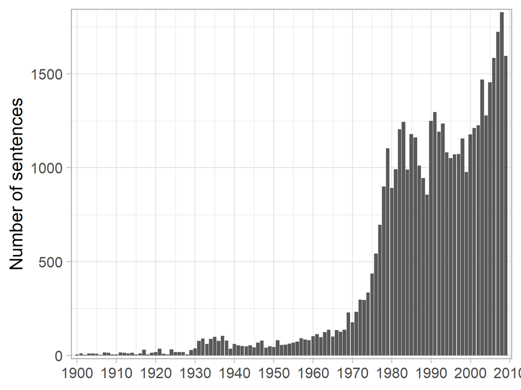

### Closest sentence from ‘rational’ and ‘rationality’ of the backbone community

| Sentence | Title | Year | Journal | Authors | Words Similarity |
| --- | --- | --- | --- | --- | --- |
| However, we can anticipate that, in our opinion, the results of this paper provide some support for those who are critical toward the rational expectations characterization of rational behavior. | [Can people learn rational expectations? - An ‘ecological’ approach](https://doi.org/10.1007/BF01200836) | 1994 | Journal of Evolutionary Economics | Sacco P. | 0.839 |
| A rational agent draws on an information set larger than historical prices, and expectations are rational if they depend upon the same things that economic theory suggests determines the variable. | [A Semi-Strong Form Evaluation of the Efficiency of the Hog Futures Market](https://http://www.jstor.org/stable/1239434) | 1979 | American Journal of Agricultural Economics | Raymond M. Leuthold, Peter A. Hartmann | 0.828 |
| The requirement that agents’ expectations be rational, i.e. | Variations in economic uncertainty and risk premiums on capital assets | 1993 | European Economic Review | Gennotte G. | 0.826 |
| As an alternative to rational expectations bounded rationality models have been proposed. | Consistent expectations equilibria and learning in a stock market | 2002 | Journal of Economic Dynamics and Control | Sögner L. | 0.824 |
| Expectations about a variable are said to be rational if they depend, in the proper way, on the same things that economic theory says actually determine that variable. | [Rational Expectations and the Dynamics of Hyperinflation](https://http://www.jstor.org/stable/2525924) | 1973 | International Economic Review | Thomas J. Sargent, Neil Wallace | 0.822 |
| Instead of starting off by assuming that agents have rational expectations, we merely see rational expectations as a possible long run outcome of a learning process of boundedly rational agents using … | [Informational differences and learning in an asset market with boundedly rational agents](https://doi.org/10.1016/j.jedc.2007.06.003) | 2008 | Journal of Economic Dynamics and Control | Diks C. | 0.822 |
| solution and thus being eductively stable.1 His analysis revealed that not every rational expectations equilibrium can be justified using the concept of rationalizability. | [Are Rational Expectations Equilibria with Private Information Eductively Stable?](https://http://www.jstor.org/stable/41795156) | 2004 | Journal of Economics | Maik Heinemann | 0.820 |
| The term “rational expectations” (discussed earlier) refers to rational-choice models with the additional assumption that agents form their expectations and beliefs by optimally processing information… | [Rational-choice hermeneutics](https://doi.org/10.1016/j.jebo.2003.07.006) | 2004 | Journal of Economic Behavior and Organization | Koppl R. | 0.815 |
| While some of these authors have avoided general conclusions, others have suggested that this characteristic non-uniqueness constitutes a serious weakness for the rational expectations hyy:!othesis.’ | On non-uniqueness in rational expectations models. An attempt at perspective | 1983 | Journal of Monetary Economics | McCallum B. | 0.815 |
| This paper emphasizes the point that supposing agents are more rational, in the sense that they take additional aspects of their inference problem into account, may preclude convergence to rational ex… | Time-varying parameters and nonconvergence to rational expectations under least squares learning | 1992 | Economics Letters | Bullard J. | 0.814 |
| Thus expectations are assumed to be “rational,” albeit in a limited sense. | [More on the Speed of Adjustment in Inventory Models](https://http://www.jstor.org/stable/1992386) | 1986 | Journal of Money, Credit and Banking | Alan S. Blinder | 0.814 |
| A rational agent would therefore reject rational expectations (Davidson, 1982- | [What’s so Rational about Rational Expectations? Hyperrationality and the Logical Limits to Neoclassicism](https://http://www.jstor.org/stable/4538571) | 1997 | Journal of Post Keynesian Economics | Steven Shulman | 0.813 |
| Rational expectations (pˆr ) are based on the correct market model accounting for the optimizing choices of all agents involved. | [Energy conservation, expectations and uncertainty](https://doi.org/10.1016/j.eneco.2007.12.001) | 2008 | Energy Economics | Wirl F. | 0.813 |
| We take as a measure of bounded rationality the difference between the agents’ subjective expectation and the actual expected value of the variable given their information. | [Structural stability implies robustness to bounded rationality](https://doi.org/10.1006/jeth.2000.2784) | 2001 | Journal of Economic Theory | Anderlini L. | 0.812 |
| This result casts some doubt on the validity of the restrictions imposed by the assumption of rational expectations and therefore on the assumption of rational expectations itself. | [Unanticipated Money Growth, Output and Unemployment in West Germany, 1964-1981](https://http://www.jstor.org/stable/40439226) | 1984 | Weltwirtschaftliches Archiv | David Demery, Nigel W. Duck, Simon W. Musgrave | 0.812 |
| We have now analyzed the two polar cases of pure rational expectations and pure limited rationality. | [Rational Expectations and the Limits of Rationality: An Analysis of Heterogeneity](https://http://www.jstor.org/stable/1814803) | 1985 | The American Economic Review | John Haltiwanger, Michael Waldman | 0.812 |
| Note that, unlike the literature on bounded rationality which investigates the reasons for not following a full rational expectations’ solutions, we examine the effects here. | [Asymmetric information and rational expectations: When is it right to be “wrong”?](https://doi.org/10.1016/j.jimonfin.2008.07.001) | 2008 | Journal of International Money and Finance | Demertzis M. | 0.811 |
| If one assumes that agents have rational expectations, a stricter condition is being imposed, namely that beliefs are correct2. | [Floating Exchange Rates versus a Monetary Union under Rational Beliefs: The Role of Endogenous Uncertainty](https://http://www.jstor.org/stable/25055627) | 2003 | Economic Theory | Carsten Krabbe Nielsen | 0.811 |
| This is true because a rational expectation must include within it the postulate that the decision maker will behave according to some underlying theory [8]; yet no uniquely best theory here exists fo… | [Rational Expectations of Government Policy: An Application of Newcomb’s Problem](https://http://www.jstor.org/stable/1058483) | 1982 | Southern Economic Journal | Roman Frydman, Gerald P. O’Driscoll, Jr., Andrew Schotter | 0.811 |
| We begin our analysis by examining whether expectations are formed rationally. | [Two currencies, one model? Evidence from the Wall Street Journal forecast poll](https://doi.org/10.1016/j.intfin.2008.08.003) | 2009 | Journal of International Financial Markets Institutions and Money | Frenkel M. | 0.810 |
| The bounded rationality literature argues that very few agents have the capability, regardless of cost or mean squared error, to form rational expectations. | [The Theory of Rationally Heterogeneous Expectations: Evidence from Survey Data on Inflation Expectations](https://http://www.jstor.org/stable/3590297) | 2004 | The Economic Journal | William A. Branch | 0.810 |
| Alternative formulations, such as the assumption that expectations are naive or generated by some other simple autoregressive form, are inadequate for similar reasons The Rational Expectations Hypothe… | [Rational Expectations in Agricultural Economics Research and Policy Analysis](https://http://www.jstor.org/stable/1241132) | 1982 | American Journal of Agricultural Economics | Brian S. Fisher | 0.810 |

### Closest sentences of the backbone community’s centroid

| Sentence | Title | Year | Journal | Authors | Similarity to Backbone Centroid |
| --- | --- | --- | --- | --- | --- |
| In this model the hypothesis of rational expectations is retained. | [Price Inertia and Nominal Aggregate Demand in Major European Countries](https://http://www.jstor.org/stable/40723885) | 1989 | Recherches Économiques de Louvain / Louvain Economic Review | Christian BORDES, Michael DRISCOLL, Marc-Olivier STRAUSS-KAHN | 0.913 |
| Expectations are assumed to be Rational in the sense of Muth (1961), that is expectations are consistent with the full model. | [Could Lloyd George have Done It? The Pledge Re-Examined](https://http://www.jstor.org/stable/2663335) | 1989 | Oxford Economic Papers | K. G. P. Matthews | 0.899 |
| We would like to comment on the form of the rational expectations hypotheses we can handle in this framework. | Testing exact rational expectations in cointegrated vector autoregressive models | 1999 | Journal of Econometrics | Johansen S. | 0.896 |
| The formulation of expectations is assumed to be rational in the sense of . | Taxation, rational expectations, and the neutrality of money | 1984 | Journal of Macroeconomics | Cantc V.A. | 0.896 |
| Expectations are assumed to be ‘rational’. | Exchange intervention policy in a multiple country world | 1982 | Journal of International Economics | Canzoneri M. | 0.890 |
| V. Rational Expectations We now consider the case where expectations are formed rationally. | [On the Implications of Monetary Rules in a Stochastic Framework](https://http://www.jstor.org/stable/40438458) | 1980 | Weltwirtschaftliches Archiv | D. A. Peel | 0.887 |
| of rational expectations. | Project impact analysis as an optimal control problem | 1983 | Journal of Economic Dynamics and Control | Anandalingam G. | 0.884 |
| Thus, the characterization of rational expectations used here does not rule out nonlinear and other expectations mechanisms. | [Is the Distinction between Anticipated and Unanticipated Money Growth Relevant in Explaining Aggregate Output?](https://http://www.jstor.org/stable/1814540) | 1987 | The American Economic Review | Roman Frydman, Peter Rappoport | 0.883 |
| INTRODUCTION A popular criticism of rational expectations models of exchange rate determination is that recent movements in exchange rates have been too volatile to be justified by movements in “funda… | [Rational Expectations and the Volatility of Floating Exchange Rates](https://http://www.jstor.org/stable/2648797) | 1983 | International Economic Review | Richard A. Meese, Kenneth J. Singleton | 0.883 |
| Expectations are assumed to be formed rationally. | The currency denomination of long-term debt in the Canadian corporate sector: An empirical analysis | 1988 | Journal of International Money and Finance | Johnson D. | 0.882 |
| Expectations are assumed to be formed rationally. | A new classical econometric model of the world economy | 1986 | Economic Modelling | Minford P. | 0.882 |
| Expectations are assumed to be formed rationally. | [Adjustment Costs and Rational Expectations: An Application to a Tobacco Export Model](https://http://www.jstor.org/stable/1241302) | 1987 | American Journal of Agricultural Economics | George P. Zanias | 0.882 |
| This result casts some doubt on the validity of the restrictions imposed by the assumption of rational expectations and therefore on the assumption of rational expectations itself. | [Unanticipated Money Growth, Output and Unemployment in West Germany, 1964-1981](https://http://www.jstor.org/stable/40439226) | 1984 | Weltwirtschaftliches Archiv | David Demery, Nigel W. Duck, Simon W. Musgrave | 0.882 |
| t tThe possible implications for “rational expectations” models are obvious. | [Forecasts and U. S. Monetary Policy, 1974-78: The Role of Openness: Note](https://http://www.jstor.org/stable/1992265) | 1988 | Journal of Money, Credit and Banking | Nicholas Karamouzis, Raymond E. Lombra | 0.881 |
| This approach could also be useful in models containing rational expectations. | [Semiparametric Econometrics: A Survey](https://http://www.jstor.org/stable/2096563) | 1988 | Journal of Applied Econometrics | P. M. Robinson | 0.879 |

### Closest sentences of each HDBSCAN cluster’s centroid composing the backbone community

| Sentence | Title | Year | Journal | Authors | Similarity to HDSBSCAN Centroid |
| --- | --- | --- | --- | --- | --- |
| It has been insisted that the value of money is importantly influenced by its quantity, but nothing in the argument was intended to deny the counter-proposition which to-day is so frequently made that… | [Credit and the Value of Money](https://www.jstor.org/stable/10.2307/2999925) | 1905 | Publications of the American Economic Association | A. Piatt Andrew | 0.848 |
| The confusion which has so often attended the discussion of the principles which determine the value of money has been due in part to the fact that, as money is the measure of value of other things, t… | [What Determines the Value of Money](https://http://www.jstor.org/stable/1882416) | 1904 | The Quarterly Journal of Economics | Charles A. Conant | 0.844 |
| On the other hand, if this most essential step on the way to a rational monetary system should be taken, if the free coining of gold, like that of silver, should cease, and eventually the banknote its… | [The Influence of the Rate of Interest on Prices](https://http://www.jstor.org/stable/2220665) | 1907 | The Economic Journal | Knut Wicksell | 0.844 |
| And the eminent price of money must necessarily follow the-natural price of the metals; for it is unreasonable that a quantity of silver, considered as a comluodity, should bear a very different price… | [The Theory of Value before Adam Smith](https://www.jstor.org/stable/10.2307/2485740) | 1901 | Publications of the American Economic Association | Hannah Robie Sewall | 0.824 |
| All that is involved in this doctrine can be stated in the words of so distinguished a gold monometallist as Giffen; to wit, “The quantity of money is a material factor in determining the value of mon… | [The Ricardian Theory of Gold Movements and Professor Laughlin’s Views of Money](https://http://www.jstor.org/stable/1882786) | 1904 | The Quarterly Journal of Economics | A. C. Whitaker | 0.813 |
| The idea that we can have a stable unit of money leaves out of sight that the bounty of Nature varies, that man’s industrial activities do not exactly coincide with human requirements, that the vagari… | [Consideration of the Proposal to Stabilize the Unit of Money](https://http://www.jstor.org/stable/1823606) | 1919 | The American Economic Review | G. H. Knibbs | 0.808 |
| This difference between money and other commodities ought to make it apparent that the value of money cannot be accounted for by precisely the same phase of the law of supply and demand as will accoun… | [The Concept of an Economic Quantity](https://http://www.jstor.org/stable/1884906) | 1907 | The Quarterly Journal of Economics | T. N. Carver | 0.799 |
| Money also he claitns does not derive its purchasing power from the natural qualities of the metals of which it is composed, but from the agreemellt of people to employ thetn as instruments of exchang… | [The Theory of Value before Adam Smith](https://www.jstor.org/stable/10.2307/2485740) | 1901 | Publications of the American Economic Association | Hannah Robie Sewall | 0.799 |
| The obvious importance of this consideration to the discussion of the quantity theory of money will at once appear, and it leads to some of the following considerations. | [The Concept of an Economic Quantity](https://http://www.jstor.org/stable/1884906) | 1907 | The Quarterly Journal of Economics | T. N. Carver | 0.797 |
| 553 it is proposed to show here that by changes in the volume of money there are set in operation, in the very nature of the case, other influences which make it impossible that other things should re… | [What Determines the Value of Money](https://http://www.jstor.org/stable/1882416) | 1904 | The Quarterly Journal of Economics | Charles A. Conant | 0.794 |

| Sentence | Title | Year | Journal | Authors | Similarity to HDSBSCAN Centroid |
| --- | --- | --- | --- | --- | --- |
| These remarks upon the metaphysics of monetary theory, and upon the nature of the “truth” attainable in that field, have been prompted by a single paragraph in this little book by a writer whose own d… | [Hawtrey’s the Gold Standard in Theory and Practice](https://http://www.jstor.org/stable/1885369) | 1927 | The Quarterly Journal of Economics | Arthur W. Marget | 0.828 |
| It is consequently somewhat disconcerting to be told by the best-known English monetary theorist 1 that the doctrine of limitation of currency is obsolete, and has been replaced by the doctrine that d… | [Limitation of Currency or Limitation of Credit?](https://http://www.jstor.org/stable/2222618) | 1924 | The Economic Journal | Edwin Cannan | 0.823 |
| When money is conceived as a valuable thing employed as a medium of exchange, the quantity of money is not increased by a mere multiplication of the evidences of debt without an increase of the resour… | [The Quantity Theory Scrutinized](https://http://www.jstor.org/stable/1822583) | 1921 | Journal of Political Economy | Hugo Bilgram | 0.816 |
| Under this general head of “metaphysical” themes in monetary theory are to be placed such topics as the definition of money, discussions of the ” essential nature” of money, the “functions” of money, … | [Hawtrey’s the Gold Standard in Theory and Practice](https://http://www.jstor.org/stable/1885369) | 1927 | The Quarterly Journal of Economics | Arthur W. Marget | 0.811 |
| In practical life recognition of the truth of the proposition is of enormous importance, because it explains the fact that private persons and the banks in which private persons pool their immediate r… | [Limitation of Currency or Limitation of Credit?](https://http://www.jstor.org/stable/2222618) | 1924 | The Economic Journal | Edwin Cannan | 0.803 |
| “This is the famous Quantity Theory of Money. | [Recent Theories of Currency Reform](https://http://www.jstor.org/stable/2548167) | 1924 | Economica | T. E. Gregory | 0.799 |
| There is a branch of the theory of money which might be called loosely, for want of a better name, the metaphysics of monetary theory.4 The Germans, as might have been expected in view of their tradit… | [Hawtrey’s the Gold Standard in Theory and Practice](https://http://www.jstor.org/stable/1885369) | 1927 | The Quarterly Journal of Economics | Arthur W. Marget | 0.788 |
| We continue, of course, to speak of the value of money, but the catallactic meaning we give to this expression, while somewhat abstract, is neither abstruse nor vague. | [A Revaluation of Traditional Economic Theory](https://http://www.jstor.org/stable/1807500) | 1921 | The American Economic Review | Carl E. Parry | 0.787 |
| It is easy to argue that any attempt even to consider the problems which are suggested by what has been called the “metaphysical” branch of monetary theory is to be rejected once for all as fruitless,… | [Hawtrey’s the Gold Standard in Theory and Practice](https://http://www.jstor.org/stable/1885369) | 1927 | The Quarterly Journal of Economics | Arthur W. Marget | 0.787 |
| We have here to deal with a deduction from the quantity theory of money in its specific form which claims an exact inverse proportionality between the quantity of money and the purchasing power. | [The Valuation Theory of Exchange](https://http://www.jstor.org/stable/2222683) | 1925 | The Economic Journal | Wilhelm Keilhau | 0.776 |

| Sentence | Title | Year | Journal | Authors | Similarity to HDSBSCAN Centroid |
| --- | --- | --- | --- | --- | --- |
| Even if it may be grasped, it is then necessary to take as the premise that money itself does not contain this ” something,” in order to consider the value of money in the sense of general purchasing | [THE SUBJECTIVE THEORY OF VALUE AND THEORIES OF THE VALUE OF MONEY](https://www.jstor.org/stable/10.2307/43217264) | 1931 | Kyoto University Economic Review | Kei Shibata | 0.824 |
| So that on the one hand we have the more or less explicit idea that to have the right definition of money is to possess the key to the ” right ” monetary policy, while on the other hand controversy on… | [On the Subject-Matter and Method of Economic Science](https://http://www.jstor.org/stable/2548905) | 1933 | Economica | Felix Kaufmann | 0.817 |
| For, when the point at issue is whether - in the study of the mechanism decisive of the value of money, in which it has been made clear that in all the objects of exchange to be admitted into this mec… | [THE SUBJECTIVE THEORY OF VALUE AND THEORIES OF THE VALUE OF MONEY](https://www.jstor.org/stable/10.2307/43217264) | 1931 | Kyoto University Economic Review | Kei Shibata | 0.816 |
| Nevertheless, there remain very serious grounds for asking, first of all, whether the analysis under discussion does not itself ignore some of the considerations which we found it necessary to adduce … | [The Relation between the Velocity of Circulation of Money and the “Velocity of Circulation of Goods:” II](https://http://www.jstor.org/stable/1822850) | 1932 | Journal of Political Economy | Arthur W. Marget | 0.813 |
| For, whereas the subjective value of money (not the function) must be regarded as unalterable, if such necessity is to be justified, our basic experience does not approve | [THE SUBJECTIVE THEORY OF VALUE AND THEORIES OF THE VALUE OF MONEY](https://www.jstor.org/stable/10.2307/43217264) | 1931 | Kyoto University Economic Review | Kei Shibata | 0.811 |
| Our first problem, therefore, is to meet on its own ground the rigid form of the argument alleging the necessity for a precise equivalence in the movements of the velocity of circulation of money and … | [The Relation Between the Velocity of Circulation of Money and the “Velocity of Circulation of Goods”](https://http://www.jstor.org/stable/1824154) | 1932 | Journal of Political Economy | Arthur W. Marget | 0.808 |
| The existence of money and the possibility of changes in its total amount (as well as changes in the amounts held by particular individuals or desired to be held by them) was thus supposed to overthro… | [The Relation of Wage Policies and Price Policies](https://http://www.jstor.org/stable/1806964) | 1939 | The American Economic Review | A. P. Lerner | 0.807 |
| In this way quantity and anti-quantity theorists had many a confused melee which might have been avoided if they had o-nly seen that it did not matter two straws whether they said that the value of mo… | [The Future of Gold in Relation to Demand](https://http://www.jstor.org/stable/2224761) | 1934 | The Economic Journal | Edwin Cannan | 0.804 |
| Just as, in the Theory of Value, the supply-and-demand mechanism is used to analyse the forces determining the value of a single commodity, so in the traditional Theory of Money the supply-and-demand … | [The Theory of Money and the Analysis of Output](https://http://www.jstor.org/stable/2967434) | 1933 | The Review of Economic Studies | Joan Robinson | 0.803 |
| First of all, it should be noted that the quantity theory of money may take either of the following two forms : (1) the a priori or deductive or speculative quantity theory which contends that the var… | [AN EXAMINATION OF PROFESSOR CASSEL’S QUANTITY THEORY OF MONEY](https://www.jstor.org/stable/10.2307/43217271) | 1932 | Kyoto University Economic Review | Kei Shibata | 0.803 |

| Sentence | Title | Year | Journal | Authors | Similarity to HDSBSCAN Centroid |
| --- | --- | --- | --- | --- | --- |
| The function of some kinds of money as a reserve for others is obviously not a function of money in general and it may as well here be said that, in the writer’s opinion, the social interest would be … | [The Primary Functions of Money and their Consummation in Monetary Policy](https://http://www.jstor.org/stable/1814476) | 1940 | The American Economic Review | Frank D. Graham | 0.826 |
| Since this conclusion itself seems necessary to the successful integration of the general theories of money and price and to putting both bodies of doctrine “on the same side of the moon,”2 the object… | [Some Fundamentals in Liquidity Theory](https://http://www.jstor.org/stable/1884572) | 1945 | The Quarterly Journal of Economics | M. Bronfenbrenner | 0.820 |
| At any rate, where the quantity theory of money occuppies an important position, it is only too natural that monetary quantity should be held in great importance, forming the issue of arguments. ” | [ON THE MONETARY IDEAS AS SEEN IN THE RECORDS OF ECONOMIC AND FINANCE IN THE SUNG HISTORY](https://www.jstor.org/stable/10.2307/43216917) | 1942 | Kyoto University Economic Review | Fumio Hozumi | 0.817 |
| This does not mean a belief that the value of money depends solely on its quantity, nor that a permanently fixed volume of money would result in a stable value of money. | [Monetary Policy in the United States in World War II](https://http://www.jstor.org/stable/3484132) | 1945 | The American Journal of Economics and Sociology | Clark Warburton | 0.806 |
| What is usually desired is not a mere change in what has been defined as money, but rather a change in what money is supposed to do, but which this money will not do. | [The Supply of Bank Money in England and Wales, 1920-1938](https://http://www.jstor.org/stable/2663455) | 1941 | Oxford Economic Papers | R. M. Goodwin | 0.805 |
| The two characteristics of money, viz., the facts that its utility depends on prices and that it is not consumed where it is demanded, have proved not to present insuperable difficulties. | [The Consumer’s Demand for Money](https://http://www.jstor.org/stable/1909263) | 1943 | Econometrica | C. E. V. Leser | 0.804 |
| I am convinced that an appropriate type of money will either maintain full economic activity, without alterations in the value of the monetary unit, or that this cannot be done by any monetary manipul… | [The Primary Functions of Money and their Consummation in Monetary Policy](https://http://www.jstor.org/stable/1814476) | 1940 | The American Economic Review | Frank D. Graham | 0.798 |
| But it should be noticed that what freedom there is results from variations in idle money, which is of no importance for the functional aspect of money, i.e. | [The Supply of Bank Money in England and Wales, 1920-1938](https://http://www.jstor.org/stable/2663455) | 1941 | Oxford Economic Papers | R. M. Goodwin | 0.788 |
| He generally ignores the existence of the procedures by which money can be created, and yet, in order that his desire for cash holdings may be satisfied, it is necessary that he be able by his decisio… | [The Fallacies of Lord Keynes General Theory.](https://http://www.jstor.org/stable/1879560) | 1947 | The Quarterly Journal of Economics | Jacques Rueff | 0.785 |
| Money as a storehouse of value, on the other hand, serves (on the whole less efficiently than many other goods) as insurance against loss on inventories, arising from the practical certainty, in certa… | [The Primary Functions of Money and their Consummation in Monetary Policy](https://http://www.jstor.org/stable/1814476) | 1940 | The American Economic Review | Frank D. Graham | 0.781 |

#### Top terms 4_0_1900-1919: gold, silver, quantity_theory, currency, money (1950-1959)

| Sentence | Title | Year | Journal | Authors | Similarity to HDSBSCAN Centroid |
| --- | --- | --- | --- | --- | --- |
| If a clearly understood policy of increasing the quantity of money at a reasonable rate were to be established these reasons for variation in monetary velocity would disappear, and with them the usual… | [How Much Variation in the Quantity of Money Is Needed?](https://http://www.jstor.org/stable/1054040) | 1952 | Southern Economic Journal | Clark Warburton | 0.812 |
| The real issue, then, is not the existence of vested interests which will compel inflation but the adequacy of unconditional ex ante compensatory policies.9 V Let us now consider the relation of monet… | [Keynesianism and Inflation](https://http://www.jstor.org/stable/1826438) | 1951 | Journal of Political Economy | Walter A. Morton | 0.794 |
| Nevertheless, most economists will admit, on consideration, that those economic phenomena bear no definite relationship to the amount of money in the above mentioned sense, and that they could not be … | [The Concept of Money](https://http://www.jstor.org/stable/40433452) | 1954 | Weltwirtschaftliches Archiv | Jørgen Pedersen | 0.794 |
| But the prospects of controlling price movements flexibly by monetary policy appear much poorer than would be inferred from the view which ascribes causal primacy to changes in the quantity of money; … | [Economic Growth and The Price Level](https://http://www.jstor.org/stable/2227439) | 1955 | The Economic Journal | E. H. Phelps Brown, S. A. Ozga | 0.784 |
| What has been said above is not to be construed as disparagement of monetary theory, though it is critical of the apotheosis of particular doctrines or dogmas. | [Relation of Money to Economic Growth](https://http://www.jstor.org/stable/1910672) | 1956 | The American Economic Review | Charles R. Whittlesey | 0.781 |
| Let us admit more charitably that the classical economists were assuming that some reason for holding money existed, and therefore that it had utility, and that since it could have no utility in a sta… | [Walras, Leontief, and the Interdependence of Economic Activities: Reply](https://http://www.jstor.org/stable/1882000) | 1955 | The Quarterly Journal of Economics | Robert E. Kuenne | 0.772 |
| Secondly, it might be asked whether, in the assumptions made about money, the Quantity Theory of Money does not rear its barely disguised head? | [Monetary Analysis of Income Formation and Payments Problems](https://www.jstor.org/stable/10.2307/3866128) | 1957 | Staff Papers (International Monetary Fund) | J. J. Polak | 0.772 |
| In our efforts to consolidate monetary theory with the theory of saving and investment, we have shown some uneasiness over the restrictions of conventional monetary thought. | [Monetary Policy and the Structure of Debt](https://http://www.jstor.org/stable/1818359) | 1954 | The American Economic Review | E. S. Shaw | 0.771 |
| The fact that the rise in the volume of money cannot account for the past, and a restraint of a further increase cannot vouchsafe the end of a future, upward movement of prices has now, somewhat reluc… | [Productivity and Inflation](https://http://www.jstor.org/stable/2662094) | 1958 | Oxford Economic Papers | T. Balogh | 0.771 |
| In addition an efficient monetary system is not a creation of nature; on the contrary, apart from a very primitive state of human society money has always been and will always be subject to control or… | [The Concept of Money](https://http://www.jstor.org/stable/40433452) | 1954 | Weltwirtschaftliches Archiv | Jørgen Pedersen | 0.771 |

#### Top terms 4_0_1900-1919: gold, silver, quantity_theory, currency, money (1960-1969)

| Sentence | Title | Year | Journal | Authors | Similarity to HDSBSCAN Centroid |
| --- | --- | --- | --- | --- | --- |
| It is possible to take a simpler but not outright contradictory approach: to observe that it is convenient to hold assets in order to bridge the gap between the receiving and making of payments and to… | [The Definition of Money: Theoretical and Empirical Problems](https://http://www.jstor.org/stable/1991204) | 1969 | Journal of Money, Credit and Banking | David Laidler | 0.821 |
| The great emphasis on money substitutes in the new view discussions certainly builds up an expectation that the demand for money is not a stable function, and that the equilibrium quantity of real bal… | [Keynesian Monetary Theories, Stabilization Policy, and the Recent Inflation](https://http://www.jstor.org/stable/1991212) | 1969 | Journal of Money, Credit and Banking | David Fand | 0.811 |
| Thus, just because this analysis agrees with Friedman’s on the importance of money and on the stability of the demand for money it leads to a categorical rejection of the notion of entrusting the cont… | [The Monetary Mechanism and Its Interaction with Real Phenomena](https://http://www.jstor.org/stable/1927150) | 1963 | The Review of Economics and Statistics | Franco Modigliani | 0.809 |
| In some cases, it may be the first interpretation which applies,48 whereas at other times the second may provide the explanation of what constitutes the motive force.49 The theory proposed here makes … | [A Restatement of the Quantity Theory of Money](https://http://www.jstor.org/stable/1815300) | 1966 | The American Economic Review | Maurice Allais | 0.804 |
| If this dichotomy between monetary and real quantities is taken seriously, it seems to imply that the real money supply, corrected for price-level changes, cannot be altered significantly by monetary … | [Monetary Rules: A New Look](https://http://www.jstor.org/stable/724789) | 1965 | The Journal of Law & Economics | M. Bronfenbrenner | 0.797 |
| One is hardly going to be able to settle this issue if it is prejudged by defining money in such a way as to be inherently incompatible with non-transactions approaches to monetary theory.4 There is m… | [The Definition of Money: Theoretical and Empirical Problems](https://http://www.jstor.org/stable/1991204) | 1969 | Journal of Money, Credit and Banking | David Laidler | 0.796 |
| On the legitimate assumption that the exceptional hoarding qualities of money originate in its exceptional liquidity, one can easily detect a fatal theoretical weakness of the entire proposition, for … | [The Four Approaches To Monetary Reform: A Critique](https://http://www.jstor.org/stable/41796394) | 1962 | Zeitschrift für Nationalökonomie / Journal of Economics | Walter P. Egle | 0.796 |
| and active) money balances that varies inversely with interest rates, but this is insufficient to justify old orthodoxy unless it can be assumed that significant portions of the demand are sensitive t… | [Financial Theory and Control of Bank Deposits](https://http://www.jstor.org/stable/2662371) | 1968 | Oxford Economic Papers | A. B. Cramp | 0.792 |
| The proposition that there can be a demand for a “partial money” which is not a Store of Value is seriously defective.3 The crucial role of time in explaining the existence of money has long been reco… | [Professor Hicks and the Foundations of Monetary Economics](https://http://www.jstor.org/stable/2551910) | 1969 | Economica | Laurence Harris | 0.788 |
| It is not enough simply to assert that once-for-all definitions of the money supply (especially those whose unchanging weights are each either zero or unity) are most unlikely, in the face of economic… | [Money as A Weighted Aggregate](https://http://www.jstor.org/stable/41796779) | 1964 | Zeitschrift für Nationalökonomie / Journal of Economics | Edward J. Kane | 0.787 |

| Sentence | Title | Year | Journal | Authors | Similarity to HDSBSCAN Centroid |
| --- | --- | --- | --- | --- | --- |
| Expectations about a variable are said to be rational if they depend, in the proper way, on the same things that economic theory says actually determine that variable. | [Rational Expectations and the Dynamics of Hyperinflation](https://http://www.jstor.org/stable/2525924) | 1973 | International Economic Review | Thomas J. Sargent, Neil Wallace | 0.866 |
| Our objective in this paper is to build on Muth’s basic concept by providing some insight into the processes by which the rational-expectations hypothesis can, in fact, be realized. | [Rational Expectations and Bayesian Analysis](https://http://www.jstor.org/stable/1829843) | 1974 | Journal of Political Economy | Richard M. Cyert, Morris H. DeGroot | 0.864 |
| Some theoretical justification for this assumption has been given by Brock [1]; 4A more general assumption would be “rational expectations,” allowing for the existence of uncertainty. | [A Model of Balance-of-Payments Crises](https://http://www.jstor.org/stable/1991793) | 1979 | Journal of Money, Credit and Banking | Paul Krugman | 0.858 |
| In this regard, it should be noted that the rational expectations hypothesis does not require that people’s expectations equal conditional mathematical expectations, only that they equal conditional m… | Rational expectations and the theory of economic policy | 1976 | Journal of Monetary Economics | Sargent T. | 0.857 |
| Rather, a model is built in which expectations are ‘rational.’ | Rational expectations and the dynamic structure of macroeconomic models. A critical review | 1978 | Journal of Monetary Economics | Shiller R. | 0.857 |
| Making the assumption that expectations are rational leads to two sorts of technical problems. | [Large Economies with Trading Uncertainty](https://http://www.jstor.org/stable/2297055) | 1979 | The Review of Economic Studies | Douglas Gale | 0.852 |
| However, as was first pointed out in Muth’s pioneering contribution [13], to claim that a model is fully consistent with rational behaviour it is not sufficient to show that the process of expectation… | [Inflation, Rational Expectations and the Term Structure of Interest Rates](https://http://www.jstor.org/stable/2552679) | 1973 | Economica | Franco Modigliani, Robert J. Shiller | 0.848 |
| rhe information a;aitability assumption of the rational expectations hypothesis imphcitly “It is crrtalnly plausible to suppose. | Optimal expectations and the extreme information assumptions of ‘rational expectations’ macromodels | 1979 | Journal of Monetary Economics | Friedman B. | 0.846 |
| On the other hand, the problems of rational expectations models we have discussed may be so important that a model which postulates an arbitrary expectations mechanism may actually perform better. | Rational expectations and the dynamic structure of macroeconomic models. A critical review | 1978 | Journal of Monetary Economics | Shiller R. | 0.844 |
| In this paper, it is assumed that expectations are formed rationally. | [The Role of Savings in Flow Demand for Money: Alternative Partial Adjustment Models (Le rôle de l’épargne dans la demande de monnaie en termes de flux: divers modêles d’ajustement partiel) (La funció… | 1978 | Staff Papers (International Monetary Fund) | Arturo Brillembourg | 0.844 |

| Sentence | Title | Year | Journal | Authors | Similarity to HDSBSCAN Centroid |
| --- | --- | --- | --- | --- | --- |
| It is assumed that the money market is always in equilibrium and the variables which appear in the demand function do not belong in the money supply function.1 If we focus on theories that emphasize t… | [An Annual Money Demand Function for Pakistan: Some Further Results](https://www.jstor.org/stable/10.2307/41258490) | 1979 | The Pakistan Development Review | I. U. Mangla | 0.839 |
| The existence of a stable demand for money does not discriminate between alternative monetary theories that assign more rather than less importance to the effect on interest rates and other relative p… | [Friedman’s Monetary Theory](https://http://www.jstor.org/stable/1830414) | 1972 | Journal of Political Economy | Karl Brunner, Allan H. Meltzer | 0.822 |
| The recognition “that money matters” and that monetary policy can exert a considerable influence on a number of policy objectives should, however, not close one’s eyes to the limitations to which even… | [On the Effectiveness of Monetary Policy: The Experience of the Netherlands in the Years 1954-69](https://http://www.jstor.org/stable/1991040) | 1972 | Journal of Money, Credit and Banking | M. W. Holtrop | 0.817 |
| ‘The stability of the money demand function, together with a capacity on the part of the monetary authority to influence closely the stock of assets corresponding to the theoretical concept of money e… | [The Demand for Money in Canada: Some Additional Evidence](https://http://www.jstor.org/stable/134472) | 1977 | The Canadian Journal of Economics / Revue canadienne d’Economique | David K. Foot | 0.814 |
| If monetary theory provides no rationale for the holding of money, many of the conclusions of currently accepted monetary theory, which derive from treating money like any other good or factor in the … | [The Roles of Money in an Economy and the Optimum Quantity of Money](https://http://www.jstor.org/stable/2552841) | 1971 | Economica | Morris Perlman | 0.811 |
| However, if as assumed throughout this paper the money stock can be set at exactly the desired level, then the money stock may as well be called an instrument of monetary policy rather than a proximat… | [Optimal Choice of Monetary Policy Instruments in a Simple Stochastic Macro Model](https://http://www.jstor.org/stable/1883009) | 1970 | The Quarterly Journal of Economics | William Poole | 0.809 |
| The second view holds that the quantity of money is important because a. it can be fairly accurately controlled by deliberate policy; b. changes in the quantity of money can produce substantial change… | [Bayesian Comparisons of Simple Macroeconomic Models](https://http://www.jstor.org/stable/1991295) | 1973 | Journal of Money, Credit and Banking | Martin S. Geisel | 0.807 |
| If we believe that the demand for money is a stable function around which there is very little variation, that the interest-elasticity of the demand for money is low, and that the direction of causati… | [Lessons for the Present from the Great Depression](https://http://www.jstor.org/stable/1817196) | 1976 | The American Economic Review | Peter Temin | 0.806 |
| Third, an attempt to increase the money supply holding the nominal supply of securities constant results in an offsetting loss of reserves and leads to no other changes no matter what the degree of su… | [Modeling the Interdependence of National Money and Capital Markets](https://http://www.jstor.org/stable/1815903) | 1977 | The American Economic Review | Dale W. Henderson | 0.798 |
| As time and understanding of both theory and the world of reality progressed, however, the interest of monetary theorists shifted from demonstrating the neutrality of money to investigating the condit… | [Keynes’s General Theory: Revolution or War of Independence?](https://http://www.jstor.org/stable/134262) | 1976 | The Canadian Journal of Economics / Revue canadienne d’Economique | Harry G. Johnson | 0.795 |

| Sentence | Title | Year | Journal | Authors | Similarity to HDSBSCAN Centroid |
| --- | --- | --- | --- | --- | --- |
| It is hardly reasonable to suppose that the expected rate of inflation can be independent of the actual rate, so that the independence of the supply and demand sides of the market for money balances, … | [Inflation: A Survey](https://http://www.jstor.org/stable/2230624) | 1975 | The Economic Journal | David Laidler, Michael Parkin | 0.844 |
| In that case it would be irrational for economic agents to continue to form their price expectations adaptively.12 The rational expectations approach assumes that economic agents use all the informati… | [Price Expectations and the Interest Rate in an Open Economy: Germany, 1960-72](https://http://www.jstor.org/stable/1992019) | 1977 | Journal of Money, Credit and Banking | Manfred J. M. Neumann | 0.840 |
| Though we have given some consideration to the implications of a model relying on “rational expectations” this should not be construed as an indication that we view such a model per se as an adequate … | [Optimal Demand Policies against Stagflation](https://http://www.jstor.org/stable/40438706) | 1978 | Weltwirtschaftliches Archiv | Franco Modigliani, Lucas Papademos | 0.840 |
| SEVERAL ECONOMISTS2 have argued that if individuals correctly perceive the rate of inflation so that their expectations are “rational,” then deterministic models of money and economic growth are unsta… | [The Stability of Models of Money and Growth with Perfect Foresight](https://http://www.jstor.org/stable/1914034) | 1973 | Econometrica | Thomas J. Sargent, Neil Wallace | 0.837 |
| The ‘rational expectations’ approach to modelling the formation of inflation expectations challenges this assumption, and does so in such a way as to m&e the transmission mechanism even more awkward t… | Money and money income: An essay on the ‘transmission mechanism’ | 1978 | Journal of Monetary Economics | Laidler D. | 0.834 |
| The assumption of unresponsive expectations about the rate of inflation could be justified either as an extension of the rigid-price hypothesis to the second year or as a failure of rational expectati… | [Investment, Interest Rates, and the Effects of Stabilization Policies](https://http://www.jstor.org/stable/2534257) | 1977 | Brookings Papers on Economic Activity | Robert E. Hall, Christopher A. Sims, Franco Modigliani, William Brainard | 0.829 |
| Implicit in the arguments already presented above is the proposition that once they are built into the economy, inflationary expectations can only be removed by having excess supply in the system whic… | [The 1974 Report of the President’s Council of Economic Advisers: The Control of Inflation and the Future of the International Monetary System](https://http://www.jstor.org/stable/1813308) | 1974 | The American Economic Review | David Laidler | 0.826 |
| Such an extreme hypothesis about inflation is justified by the fact that more realistic models, though implying longer mathematical developments, lead to policies which are ” approximately” the same d… | [Business Strategies in Inflationary Economies](https://http://www.jstor.org/stable/2297066) | 1977 | The Review of Economic Studies | Jacques F. Lesourne, Raymond Leban | 0.821 |
| It is one thing to expect the inflation rate to behave in a particular way, and quite another to act upon that expectation and hence anticipate the behavior of the inflation rate. | Money and money income: An essay on the ‘transmission mechanism’ | 1978 | Journal of Monetary Economics | Laidler D. | 0.819 |
| If rational agents use information about the monetary standard when estimating the anticipated rate of inflation, changes in the stock of money should not have the same effect on maintained inflation … | [Anticipated Inflation and Unanticipated Price Change: A Test of the Price-Specie Flow Theory and the Phillips Curve](https://http://www.jstor.org/stable/1992018) | 1977 | Journal of Money, Credit and Banking | Allan H. Meltzer | 0.814 |

| Sentence | Title | Year | Journal | Authors | Similarity to HDSBSCAN Centroid |
| --- | --- | --- | --- | --- | --- |
| In this model the hypothesis of rational expectations is retained. | [Price Inertia and Nominal Aggregate Demand in Major European Countries](https://http://www.jstor.org/stable/40723885) | 1989 | Recherches Économiques de Louvain / Louvain Economic Review | Christian BORDES, Michael DRISCOLL, Marc-Olivier STRAUSS-KAHN | 0.913 |
| Expectations are assumed to be Rational in the sense of Muth (1961), that is expectations are consistent with the full model. | [Could Lloyd George have Done It? The Pledge Re-Examined](https://http://www.jstor.org/stable/2663335) | 1989 | Oxford Economic Papers | K. G. P. Matthews | 0.899 |
| The formulation of expectations is assumed to be rational in the sense of . | Taxation, rational expectations, and the neutrality of money | 1984 | Journal of Macroeconomics | Cantc V.A. | 0.896 |
| Expectations are assumed to be ‘rational’. | Exchange intervention policy in a multiple country world | 1982 | Journal of International Economics | Canzoneri M. | 0.890 |
| V. Rational Expectations We now consider the case where expectations are formed rationally. | [On the Implications of Monetary Rules in a Stochastic Framework](https://http://www.jstor.org/stable/40438458) | 1980 | Weltwirtschaftliches Archiv | D. A. Peel | 0.887 |
| of rational expectations. | Project impact analysis as an optimal control problem | 1983 | Journal of Economic Dynamics and Control | Anandalingam G. | 0.884 |
| Thus, the characterization of rational expectations used here does not rule out nonlinear and other expectations mechanisms. | [Is the Distinction between Anticipated and Unanticipated Money Growth Relevant in Explaining Aggregate Output?](https://http://www.jstor.org/stable/1814540) | 1987 | The American Economic Review | Roman Frydman, Peter Rappoport | 0.883 |
| Expectations are assumed to be formed rationally. | The currency denomination of long-term debt in the Canadian corporate sector: An empirical analysis | 1988 | Journal of International Money and Finance | Johnson D. | 0.882 |
| Expectations are assumed to be formed rationally. | A new classical econometric model of the world economy | 1986 | Economic Modelling | Minford P. | 0.882 |
| Expectations are assumed to be formed rationally. | [Adjustment Costs and Rational Expectations: An Application to a Tobacco Export Model](https://http://www.jstor.org/stable/1241302) | 1987 | American Journal of Agricultural Economics | George P. Zanias | 0.882 |

| Sentence | Title | Year | Journal | Authors | Similarity to HDSBSCAN Centroid |
| --- | --- | --- | --- | --- | --- |
| We first make an assumption about the properties of individual forecasts which amounts to assuming that forecasters are rational except for a possible additive bias. | [Optimal Aggregation of Money Supply Forecasts: Accuracy, Profitability and Market Efficiency](https://http://www.jstor.org/stable/2328077) | 1983 | The Journal of Finance | Stephen Figlewski, Thomas Urich | 0.876 |
| While in some cases forecasts may be described as rational, in many cases forecasts are more consistent with adaptive or extrapolative expectation functions for a review of relevant studies). | The effect of two trading institutions on price expectations and the stability of supply-response lag markets | 1989 | Journal of Economic Psychology | Johnson M. | 0.871 |
| Forecasts are considered to be informationally efficient if they are consonant with some previously specified property of rational expectations forecasts. | [The Informational Efficiency of Econometric Model Forecasts](https://http://www.jstor.org/stable/1928443) | 1985 | The Review of Economics and Statistics | Allen N. Berger, Spencer D. Krane | 0.867 |
| Conclusions We study a property, called consistency, which all rational forecasts have, but which itself does not require rationality. | On the consistency of short-run and long-run exchange rate expectations | 1989 | Journal of International Money and Finance | Froot K. | 0.864 |
| B. Complete-Optimal Forecasts: The Rational Expectations Hypothesis More recent contributions to expectations theory2 emphasize two important aspects of forecast formation: (a) the completeness of the… | [The Expectation Formation Behavior of the Inventory-Holding Firm](https://http://www.jstor.org/stable/25603538) | 1982 | The American Economist | Sherry S. Atkinson | 0.859 |
| A series of tests indicated that the forecasts are “rational” in that they are unbiased and that the errors are orthogonal, i.e., current errors are not systematically related to previous errors {l(O,… | [Life Insurers in the Public and Private Security Markets](https://www.jstor.org/stable/10.2307/252864) | 1987 | The Journal of Risk and Insurance | Nathaniel B. Cabanilla | 0.858 |
| And if we assume that a true model is known to the agents as in the rational forecast hypothesis, the rational forecast proposed by Muth (1961) has been shown to be not the one which is derived under … | [OPTIMAL RATIONAL EXPECTATIONS](https://www.jstor.org/stable/10.2307/43295756) | 1983 | Hitotsubashi Journal of Economics | Takeaki Kariya | 0.848 |
| We also suggest that in order for one set of forecasts to be considered more rational than another, it should both pass standard rationality tests, and contribute significantly to the explanation of t… | [Household versus Economist Forecasts of Inflation: A Reassessment: Note](https://http://www.jstor.org/stable/1992374) | 1989 | Journal of Money, Credit and Banking | Roy A. Batchelor, Pami Dua | 0.847 |
| The rational expectations hypothesis implies that economic agents forecast economic variables without systematic error, i.e., that their subjective expected values of these variables are the same as t… | [An International Analysis of Underwriting Cycles in Property-Liability Insurance](https://www.jstor.org/stable/10.2307/252856) | 1987 | The Journal of Risk and Insurance | J. David Cummins, J. François Outreville | 0.844 |
| When any change at all was 3Expectational rationality also requires that the forecast error have a zero mean and serially uncorrelated E(e,)=O, and COV(e,, e,_J)=O for all j, j>O(see [7; 9, chap. ]. | A little bit more evidence on the natural rate hypothesis from the U.K. | 1984 | European Economic Review | Bean C.R. | 0.817 |
| This proposition provides a strong argument for the effectiveness of systematic monetary policy since (a) the public, by assumption, cannot perfectly predict the unsystematic component of the money su… | [Rational Expectations, Nonlinearities, and the Effectiveness of Monetary Policy](https://http://www.jstor.org/stable/2662873) | 1984 | Oxford Economic Papers | Dennis J. Snower | 0.817 |
| It remains true that only unanticipated monetary movements matter for deviations in market output, in the sense that rational expectations do preclude any stabilizing influence of Eft iMt+r, that port… | [The Neutrality and Optimality of Counter-Cyclical Monetary Policy in Equilibrium Models with a Wealth Effect](https://http://www.jstor.org/stable/135398) | 1987 | The Canadian Journal of Economics / Revue canadienne d’Economique | David Nickerson | 0.816 |
| Other sensible specifications of exogenous (or endogenous) money supply processes do not change the model’s basic characteristics, and we later discuss the changes created by making distinctions betwe… | Exchange-rate determination: An equilibrium approach with imperfect capital substitutability | 1987 | Journal of International Economics | Driskill R. | 0.815 |

| Sentence | Title | Year | Journal | Authors | Similarity to HDSBSCAN Centroid |
| --- | --- | --- | --- | --- | --- |
| We would like to comment on the form of the rational expectations hypotheses we can handle in this framework. | Testing exact rational expectations in cointegrated vector autoregressive models | 1999 | Journal of Econometrics | Johansen S. | 0.896 |
| Expectations are assumed to be rational, conditioned on current information. | [Interest Parity, Cointegration, and the Term Structure in Canada and the United States](https://http://www.jstor.org/stable/135582) | 1991 | The Canadian Journal of Economics / Revue canadienne d’Economique | Paul Boothe | 0.877 |
| Rational expectations are said to exist when agents do not make systematic errors in forecasting the future (see , for the “weak version” of the hypothesis) or when agents form expectations on the bas… | [Towards a Neoclassical Theory of Institutional Failure](https://doi.org/10.1108/01443589210015926) | 1992 | Journal of Economic Studies | Pitelis C. | 0.874 |
| Let us begin by contrasting our model with the rational expectations models. | A simultaneous trade model of the foreign exchange hot potato | 1997 | Journal of International Economics | Lyons R.K. | 0.872 |
| In Section 4, the rational expectations model is discussed. | Private investment and the demand for loanable funds in the Greek Agricultural Sector | 1999 | Journal of Policy Modeling | Baltas N.C. | 0.872 |
| The “rational” expectations change with the model we start with. | [ET Interview: Professor G. S. Maddala](https://http://www.jstor.org/stable/3532997) | 1999 | Econometric Theory | Kajal Lahiri, G. S. Maddala | 0.868 |
| Over time, economists have come to realize that rational expectations models can have more than one equilibrium. | Chaotic dynamics in a cash-in-advance economy | 1998 | Journal of Economic Dynamics and Control | Michener R. | 0.867 |
| When expectations are formed according to the full information rational expectations mechanism, the probability of a large error may be much smaller than when expectations are formed in a backward-loo… | Multiple equilibria and rules of thumb | 1998 | Journal of Macroeconomics | Ellis C. | 0.865 |
| The hypothesis of rational expectation encompasses those assumptions, but it is not the purpose of this paper to discuss their realism. | [Real-World Agents, REH Agents, and the Econometrician](https://http://www.jstor.org/stable/4538501) | 1996 | Journal of Post Keynesian Economics | Amal Sanyal | 0.863 |
| Under the joint hypothesis of rational expectations and of a correctly specified model, the error term e t +1 has zero mean, is serially uncorrelated, and is uncorrelated with any information known at… | Modelling consumption: Permanent-income or rule-of-thumb behaviour? | 1999 | Economic Modelling | Hatzinikolaou D. | 0.862 |

| Sentence | Title | Year | Journal | Authors | Similarity to HDSBSCAN Centroid |
| --- | --- | --- | --- | --- | --- |
| Thus, rational expectations concerning future actions of the monetary authorities can have anticipatory effects; but unlike some models, where these attempt of one party to gain at the expense of the … | Capital markets and economic fluctuations in capitalist economies | 1992 | European Economic Review | Stiglitz J.E. | 0.807 |
| In fact, if individuals choose their money holdings on the basis of (rational) expectations concerning the future evolution of real income, interest rates and inflation, the instability of the estimat… | Money demand instability, expectations and policy regimes: A note on the case of Italy: 1964-1986 | 1992 | Journal of Banking and Finance | Bagliano F.C. | 0.806 |
| To presume a universe of discoverable regularities which can be expected to continue into the future and where the neutrality of money is therefore central (Lucas, 1981, p. 561) will provide a mislead… | [Is Probability Theory Relevant for Uncertainty? A Post Keynesian Perspective](https://http://www.jstor.org/stable/1942706) | 1991 | The Journal of Economic Perspectives | Paul Davidson | 0.804 |
| Rational expectations, in both theory and practice, has placed an ever-growing emphasis on the importance of unanticipated changes in the money supply as a major transmission mechanism through which m… | Another source of money supply announcement surprises | 1991 | Journal of Macroeconomics | Cunningham T.J. | 0.802 |
| Some commentators on an earlier draft of this paper seemed to believe that this possibility of monetary irrelevance depends on the assumption that the central bank is expected to defend a future price… | [It’s Baaack: Japan’s Slump and the Return of the Liquidity Trap](https://http://www.jstor.org/stable/2534694) | 1998 | Brookings Papers on Economic Activity | Paul R. Krugman, Kathryn M. Dominquez, Kenneth Rogoff | 0.801 |
| In other words, rational expectations in themselves do not imply that the real economy will be invariant to inflation policy in either the short-run or long-run—such claims rely upon the additional, a… | [THE ASSESSMENT: INFLATION POLICY](https://http://www.jstor.org/stable/23606154) | 1990 | Oxford Review of Economic Policy | TIM JENKINSON | 0.797 |
| The notion that monetary policy should focus pri marily, perhaps solely, on controlling inflation implies a large degree of acceptance of monetarist doctrine, the core of which is the ‘importance’ of … | [APRÈS LE DÉLUGE: MONETARY AND EXCHANGE-RATE POLICY IN BRITAIN AND EUROPE](https://http://www.jstor.org/stable/23606283) | 1993 | Oxford Review of Economic Policy | Michael J. Artis, Mervyn K. Lewis | 0.793 |
| Whereas this characteristic plays a fundamental role in much of our monetary theory, in terms of the determination of interest rates, the optimal rate of inflation and the monopolistic provision of ca… | Can we improve the structure of financial systems? | 1993 | European Economic Review | Goodhart C.A.E. | 0.788 |
| Although logical exogeneity probably can be ruled out for most monetary aggregates, theories based on logically exogenous money might nevertheless provide useful insights into empirical work on money … | The demand for money and the monetary policy process in Canada | 1990 | Journal of Policy Modeling | Caramazza F. | 0.786 |
| This is not generally compatible with profit maximization behavior,19 which agrees with Patinkin’s (1965, p. 309) conclusion that a necessary condition for the stability of the price level in a pure i… | [Real Balances, the Price Level and the Unit of Account: From Wicksell to Patinkin and beyond](https://http://www.jstor.org/stable/3487123) | 1998 | The American Journal of Economics and Sociology | Mauro Boianovsky | 0.786 |

| Sentence | Title | Year | Journal | Authors | Similarity to HDSBSCAN Centroid |
| --- | --- | --- | --- | --- | --- |
| A different approach suggested by some monetary observers (e.g. | [Oil prices, inflation and interest rates in a structural cointegrated VAR model for the G-7 countries](https://doi.org/10.1016/j.eneco.2006.11.001) | 2008 | Energy Economics | Cologni A. | 0.822 |
| Ours is not the first paper to consider the issue of choosing monetary policies for their ability to deliver determinacy and expectational stability. | [Robustifying learnability](https://doi.org/10.1016/j.jedc.2008.06.005) | 2009 | Journal of Economic Dynamics and Control | Tetlow R. | 0.815 |
| In Sections 3 and 4, I describe a monetary general equilibrium model that can theoretically represent the empirical evidence described above. | Velocity innovations, financial markets, and the real economy | 2002 | Journal of Monetary Economics | Padrini F. | 0.811 |
| The consequences of uncertainty about the central bank’s “type’’ in the Barro-Gordon model are that economic agents can have rational but biased inflation expectations. | [The impact of EMU on inflation expectations](https://doi.org/10.1007/s11079-006-6809-2) | 2006 | Open Economies Review | Heinemann F. | 0.808 |
| Therefore, low expected inflation at the introduction of a new monetary regime is a function of rationality as well as beliefs about the “type” of the policymaker. | Credibility of a new monetary regime: The currency board in Bulgaria | 2001 | Journal of Monetary Economics | Carlson J. | 0.805 |
| When discussing policy implications, special attention should be paid to expectation formation under bounded rationality since central banks cannot be expected to know the underlying coefficients of t… | Money demand in Euroland | 2001 | Journal of International Money and Finance | Funke M. | 0.805 |
| An alternative approach to explaining the apparent dependence of current values of output and inflation on past as well as expected future conditions is to allow the choices of some agents to deviate … | Rule-of-thumb behaviour and monetary policy | 2003 | European Economic Review | Amato J.D. | 0.803 |
| Although the results of the paper are plausible, one may argue that some indication of its relevance for real life monetary policy is called for. | [Central banks and ambiguity](https://doi.org/10.1016/j.iref.2006.04.003) | 2008 | International Review of Economics and Finance | Spanjers W. | 0.803 |
| Both these possibilities can OCCU14 in environments in which agents’ expectations of high inflation lead them to take actions that make it optimal for the monetary authority to validate those expectat… | [Comment on The Costs of Losing Monetary Independence: The Case of Mexico](https://http://www.jstor.org/stable/2673907) | 2001 | Journal of Money, Credit and Banking | Stefania Albanesi, Lawrence J. Christiano | 0.799 |
| Monetary policy models have largely been based on the assumption that decision makers form expectations in a “rational” way. | [The sensitivity of south African inflation expectations to surprises](https://doi.org/10.1111/j.1813-6982.2009.01219.x) | 2009 | South African Journal of Economics | Reid M. | 0.797 |

| Sentence | Title | Year | Journal | Authors | Similarity to HDSBSCAN Centroid |
| --- | --- | --- | --- | --- | --- |
| In recent years the rational expectations hypothesis has become the most popular way to close the dependency of an economic system to agents’ expectations. | Adaptive expectations coordination in an economy with heterogeneous agents | 2003 | Journal of Economic Dynamics and Control | Negroni G. | 0.876 |
| Instead of starting off by assuming that agents have rational expectations, we merely see rational expectations as a possible long run outcome of a learning process of boundedly rational agents using … | [Informational differences and learning in an asset market with boundedly rational agents](https://doi.org/10.1016/j.jedc.2007.06.003) | 2008 | Journal of Economic Dynamics and Control | Diks C. | 0.863 |
| Muth (1961) defines expectations as rational “if they are essentially the same as the predictions of the relevant economic theory” instead of identically the same. | [Loss function assumptions in rational expectations tests on financial analysts’ earnings forecasts](https://doi.org/10.1016/j.jacceco.2004.09.001) | 2004 | Journal of Accounting and Economics | Basu S. | 0.861 |
| Recent work takes a more traditional rational approach to expectation formation by modeling it as an economic decision. | Local convergence properties of a cobweb model with rationally heterogeneous expectations | 2002 | Journal of Economic Dynamics and Control | Branch W. | 0.859 |
| An important implication of our results relates to the rational expectations hypothesis. | [A structural decomposition of the US yield curve](https://doi.org/10.1016/j.jmoneco.2009.03.013) | 2009 | Journal of Monetary Economics | De Graeve F. | 0.859 |
| In general terms, the learning approach suggests that expectations might not always be fully rational, and the REE of interest should satisfy a natural stability criterion in expectations formation. | [Are non-fundamental equilibria learnable in models of monetary policy?](https://doi.org/10.1016/j.jmoneco.2004.02.003) | 2004 | Journal of Monetary Economics | Honkapohja S. | 0.856 |
| Rational expectations are a nested special case of the proposed beliefs, and the analysis is centrally concerned with the conditions under which agents’ beliefs converge to those predicted by a ration… | [Adaptive learning and the use of forecasts in monetary policy](https://doi.org/10.1016/j.jedc.2007.12.009) | 2008 | Journal of Economic Dynamics and Control | Preston B. | 0.855 |
| Another strand of literature closely related to the present paper is based on rational expectations models. | [Industrial targeting, experimentation and long-run specialization](https://doi.org/10.1016/j.jdeveco.2002.09.001) | 2004 | Journal of Development Economics | Klimenko M.M. | 0.854 |
| The hypothesis of rational expectations states that the agents’ knowledge of their economic environment is such that the objective distributions of the relevant variables are known to them. | Adaptive learning of rational expectations using neural networks | 2000 | Journal of Economic Dynamics and Control | Heinemann M. | 0.853 |
| We begin our analysis by examining whether expectations are formed rationally. | [Two currencies, one model? Evidence from the Wall Street Journal forecast poll](https://doi.org/10.1016/j.intfin.2008.08.003) | 2009 | Journal of International Financial Markets Institutions and Money | Frenkel M. | 0.851 |

### Top articles (most sentences) of the backbone cluster

| Title | Year | Journal | Authors | Number sentences | Words Similarity |
| --- | --- | --- | --- | --- | --- |
| Rational expectations and the dynamic structure of macroeconomic models. A critical review | 1978 | Journal of Monetary Economics | Shiller R. | 88 | 0.620 |
| [Adaptive learning and the use of forecasts in monetary policy](https://doi.org/10.1016/j.jedc.2007.12.009) | 2008 | Journal of Economic Dynamics and Control | Preston B. | 60 | 0.611 |
| [A New Keynesian model with heterogeneous expectations](https://doi.org/10.1016/j.jedc.2008.11.007) | 2009 | Journal of Economic Dynamics and Control | Branch W. | 57 | 0.612 |
| [Tests of Rational Expectations in a Stark Setting](https://http://www.jstor.org/stable/2234533) | 1993 | The Economic Journal | Gerald P. Dwyer, Jr., Arlington W. Williams, Raymond C. Battalio, Timothy I. Mason | 56 | 0.595 |
| [Learning and optimal monetary policy](https://doi.org/10.1016/j.jedc.2007.08.002) | 2008 | Journal of Economic Dynamics and Control | Dennis R. | 53 | 0.580 |
| [Adaptive learning, forecast-based instrument rules and monetary policy](https://doi.org/10.1016/j.jmoneco.2005.01.008) | 2006 | Journal of Monetary Economics | Preston B. | 52 | 0.590 |
| [Are Rational Expectations Equilibria with Private Information Eductively Stable?](https://http://www.jstor.org/stable/41795156) | 2004 | Journal of Economics | Maik Heinemann | 51 | 0.656 |
| [Rational Expectations: A Promising Research Program or a Case of Monetarist Fundamentalism?](https://http://www.jstor.org/stable/4225509) | 1984 | Journal of Economic Issues | John J. Struthers | 46 | 0.649 |
| [Testing the Rationality of Price Forecasts: New Evidence from Panel Data](https://http://www.jstor.org/stable/2006704) | 1990 | The American Economic Review | Michael P. Keane, David E. Runkle | 42 | 0.612 |
| [What’s so Rational about Rational Expectations? Hyperrationality and the Logical Limits to Neoclassicism](https://http://www.jstor.org/stable/4538571) | 1997 | Journal of Post Keynesian Economics | Steven Shulman | 42 | 0.648 |
| [The role of expectations in economic fluctuations and the efficacy of monetary policy](https://doi.org/10.1016/j.jedc.2005.06.002) | 2005 | Journal of Economic Dynamics and Control | Kurz M. | 41 | 0.573 |
| [A reputation strategic model of monetary policy in continuous-time](https://doi.org/10.1016/j.jmacro.2008.12.003) | 2009 | Journal of Macroeconomics | Li J. | 41 | 0.604 |
| Tests for bounded rationality with a linear dynamic model distorted by heterogeneous expectations | 1999 | Journal of Economic Dynamics and Control | Baak S.J. | 40 | 0.692 |
| Adaptive learning of rational expectations using neural networks | 2000 | Journal of Economic Dynamics and Control | Heinemann M. | 40 | 0.618 |
| [Why are Professional Forecasters Biased? Agency Versus Behavioral Explanations](https://http://www.jstor.org/stable/2946656) | 1996 | The Quarterly Journal of Economics | Tilman Ehrbeck, Robert Waldmann | 38 | 0.581 |

### Top articles (most sentences) of the cluster for each time window

| Title | Year | Journal | Authors | Number sentences | Words Similarity |
| --- | --- | --- | --- | --- | --- |
| [The Development of the Theory of Money from Adam Smith to David Ricardo](https://http://www.jstor.org/stable/1883613) | 1911 | The Quarterly Journal of Economics | Jacob H. Hollander | 10 | 0.544 |
| [The Concept of an Economic Quantity](https://http://www.jstor.org/stable/1884906) | 1907 | The Quarterly Journal of Economics | T. N. Carver | 10 | 0.544 |
| [Social Value and the Theory of Money](https://http://www.jstor.org/stable/1823155) | 1917 | Journal of Political Economy | Walter Stewart | 8 | 0.550 |
| [The Prospects of Money, November, 1914](https://http://www.jstor.org/stable/2222528) | 1914 | The Economic Journal | J. M. Keynes | 7 | 0.538 |
| [The Value of Money](https://http://www.jstor.org/stable/1885078) | 1917 | The Quarterly Journal of Economics | A. C. Pigou | 6 | 0.553 |
| [The Theory of Value before Adam Smith](https://www.jstor.org/stable/10.2307/2485740) | 1901 | Publications of the American Economic Association | Hannah Robie Sewall | 6 | 0.561 |
| [The Real Issues in the Quantity-Theory Controversy](https://http://www.jstor.org/stable/1833348) | 1904 | Journal of Political Economy | Wesley C. Mitchell | 5 | 0.548 |
| [Is an Ideal Money Attainable?](https://http://www.jstor.org/stable/1820954) | 1903 | Journal of Political Economy | Charles A. Conant | 4 | 0.547 |
| [What Determines the Value of Money](https://http://www.jstor.org/stable/1882416) | 1904 | The Quarterly Journal of Economics | Charles A. Conant | 4 | 0.545 |
| [A Theory of Prices](https://www.jstor.org/stable/10.2307/2999923) | 1905 | Publications of the American Economic Association | J. Laurence Laughlin | 4 | 0.542 |

| Title | Year | Journal | Authors | Number sentences | Words Similarity |
| --- | --- | --- | --- | --- | --- |
| [Hawtrey’s the Gold Standard in Theory and Practice](https://http://www.jstor.org/stable/1885369) | 1927 | The Quarterly Journal of Economics | Arthur W. Marget | 10 | 0.564 |
| [The Quantity Theory and Price Stabilization](https://http://www.jstor.org/stable/1806477) | 1929 | The American Economic Review | Arthur F. Burns | 9 | 0.549 |
| [Possibilities of a General-Survey Course in Finance](https://http://www.jstor.org/stable/1821942) | 1921 | Journal of Political Economy | Harold G. Moulton | 7 | 0.539 |
| [The Quantity-Theory of Money](https://http://www.jstor.org/stable/1822087) | 1924 | Journal of Political Economy | J. Laurence Laughlin | 7 | 0.543 |
| [Annual Meeting of the Royal Economic Society: Discussion on Monetary Reform](https://http://www.jstor.org/stable/2223157) | 1924 | The Economic Journal | NA | 7 | 0.540 |
| [Some Aspects of the Stable Money Question](https://http://www.jstor.org/stable/1882963) | 1929 | The Quarterly Journal of Economics | Frederick A. Bradford | 5 | 0.527 |
| [Limitation of Currency or Limitation of Credit?](https://http://www.jstor.org/stable/2222618) | 1924 | The Economic Journal | Edwin Cannan | 5 | 0.555 |
| [THE GOLD-PAPER STANDARD IN THE MONETARY SYSTEM OF JAPAN](https://www.jstor.org/stable/10.2307/43216659) | 1926 | Kyoto University Economic Review | Shoichi Sakuda | 5 | 0.525 |
| [The Quantity Theory Scrutinized](https://http://www.jstor.org/stable/1822583) | 1921 | Journal of Political Economy | Hugo Bilgram | 4 | 0.570 |
| [British Opinion on the Gold Standard](https://http://www.jstor.org/stable/1884872) | 1925 | The Quarterly Journal of Economics | W. T. Layton | 4 | 0.543 |

| Title | Year | Journal | Authors | Number sentences | Words Similarity |
| --- | --- | --- | --- | --- | --- |
| [THE SUBJECTIVE THEORY OF VALUE AND THEORIES OF THE VALUE OF MONEY](https://www.jstor.org/stable/10.2307/43217264) | 1931 | Kyoto University Economic Review | Kei Shibata | 30 | 0.552 |
| [The Demand for Money](https://http://www.jstor.org/stable/2224762) | 1934 | The Economic Journal | T. N. Carver | 17 | 0.531 |
| [English Theories of Foreign Trade Before Adam Smith](https://http://www.jstor.org/stable/1822244) | 1930 | Journal of Political Economy | Jacob Viner | 14 | 0.533 |
| [The Rationalization of the Gold Standard](https://www.jstor.org/stable/10.2307/3472344) | 1932 | Ekonomisk Tidskrift | David Davidson | 14 | 0.537 |
| [Léon Walras and the “Cash-Balance Approach” to the Problem of the Value of Money](https://http://www.jstor.org/stable/1837253) | 1931 | Journal of Political Economy | Arthur W. Marget | 12 | 0.537 |
| [The Relation between the Velocity of Circulation of Money and the “Velocity of Circulation of Goods:” II](https://http://www.jstor.org/stable/1822850) | 1932 | Journal of Political Economy | Arthur W. Marget | 11 | 0.549 |
| [The Relation Between the Velocity of Circulation of Money and the “Velocity of Circulation of Goods”](https://http://www.jstor.org/stable/1824154) | 1932 | Journal of Political Economy | Arthur W. Marget | 11 | 0.548 |
| [Unemployment: And Mr. Keynes’s Revolution in Economic Theory](https://http://www.jstor.org/stable/136831) | 1937 | The Canadian Journal of Economics and Political Science / Revue canadienne d’Economique et de Science politique | F. H. Knight | 9 | 0.554 |
| [The Monetary Aspects of the Walrasian System](https://http://www.jstor.org/stable/1824877) | 1935 | Journal of Political Economy | Arthur W. Marget | 9 | 0.541 |
| [Some Fundamentals in the Theory of Velocity](https://http://www.jstor.org/stable/1884085) | 1938 | The Quarterly Journal of Economics | Howard S. Ellis | 9 | 0.534 |

| Title | Year | Journal | Authors | Number sentences | Words Similarity |
| --- | --- | --- | --- | --- | --- |
| [The Primary Functions of Money and their Consummation in Monetary Policy](https://http://www.jstor.org/stable/1814476) | 1940 | The American Economic Review | Frank D. Graham | 15 | 0.551 |
| [Some Fundamentals in Liquidity Theory](https://http://www.jstor.org/stable/1884572) | 1945 | The Quarterly Journal of Economics | M. Bronfenbrenner | 13 | 0.545 |
| [Liquidity Preference and the Theory of Interest and Money](https://http://www.jstor.org/stable/1905567) | 1944 | Econometrica | Franco Modigliani | 10 | 0.557 |
| [The Fallacies of Lord Keynes General Theory.](https://http://www.jstor.org/stable/1879560) | 1947 | The Quarterly Journal of Economics | Jacques Rueff | 9 | 0.530 |
| [The Demand for Money and the Concept of Income Velocity](https://http://www.jstor.org/stable/1824736) | 1941 | Journal of Political Economy | Walter S. Salant | 8 | 0.530 |
| [John Maynard Keynes 1883-1946](https://http://www.jstor.org/stable/2225867) | 1947 | The Economic Journal | Austin Robinson | 7 | 0.518 |
| [MONEY, THE ECONOMIC VEIL](https://www.jstor.org/stable/10.2307/43216903) | 1940 | Kyoto University Economic Review | Yasuma Takata | 7 | 0.547 |
| [Commodity-Reserve Currency: A Criticism of the Critique](https://http://www.jstor.org/stable/1826595) | 1943 | Journal of Political Economy | Frank D. Graham | 6 | 0.551 |
| [John Maynard Keynes 1883-1946](https://http://www.jstor.org/stable/1801721) | 1946 | The American Economic Review | Joseph A. Schumpeter | 5 | 0.531 |
| [Rearmament, Recovery and Monetary Policy](https://http://www.jstor.org/stable/1804227) | 1941 | The American Economic Review | G. L. Bach | 5 | 0.515 |

#### Top articles for 4_0_1900-1919: gold, silver, quantity_theory, currency, money (1950-1959)

| Title | Year | Journal | Authors | Number sentences | Words Similarity |
| --- | --- | --- | --- | --- | --- |
| [Why Do We Use Money in Open Market Operations?](https://http://www.jstor.org/stable/1826947) | 1958 | Journal of Political Economy | Phillip Cagan | 8 | 0.522 |
| [The Invalidity of Classical Monetary Theory](https://http://www.jstor.org/stable/1905730) | 1951 | Econometrica | Don Patinkin | 7 | 0.542 |
| [Professor Robertson on Effective Demand and the Trade Cycle](https://http://www.jstor.org/stable/2226446) | 1953 | The Economic Journal | T. Wilson | 7 | 0.531 |
| [Speculation and the Rate of Interest](https://http://www.jstor.org/stable/2295763) | 1957 | The Review of Economic Studies | J. Black, A. E. de Jasay | 7 | 0.538 |
| [Patinkin on Neo-Classical Monetary Theory: A Critique in Walrasian Specifics](https://http://www.jstor.org/stable/1055011) | 1959 | Southern Economic Journal | Robert E. Kuenne | 6 | 0.551 |
| [Inconsistency and Indeterminacy in Classical Economics](https://http://www.jstor.org/stable/1905731) | 1951 | Econometrica | Karl Brunner | 6 | 0.523 |
| [Relation of Money to Economic Growth](https://http://www.jstor.org/stable/1910672) | 1956 | The American Economic Review | Charles R. Whittlesey | 6 | 0.545 |
| [Income, Assets, and the Demand for Money](https://http://www.jstor.org/stable/1926475) | 1958 | The Review of Economics and Statistics | H. F. Lydall | 6 | 0.526 |
| [Monetary and Fiscal Counter-Depression Policy: An Analysis Correcting Keynes’ Ignoring of Tax Burdens](https://http://www.jstor.org/stable/3484822) | 1959 | The American Journal of Economics and Sociology | Harry Gunnison Brown | 6 | 0.558 |
| [The Concept of Monetary Equilibrium, and Its Relation to Post-Keynesian Economics](https://http://www.jstor.org/stable/40435392) | 1956 | Weltwirtschaftliches Archiv | F. J. de Jong | 6 | 0.521 |

#### Top articles for 4_0_1900-1919: gold, silver, quantity_theory, currency, money (1960-1969)

| Title | Year | Journal | Authors | Number sentences | Words Similarity |
| --- | --- | --- | --- | --- | --- |
| [Recent Theories Concerning the Nature and Role of Interest](https://http://www.jstor.org/stable/2228764) | 1961 | The Economic Journal | G. L. Shackle | 13 | 0.533 |
| [Wesley Clair Mitchell, J. Laurence Laughlin, and the Quantity Theory of Money](https://http://www.jstor.org/stable/1829574) | 1967 | Journal of Political Economy | Abraham Hirsch | 12 | 0.530 |
| [International Liquidity: Ends and Means](https://www.jstor.org/stable/10.2307/3866041) | 1961 | Staff Papers (International Monetary Fund) | J. Marcus Fleming | 12 | 0.528 |
| [Monetary Policy and Its Critics](https://http://www.jstor.org/stable/1829947) | 1960 | Journal of Political Economy | James R. Schlesinger | 11 | 0.536 |
| [The Definition of Money: Theoretical and Empirical Problems](https://http://www.jstor.org/stable/1991204) | 1969 | Journal of Money, Credit and Banking | David Laidler | 11 | 0.531 |
| [Money as A Weighted Aggregate](https://http://www.jstor.org/stable/41796779) | 1964 | Zeitschrift für Nationalökonomie / Journal of Economics | Edward J. Kane | 11 | 0.522 |
| [Keynesian Monetary Theories, Stabilization Policy, and the Recent Inflation](https://http://www.jstor.org/stable/1991212) | 1969 | Journal of Money, Credit and Banking | David Fand | 10 | 0.521 |
| [Monetary Theory and Policy](https://http://www.jstor.org/stable/1810550) | 1962 | The American Economic Review | Harry G. Johnson | 9 | 0.531 |
| [The Timing of Payments and the Demand for Money](https://http://www.jstor.org/stable/2551351) | 1964 | Economica | Miles Fleming | 9 | 0.539 |
| [Money, Intermediation, and Growth](https://http://www.jstor.org/stable/2720149) | 1969 | Journal of Economic Literature | Allan H. Meltzer | 9 | 0.517 |

| Title | Year | Journal | Authors | Number sentences | Words Similarity |
| --- | --- | --- | --- | --- | --- |
| Rational expectations and the dynamic structure of macroeconomic models. A critical review | 1978 | Journal of Monetary Economics | Shiller R. | 81 | 0.628 |
| [Rational Expectations and Economic Thought](https://http://www.jstor.org/stable/2723721) | 1979 | Journal of Economic Literature | Brian Kantor | 26 | 0.642 |
| Optimal expectations and the extreme information assumptions of ‘rational expectations’ macromodels | 1979 | Journal of Monetary Economics | Friedman B. | 23 | 0.631 |
| [Rational Expectations and Learning from Experience](https://http://www.jstor.org/stable/1882597) | 1979 | The Quarterly Journal of Economics | Stephen J. DeCanio | 20 | 0.607 |
| [Rational Expectations Equilibrium: Generic Existence and the Information Revealed by Prices](https://http://www.jstor.org/stable/1910413) | 1979 | Econometrica | Roy Radner | 20 | 0.644 |
| [Rational Expectations and Bayesian Analysis](https://http://www.jstor.org/stable/1829843) | 1974 | Journal of Political Economy | Richard M. Cyert, Morris H. DeGroot | 19 | 0.590 |
| [Rational Expectations in the Macro Model](https://http://www.jstor.org/stable/2534381) | 1976 | Brookings Papers on Economic Activity | William Poole, Edmund S. Phelps, Martin N. Baily | 18 | 0.604 |
| [Expectational Consistency, Informational Lags, and the Formulation of Expectations in Continuous Time Models](https://http://www.jstor.org/stable/1914012) | 1979 | Econometrica | Malcolm R. Gray, Stephen J. Turnovsky | 17 | 0.568 |
| [Structural Expectations and the Effectiveness of Government Policy in a Short-Run Macroeconomic Model](https://http://www.jstor.org/stable/1828068) | 1977 | The American Economic Review | Stephen J. Turnovsky | 16 | 0.595 |
| [Large Economies with Trading Uncertainty](https://http://www.jstor.org/stable/2297055) | 1979 | The Review of Economic Studies | Douglas Gale | 16 | 0.655 |

| Title | Year | Journal | Authors | Number sentences | Words Similarity |
| --- | --- | --- | --- | --- | --- |
| [Anticipations and the Nonneutrality of Money](https://http://www.jstor.org/stable/1832085) | 1979 | Journal of Political Economy | Stanley Fischer | 22 | 0.533 |
| [Surveys in Applied Economics: International Liquidity](https://http://www.jstor.org/stable/2230668) | 1973 | The Economic Journal | John Williamson | 22 | 0.528 |
| The information value of observing monetary policy deliberations | 1979 | Journal of Economic Dynamics and Control | Friedman B. | 17 | 0.547 |
| [The Inefficiency of Short-Run Monetary Targets for Monetary Policy](https://http://www.jstor.org/stable/2534405) | 1977 | Brookings Papers on Economic Activity | Benjamin M. Friedman, James Duesenberry, William Poole | 15 | 0.531 |
| [The Optimizing Approach to the Demand for International Reserves](https://http://www.jstor.org/stable/40438758) | 1974 | Weltwirtschaftliches Archiv | Emil-Maria Claassen | 15 | 0.534 |
| Recent developments in monetary theory | 1976 | Journal of Monetary Economics | Barro R. | 14 | 0.528 |
| [J. Laurence Laughlin and the Quantity Theory of Money](https://http://www.jstor.org/stable/1840381) | 1978 | Journal of Political Economy | Lance Girton, Don Roper | 13 | 0.536 |
| [The Roles of Money in an Economy and the Optimum Quantity of Money](https://http://www.jstor.org/stable/2552841) | 1971 | Economica | Morris Perlman | 13 | 0.545 |
| [Why Money Matters: Lessons from a Half-Century of Monetary Theory](https://http://www.jstor.org/stable/4537459) | 1978 | Journal of Post Keynesian Economics | Paul Davidson | 12 | 0.521 |
| [Monetary Targets, Interest Rates and Exchange Rates](https://http://www.jstor.org/stable/40723564) | 1978 | Recherches Économiques de Louvain / Louvain Economic Review | Bruce BRITTAIN | 11 | 0.546 |

| Title | Year | Journal | Authors | Number sentences | Words Similarity |
| --- | --- | --- | --- | --- | --- |
| [Optimal Demand Policies against Stagflation](https://http://www.jstor.org/stable/40438706) | 1978 | Weltwirtschaftliches Archiv | Franco Modigliani, Lucas Papademos | 12 | 0.566 |
| [The Inflation-Unemployment Trade-Off: A Critique of the Literature](https://http://www.jstor.org/stable/2722879) | 1978 | Journal of Economic Literature | Anthony M. Santomero, John J. Seater | 9 | 0.595 |
| [Economically Rational Expectations: Are Innovations in the Rate of Inflation Independent of Innovations in Measures of Monetary and Fiscal Policy?](https://http://www.jstor.org/stable/1829866) | 1976 | Journal of Political Economy | Edgar L. Feige, Douglas K. Pearce | 8 | 0.610 |
| [Inflation: A Survey](https://http://www.jstor.org/stable/2230624) | 1975 | The Economic Journal | David Laidler, Michael Parkin | 8 | 0.526 |
| Adaptive and regressive expectations in a rational model of the inflationary process | 1976 | Journal of Monetary Economics | Mussa M. | 7 | 0.593 |
| Money and money income: An essay on the ‘transmission mechanism’ | 1978 | Journal of Monetary Economics | Laidler D. | 7 | 0.555 |
| [Stability and Rationality in Models of Hyperinflation](https://http://www.jstor.org/stable/2526393) | 1978 | International Economic Review | Benjamin M. Friedman | 7 | 0.553 |
| [Monetary Policy during a Transition to Rational Expectations](https://http://www.jstor.org/stable/1830083) | 1975 | Journal of Political Economy | John B. Taylor | 6 | 0.568 |
| [Financial Theory and Taxation in an Inflationary World: Some Public Policy Issues](https://http://www.jstor.org/stable/2326974) | 1979 | The Journal of Finance | Robert S. Hamada | 6 | 0.528 |
| [The Demand for Money During Hyperinflation under Rational Expectations: II](https://http://www.jstor.org/stable/2526270) | 1979 | International Economic Review | Michael K. Salemi, Thomas J. Sargent | 6 | 0.548 |

| Title | Year | Journal | Authors | Number sentences | Words Similarity |
| --- | --- | --- | --- | --- | --- |
| [Rational Expectations: A Promising Research Program or a Case of Monetarist Fundamentalism?](https://http://www.jstor.org/stable/4225509) | 1984 | Journal of Economic Issues | John J. Struthers | 36 | 0.669 |
| [Varieties of Rational Expectations: Their Differences and Relations](https://http://www.jstor.org/stable/4537962) | 1986 | Journal of Post Keynesian Economics | Jan Snippe | 32 | 0.659 |
| [A Child’s Guide to Rational Expectations](https://http://www.jstor.org/stable/2724658) | 1982 | Journal of Economic Literature | Rodney Maddock, Michael Carter | 31 | 0.652 |
| [THE CONTROVERSY OVER RATIONAL EXPECTATIONS](https://http://www.jstor.org/stable/23875719) | 1981 | National Institute Economic Review | David G. Mayes | 24 | 0.695 |
| [Irrationality of “Rational Expectations”](https://http://www.jstor.org/stable/4537710) | 1982 | Journal of Post Keynesian Economics | Gustavo Maia Gomes | 23 | 0.686 |
| [Rational Expectations, Information and Asset Markets: An Introduction](https://http://www.jstor.org/stable/2663195) | 1985 | Oxford Economic Papers | Margaret Bray | 21 | 0.643 |
| [Rational Expectations Equilibria, Learning, and Model Specification](https://http://www.jstor.org/stable/1912325) | 1986 | Econometrica | M. M. Bray, N. E. Savin | 20 | 0.603 |
| [An Open-Access Fishery with Rational Expectations](https://http://www.jstor.org/stable/1911500) | 1984 | Econometrica | Peter Berck, Jeffrey M. Perloff | 19 | 0.587 |
| [The rational-expectations hypothesis and the epistemics of time](https://http://www.jstor.org/stable/23596526) | 1983 | Cambridge Journal of Economics | Randall Bausor | 19 | 0.651 |
| [Policy Analysis with Econometric Models](https://http://www.jstor.org/stable/2534318) | 1982 | Brookings Papers on Economic Activity | Christopher A. Sims, Stephen M. Goldfeld, Jeffrey D. Sachs | 19 | 0.648 |

| Title | Year | Journal | Authors | Number sentences | Words Similarity |
| --- | --- | --- | --- | --- | --- |
| [OPTIMAL RATIONAL EXPECTATIONS](https://www.jstor.org/stable/10.2307/43295756) | 1983 | Hitotsubashi Journal of Economics | Takeaki Kariya | 32 | 0.608 |
| [Towards an Understanding of Market Processes: Individual Expectations, Learning, and Convergence to Rational Expectations Equilibrium](https://http://www.jstor.org/stable/1810008) | 1982 | The American Economic Review | Roman Frydman | 17 | 0.585 |
| [Tests of the Rational Expectations Hypothesis](https://http://www.jstor.org/stable/1804130) | 1986 | The American Economic Review | Michael C. Lovell | 14 | 0.575 |
| [Testing the Rationality of State Revenue Forecasts](https://http://www.jstor.org/stable/1926976) | 1989 | The Review of Economics and Statistics | Daniel R. Feenberg, William Gentry, David Gilroy, Harvey S. Rosen | 12 | 0.572 |
| [The Influence of Attitudes Toward Risk on the Value of Forecasting](https://http://www.jstor.org/stable/1885119) | 1988 | The Quarterly Journal of Economics | Roger D. Blair, Richard E. Romano | 10 | 0.541 |
| [Are Livestock Futures Prices Rational Forecasts?](https://http://www.jstor.org/stable/40987807) | 1986 | Western Journal of Agricultural Economics | J. S. Shonkwiler | 10 | 0.638 |
| [On Forecast Rationality: The Case of Gas Mileage Estimates](https://http://www.jstor.org/stable/4537971) | 1986 | Journal of Post Keynesian Economics | Michael C. Lovell | 10 | 0.565 |
| [An Indirect Test for the Specification of Expectation Regimes](https://http://www.jstor.org/stable/1924519) | 1986 | The Review of Economics and Statistics | Peter Orazem, John Miranowski | 9 | 0.607 |
| [The Formation of Price Forecasts in Experimental Markets](https://http://www.jstor.org/stable/1992241) | 1987 | Journal of Money, Credit and Banking | Arlington W. Williams | 9 | 0.545 |
| [The Use of Information in Balance of Payments Forecasting](https://http://www.jstor.org/stable/2553967) | 1983 | Economica | Robert Fildes, M. Desmond Fitzgerald | 9 | 0.581 |

| Title | Year | Journal | Authors | Number sentences | Words Similarity |
| --- | --- | --- | --- | --- | --- |
| [Monetary Policy and Policy Credibility: Theories and Evidence](https://http://www.jstor.org/stable/2726940) | 1989 | Journal of Economic Literature | Keith Blackburn, Michael Christensen | 18 | 0.559 |
| Rules, discretion and reputation in a model of monetary policy | 1983 | Journal of Monetary Economics | Barro R.J. | 10 | 0.547 |
| [Testing the Rationality of Inflation Expectations Derived from Survey Data: A Structure-Based Approach](https://http://www.jstor.org/stable/1058488) | 1982 | Southern Economic Journal | Nicholas R. Noble, T. Windsor Fields | 10 | 0.610 |
| [Some Implications of Alternative Expectations Hypotheses in the Monetary Analysis of Hyperinflations](https://http://www.jstor.org/stable/2662757) | 1981 | Oxford Economic Papers | J. L. Evans, G. K. Yarrow | 10 | 0.556 |
| [Perspectives on the Costs of Inflation](https://http://www.jstor.org/stable/1058655) | 1982 | Southern Economic Journal | Peter Lewin | 9 | 0.536 |
| [Inflationary Finance under Discretion and Rules](https://http://www.jstor.org/stable/134971) | 1983 | The Canadian Journal of Economics / Revue canadienne d’Economique | Robert J. Barro | 9 | 0.534 |
| [Measuring the Expected Real Rate of Interest: An Exploration of Macroeconomic Alternatives: Comment](https://http://www.jstor.org/stable/1805242) | 1980 | The American Economic Review | John J. Merrick, Jr. | 9 | 0.571 |
| Reputation building in a monetary policy game | 1987 | Journal of Macroeconomics | Waller C.J. | 8 | 0.551 |
| Formation of inflation expectations in the U.K.: Pitfalls in the use of the error-learning model | 1983 | European Economic Review | Severn A. | 8 | 0.557 |
| [Are Market Forecasts Rational?](https://http://www.jstor.org/stable/1802780) | 1981 | The American Economic Review | Frederic S. Mishkin | 8 | 0.599 |

| Title | Year | Journal | Authors | Number sentences | Words Similarity |
| --- | --- | --- | --- | --- | --- |
| [Are Exchange Rates Excessively Variable?](https://http://www.jstor.org/stable/4623711) | 1987 | NBER Macroeconomics Annual | Jeffrey A. Frankel, Richard Meese | 17 | 0.586 |
| [Interest Rate Policy with Expectations of Devaluation](https://http://www.jstor.org/stable/3440099) | 1988 | The Scandinavian Journal of Economics | Seppo Kostiainen, Heikki Taimio | 12 | 0.553 |
| [Aggregate Information and the Role of Monetary Policy in an Open Economy](https://http://www.jstor.org/stable/1831387) | 1984 | Journal of Political Economy | Kent P. Kimbrough | 11 | 0.548 |
| [Diverse Information and Market Efficiency in a Monetary Model of the Exchange Rate](https://http://www.jstor.org/stable/2232495) | 1981 | The Economic Journal | Richard G. Harris, Douglas D. Purvis | 11 | 0.542 |
| [Rational Expectations and the Volatility of Floating Exchange Rates](https://http://www.jstor.org/stable/2648797) | 1983 | International Economic Review | Richard A. Meese, Kenneth J. Singleton | 11 | 0.591 |
| The effects of devaluation and foreign price disturbances under rational expectations | 1981 | Journal of International Economics | Turnovsky S. | 10 | 0.545 |
| [A Model of Exchange Rate Dynamics](https://http://www.jstor.org/stable/1831230) | 1982 | Journal of Political Economy | Michael Mussa | 10 | 0.572 |
| [Expectations and the Dynamics of Devaluation](https://http://www.jstor.org/stable/2296936) | 1980 | The Review of Economic Studies | Stephen J. Turnovsky | 10 | 0.539 |
| The asset market model of the balance of payments and the exchange rate: A survey of empirical evidence | 1983 | Journal of International Money and Finance | Horne J. | 9 | 0.569 |
| Devaluation, long-term contracts and rational expectations | 1983 | European Economic Review | Burton D. | 9 | 0.564 |

| Title | Year | Journal | Authors | Number sentences | Words Similarity |
| --- | --- | --- | --- | --- | --- |
| [Rational Expectations, Nonlinearities, and the Effectiveness of Monetary Policy](https://http://www.jstor.org/stable/2662873) | 1984 | Oxford Economic Papers | Dennis J. Snower | 22 | 0.570 |
| [Rational Expectations and Non-Neutrality of Money](https://http://www.jstor.org/stable/40439311) | 1985 | Weltwirtschaftliches Archiv | Kiyoshi Otani | 22 | 0.607 |
| [Monetary Policy and the Information Content of Prices](https://http://www.jstor.org/stable/1830292) | 1982 | Journal of Political Economy | Robert G. King | 19 | 0.549 |
| [An Economic Theory of Monetary Reform](https://http://www.jstor.org/stable/1830958) | 1980 | Journal of Political Economy | Robert P. Flood, Peter M. Garber | 17 | 0.563 |
| [Identification and Estimation of Money Demand](https://http://www.jstor.org/stable/1803468) | 1981 | The American Economic Review | Thomas F. Cooley, Stephen F. LeRoy | 14 | 0.558 |
| [Monetarism and Economic Theory](https://http://www.jstor.org/stable/2553164) | 1980 | Economica | F. H. Hahn | 14 | 0.540 |
| [Monetary Policy and Policy Credibility: Theories and Evidence](https://http://www.jstor.org/stable/2726940) | 1989 | Journal of Economic Literature | Keith Blackburn, Michael Christensen | 14 | 0.534 |
| [The Neutrality and Optimality of Counter-Cyclical Monetary Policy in Equilibrium Models with a Wealth Effect](https://http://www.jstor.org/stable/135398) | 1987 | The Canadian Journal of Economics / Revue canadienne d’Economique | David Nickerson | 13 | 0.550 |
| [Price Level Determinacy and Nominal Interest Rate Pegging](https://http://www.jstor.org/stable/2663032) | 1988 | Oxford Economic Papers | Arthur Benavie, Richard T. Froyen | 12 | 0.547 |
| The overlapping-generations model. II. The case of pure exchange with money | 1981 | Journal of Economic Theory | Balasko Y. | 11 | 0.538 |

| Title | Year | Journal | Authors | Number sentences | Words Similarity |
| --- | --- | --- | --- | --- | --- |
| [Tests of Rational Expectations in a Stark Setting](https://http://www.jstor.org/stable/2234533) | 1993 | The Economic Journal | Gerald P. Dwyer, Jr., Arlington W. Williams, Raymond C. Battalio, Timothy I. Mason | 56 | 0.595 |
| [What’s so Rational about Rational Expectations? Hyperrationality and the Logical Limits to Neoclassicism](https://http://www.jstor.org/stable/4538571) | 1997 | Journal of Post Keynesian Economics | Steven Shulman | 41 | 0.650 |
| Tests for bounded rationality with a linear dynamic model distorted by heterogeneous expectations | 1999 | Journal of Economic Dynamics and Control | Baak S.J. | 40 | 0.692 |
| [Testing the Rationality of Price Forecasts: New Evidence from Panel Data](https://http://www.jstor.org/stable/2006704) | 1990 | The American Economic Review | Michael P. Keane, David E. Runkle | 38 | 0.614 |
| [Why are Professional Forecasters Biased? Agency Versus Behavioral Explanations](https://http://www.jstor.org/stable/2946656) | 1996 | The Quarterly Journal of Economics | Tilman Ehrbeck, Robert Waldmann | 38 | 0.581 |
| [Learning Rational Expectations in an Asset Market](https://http://www.jstor.org/stable/41794435) | 1995 | Journal of Economics | Ricardo Grinspun | 36 | 0.641 |
| [On Rational Belief Equilibria](https://http://www.jstor.org/stable/25054812) | 1994 | Economic Theory | Mordecai Kurz | 31 | 0.609 |
| [Can people learn rational expectations? - An ‘ecological’ approach](https://doi.org/10.1007/BF01200836) | 1994 | Journal of Evolutionary Economics | Sacco P. | 29 | 0.645 |
| [The Econometrics of Learning in Financial Markets](https://http://www.jstor.org/stable/3532934) | 1995 | Econometric Theory | Peter Bossaerts | 28 | 0.608 |
| [Rationalizable Expectations and Sunspot Equilibria in an Overlapping-generations Economy](https://http://www.jstor.org/stable/41794583) | 1997 | Journal of Economics | Frank Heinemann | 28 | 0.645 |

| Title | Year | Journal | Authors | Number sentences | Words Similarity |
| --- | --- | --- | --- | --- | --- |
| [Monetary Policy in a Game — Theoretic Framework / Spieltheoretische Ansätze zur Geldpolitik](https://http://www.jstor.org/stable/23811667) | 1992 | Jahrbücher für Nationalökonomie und Statistik / Journal of Economics and Statistics | Jac J. Sijben | 28 | 0.551 |
| The challenge of monetary theory | 1993 | European Economic Review | Hellwig M. | 20 | 0.553 |
| [On Ensuring the Acceptability of a New Fiat Money](https://http://www.jstor.org/stable/2077948) | 1994 | Journal of Money, Credit and Banking | George Selgin | 20 | 0.532 |
| [Inflation and Reputation with Generic Policy Preferences](https://http://www.jstor.org/stable/1992305) | 1990 | Journal of Money, Credit and Banking | Herschel I. Grossman | 17 | 0.544 |
| [Inflation Forecasts and Monetary Policy](https://http://www.jstor.org/stable/2953656) | 1997 | Journal of Money, Credit and Banking | Ben S. Bernanke, Michael Woodford | 17 | 0.561 |
| The demand for money and the monetary policy process in Canada | 1990 | Journal of Policy Modeling | Caramazza F. | 16 | 0.529 |
| Monetary economics. A review essay | 1991 | Journal of Monetary Economics | Grossman H. | 15 | 0.546 |
| [Strategic Discipline in Monetary Policy with Private Information: Optimal Targeting Horizons](https://http://www.jstor.org/stable/2117498) | 1993 | The American Economic Review | Michelle R. Garfinkel, Seonghwan Oh | 15 | 0.516 |
| [Interest Rate Control and Nonconvergence to Rational Expectations](https://http://www.jstor.org/stable/2138687) | 1992 | Journal of Political Economy | Peter Howitt | 14 | 0.587 |
| The election cycle in the inflation bias: Evidence from the G-7 countries | 1999 | European Journal of Political Economy | Gärtner M. | 13 | 0.552 |

| Title | Year | Journal | Authors | Number sentences | Words Similarity |
| --- | --- | --- | --- | --- | --- |
| [Adaptive learning, forecast-based instrument rules and monetary policy](https://doi.org/10.1016/j.jmoneco.2005.01.008) | 2006 | Journal of Monetary Economics | Preston B. | 30 | 0.579 |
| [Discrete devaluations and multiple equilibria in a first generation model of currency crises](https://doi.org/10.1016/j.jmoneco.2008.03.001) | 2008 | Journal of Monetary Economics | Broner F.A. | 29 | 0.557 |
| [Learning and optimal monetary policy](https://doi.org/10.1016/j.jedc.2007.08.002) | 2008 | Journal of Economic Dynamics and Control | Dennis R. | 29 | 0.567 |
| [Adaptive learning and the use of forecasts in monetary policy](https://doi.org/10.1016/j.jedc.2007.12.009) | 2008 | Journal of Economic Dynamics and Control | Preston B. | 29 | 0.589 |
| [Endogenous Uncertainty and the Non-Neutrality of Money](https://http://www.jstor.org/stable/25055628) | 2003 | Economic Theory | Maurizio Motolese | 25 | 0.588 |
| [The role of expectations in economic fluctuations and the efficacy of monetary policy](https://doi.org/10.1016/j.jedc.2005.06.002) | 2005 | Journal of Economic Dynamics and Control | Kurz M. | 24 | 0.569 |
| [Asset Choice, Liquidity Preference, and Rationality under Uncertainty](https://http://www.jstor.org/stable/4227537) | 2000 | Journal of Economic Issues | David Dequech | 23 | 0.568 |
| Speculation and the decision to abandon a fixed exchange rate regime | 2002 | Journal of International Economics | Pastine I. | 22 | 0.556 |
| [Money and prices in models of bounded rationality in high-inflation economies](https://doi.org/10.1016/j.red.2005.01.006) | 2005 | Review of Economic Dynamics | Marcet A. | 22 | 0.596 |
| [Money illusion and coordination failure](https://doi.org/10.1016/j.geb.2006.04.005) | 2007 | Games and Economic Behavior | Fehr E. | 22 | 0.580 |

| Title | Year | Journal | Authors | Number sentences | Words Similarity |
| --- | --- | --- | --- | --- | --- |
| [Are Rational Expectations Equilibria with Private Information Eductively Stable?](https://http://www.jstor.org/stable/41795156) | 2004 | Journal of Economics | Maik Heinemann | 51 | 0.656 |
| [A New Keynesian model with heterogeneous expectations](https://doi.org/10.1016/j.jedc.2008.11.007) | 2009 | Journal of Economic Dynamics and Control | Branch W. | 43 | 0.630 |
| Adaptive learning of rational expectations using neural networks | 2000 | Journal of Economic Dynamics and Control | Heinemann M. | 40 | 0.618 |
| [The strategy of professional forecasting](https://doi.org/10.1016/j.jfineco.2005.08.002) | 2006 | Journal of Financial Economics | Ottaviani M. | 37 | 0.578 |
| Near-rational expectations in animal spirits models of aggregate fluctuations | 2004 | Economic Modelling | Weder M. | 34 | 0.667 |
| [Subjective temporary equilibrium](https://doi.org/10.1016/j.jedc.2003.04.005) | 2004 | Journal of Economic Dynamics and Control | Chatterji S. | 34 | 0.591 |
| [Rationalizable foresight dynamics](https://doi.org/10.1016/j.geb.2005.08.013) | 2006 | Games and Economic Behavior | Matsui A. | 34 | 0.605 |
| [The Theory of Rationally Heterogeneous Expectations: Evidence from Survey Data on Inflation Expectations](https://http://www.jstor.org/stable/3590297) | 2004 | The Economic Journal | William A. Branch | 34 | 0.601 |
| [Regime changes, learning and monetary policy](https://doi.org/10.1016/j.jmacro.2005.11.002) | 2007 | Journal of Macroeconomics | Waters G. | 32 | 0.576 |
| [Adaptive learning and the use of forecasts in monetary policy](https://doi.org/10.1016/j.jedc.2007.12.009) | 2008 | Journal of Economic Dynamics and Control | Preston B. | 31 | 0.632 |

### Most cited references in the backbone community

| First Author | Year | Journal | Citation by article | Citation by sentence |
| --- | --- | --- | --- | --- |
| MUTH-J | 1961 | ECONOMETRICA | 314 | 109272 |
| SARGENT-T | 1975 | J POLITICAL EC | 318 | 61692 |
| LUCAS-R | 1973 | AER | 260 | 33540 |
| LUCAS-R | 1972 | J EC THEORY | 190 | 32110 |
| FISCHER-S | 1977 | J POLITICAL EC | 129 | 15867 |
| CLARIDA-R | 1999 | J ECON LIT | 251 | 14558 |
| FRIEDMAN-M | 1968 | AM EC REV | 67 | 9581 |
| DORNBUSCH-R | 1976 | J POLITICAL EC | 207 | 6831 |
| ENGLE-R | 1987 | ECONOMETRICA | 84 | 4956 |
| BARRO-R | 1977 | AER | 49 | 4116 |
| BARRO-R | 1983 | J MONETARY EC | 110 | 2200 |
| TAYLOR-J | 1993 | CARNEGIE-ROCHESTER C | 189 | 2079 |
| FAMA-E | 1975 | AM EC REV | 23 | 2001 |
| BARRO-R | 1976 | J MONETARY EC | 33 | 1848 |
| BARRO-R | 1983 | JPE | 122 | 1464 |

| First Author | Year | Journal | Citation by article | Citation by sentence |
| --- | --- | --- | --- | --- |
| KEYNES-J | 1936 | GENERAL THEORY EMPLO | 424 | 54696 |
| CAGAN-P | 1956 | STUDIES QUANTITY THE | 165 | 21450 |
| SARGENT-T | 1979 | MACROECONOMIC THEORY | 252 | 19152 |
| EVANS-G | 2001 | LEARNING EXPECTATION | 199 | 16119 |
| PATINKIN-D | 1965 | MONEY INTEREST PRICE | 169 | 10309 |
| SARGENT-T | 1987 | MACROECONOMIC THEORY | 138 | 9660 |
| SARGENT-T | 1993 | BOUNDED RATIONALITY | 112 | 8960 |
| WOODFORD-M | 2003 | INTEREST PRICES | 167 | 7181 |
| WOODFORD-M | 2003 | INTEREST PRICES FDN | 236 | 7080 |
| FRIEDMAN-M | 1969 | OPTIMUM QUANTITY MON | 153 | 6579 |
| FISHER-I | 1930 | THEORY INTEREST | 46 | 4002 |
| PHELPS-E | 1972 | INFLATION POLICY UNE | 42 | 3906 |
| KEYNES-J | 1936 | GEN THEORY EMPLOYMEN | 69 | 3519 |
| FRIEDMAN-M | 1963 | MONETARY HIST US 186 | 147 | 2793 |
| WOODFORD-M | 1999 | NBER WORKING PAPER | 86 | 2580 |

### Most cited references per kmean clusters

| First Author | Year | Journal | Citation by article | Citation by sentence |
| --- | --- | --- | --- | --- |
| BRONFENBRENNERM | 1943 | ECONOMETRICA | 1 | 13 |
| HICKSJR | 1932 | Z NATIONALOKONOMIE | 1 | 13 |
| HIGGNSB | 1941 | ECONOMETRICA | 1 | 13 |
| HIRSCHW | 1928 | GRENZNUTZENTHEORIE | 1 | 13 |
| MARGET | 1935 | J POLITICAL EC | 1 | 13 |
| MILLIKANM | 1938 | AM ECON REV | 1 | 13 |
| ROSENSTEINRODANPN | 1936 | ECONOMICA AUG | 1 | 13 |
| VONHAYEKFA | 1933 | BEITRAGE GELDTHEORIE | 1 | 13 |
| KISSELGOFFA | 1945 | ECONOMETRICA OCT | 1 | 5 |
| JONESH | 1940 | J POLIT ECON | 1 | 5 |

| First Author | Year | Journal | Citation by article | Citation by sentence |
| --- | --- | --- | --- | --- |
| CURRIEL | 1933 | SUPPLY CONTROL MONEY | 1 | 13 |
| GREIDANUST | 1938 | VALUE MONEY | 1 | 13 |
| MARGETAW | 1942 | THEORY PRICES | 1 | 13 |
| LANGEO | 1944 | PRICE FLEXIBILITY EM | 4 | 12 |
| BURNSAF | 1946 | EC RES KEYNESIAN THI | 3 | 12 |
| HARRODRF | 1937 | ECONOMETRICA JAN | 2 | 10 |
| MODIGLIANIF | 1944 | ECONOMETRICA JAN | 2 | 10 |
| HICKSJR | 1939 | VALUE CAPITAL | 3 | 9 |
| VARGA | 1947 | NEUE ZURCHER ZE 0107 | 3 | 9 |
| HANSEN | 1945 | AM EC REV JUN | 2 | 8 |

#### Most cited references for 4_0_1900-1919: gold, silver, quantity_theory, currency, money (1950-1959)

| First Author | Year | Journal | Citation by article | Citation by sentence |
| --- | --- | --- | --- | --- |
| FRIEDMAN-M | 1948 | AM EC REV | 3 | 15 |
| FRIEDMAN-M | 1951 | J POLITICAL EC | 2 | 10 |
| HART-A | 1935 | REV EC STUDIES | 2 | 10 |
| WARBURTONC | 1949 | Q J ECON | 2 | 10 |
| MARGET-A | 1931 | J POLITICAL EC | 1 | 8 |
| PIGOU-A | 1917 | READINGS MONETARY TH | 1 | 8 |
| FISHER-I | 1926 | PURCHASING POWER MON | 1 | 8 |
| PATINKIN-D | 1948 | ECONOMETRICA | 1 | 7 |
| PATINKIN-D | 1949 | ECONOMETRICA | 1 | 7 |
| HICKMAN-W | 1950 | ECONOMETRICA | 1 | 7 |

| First Author | Year | Journal | Citation by article | Citation by sentence |
| --- | --- | --- | --- | --- |
| KEYNES | 1930 | TREATISE MONEY | 6 | 36 |
| FRIEDMAN-M | 1956 | STUDIES QUANTITY THE | 4 | 32 |
| KEYNES-J | 1936 | GENERAL THEORY EMPLO | 4 | 24 |
| PATINKIN-D | 1956 | MONEY INTEREST PRICE | 4 | 24 |
| KEYNES | 1936 | GENERAL THEORY | 3 | 18 |
| KEYNES | 1937 | ECONOMETRICA | 4 | 16 |
| LERNERAP | 1944 | EC CONTROL | 3 | 15 |
| LANGE-O | 1942 | STUDIES MATH EC ECON | 2 | 14 |
| MARGETAW | 1938 | THEORY PRICES | 3 | 12 |
| HICKSJR | 1950 | TRADE CYCLE | 6 | 12 |

| First Author | Year | Journal | Citation by article | Citation by sentence |
| --- | --- | --- | --- | --- |
| GALBRAITH-J | 1958 | AFFLUENT SOC | 1 | 11 |
| SMITH-W | 1958 | RELATIONSHIP PRICES | 1 | 11 |
| SMITH-W | 1959 | US MONETARY POLICY | 1 | 11 |
| HELLER-W | 1957 | AM EC REV | 1 | 11 |
| FRIEDMAN-M | 1948 | AM EC REV | 1 | 11 |
| EBERSOLEJF | 1938 | HARVARD BUS REV | 1 | 11 |
| FRIEDMAN-M | 1956 | STUDIES QUANTITY THE | 1 | 9 |
| PHILLIPS-A | 1958 | ECONOMICA | 3 | 9 |
| BAUMOL-W | 1952 | Q J ECON | 1 | 9 |
| TOBIN-J | 1956 | REV EC STATIS | 1 | 9 |

| First Author | Year | Journal | Citation by article | Citation by sentence |
| --- | --- | --- | --- | --- |
| FRIEDMAN-M | 1963 | MONETARY HISTORY US | 22 | 264 |
| GURLEY-J | 1960 | MONEY THEORY FINANCE | 20 | 180 |
| KEYNES-J | 1936 | GENERAL THEORY EMPLO | 14 | 168 |
| PATINKIN-D | 1956 | MONEY INTEREST PRICE | 11 | 143 |
| PATINKIN-D | 1965 | MONEY INTEREST PRICE | 17 | 136 |
| FRIEDMAN-M | 1956 | STUDIES QUANTITY THE | 11 | 132 |
| FRIEDMAN-M | 1957 | THEORY CONSUMPTION F | 14 | 126 |
| BRUNNER-K | 1964 | J FINANCE | 13 | 117 |
| JOHNSON-H | 1962 | AER | 9 | 108 |

| First Author | Year | Journal | Citation by article | Citation by sentence |
| --- | --- | --- | --- | --- |
| FAMA-E | 1975 | AM EC REV | 1 | 81 |
| GRANGER-C | 1969 | ECONOMETRICA | 1 | 81 |
| FRIEDMAN-M | 1968 | AM EC REV | 1 | 81 |
| FISCHER-S | 1977 | J POLITICAL EC | 1 | 81 |
| LUCAS-R | 1972 | J EC THEORY | 1 | 81 |
| FAMA-E | 1970 | J FINANCE | 1 | 81 |
| LUCAS-R | 1971 | ECONOMETRICA | 1 | 81 |
| LUCAS-R | 1973 | AER | 1 | 81 |
| LUCAS-R | 1969 | JPE | 1 | 81 |
| BARRO-R | 1977 | AER | 1 | 81 |

| First Author | Year | Journal | Citation by article | Citation by sentence |
| --- | --- | --- | --- | --- |
| CAGAN-P | 1956 | STUDIES QUANTITY THE | 36 | 2916 |
| PHELPS-E | 1970 | MICROECONOMIC F EMPL | 30 | 2430 |
| PHELPS-E | 1972 | INFLATION POLICY UNE | 19 | 1539 |
| MEISELMAN-D | 1962 | TERM STRUCTURE INTER | 17 | 1377 |
| FISHER-I | 1930 | THEORY INTEREST | 14 | 1134 |
| RUTLEDGE-J | 1974 | MONETARIST MODEL INF | 13 | 1053 |
| SHILLER-R | 1972 | THESIS MASSACHUSETTS | 7 | 567 |
| LEIJONHUFVUD-A | 1968 | KEYNESIAN EC EC KEYN | 19 | 494 |
| DILLER-S | 1969 | ECONOMIC FORECASTS E | 6 | 486 |
| LUCAS-R | 1970 | ECONOMETRICS PRICE D | 6 | 486 |

| First Author | Year | Journal | Citation by article | Citation by sentence |
| --- | --- | --- | --- | --- |
| POOLE-W | 1970 | Q J EC | 3 | 30 |
| BRAINARD-W | 1967 | AM EC REV | 2 | 30 |
| BAUMOL-W | 1952 | Q J ECON | 8 | 24 |
| SAMUELSON-P | 1958 | J POLITICAL EC | 3 | 24 |
| FRIEDMAN-M | 1968 | AM EC REV | 1 | 22 |
| FISCHER-S | 1977 | J POLITICAL EC | 1 | 22 |
| LUCAS-R | 1972 | J EC THEORY | 1 | 22 |
| BROCK-W | 1975 | J MONETARY EC | 1 | 22 |
| SARGENT-T | 1973 | ECONOMETRICA | 1 | 22 |
| TOBIN-J | 1965 | ECONOMETRICA | 1 | 22 |

| First Author | Year | Journal | Citation by article | Citation by sentence |
| --- | --- | --- | --- | --- |
| PATINKIN-D | 1965 | MONEY INTEREST PRICE | 67 | 1474 |
| FRIEDMAN-M | 1969 | OPTIMUM QUANTITY MON | 85 | 1190 |
| MUNDELL-R | 1968 | INT ECONOMICS | 37 | 814 |
| FRIEDMAN-M | 1963 | MONETARY HISTORY US | 61 | 610 |
| MUNDELL-R | 1971 | MONETARY THEORY INFL | 27 | 594 |
| KEYNES-J | 1936 | GENERAL THEORY EMPLO | 56 | 560 |
| CAGAN-P | 1956 | STUDIES QUANTITY THE | 39 | 546 |
| LEIJONHUFVUD-A | 1968 | KEYNESIAN ECONOMICS | 39 | 546 |

| First Author | Year | Journal | Citation by article | Citation by sentence |
| --- | --- | --- | --- | --- |
| MUTH-J | 1961 | ECONOMETRICA | 8 | 24 |
| FRIEDMAN-M | 1968 | AM EC REV | 9 | 18 |
| MUTH-J | 1961 | ECONOMETRICA | 16 | 16 |
| MUTH-J | 1961 | ECONOMETRICA | 2 | 16 |
| SARGENT-T | 1973 | INT EC REV | 2 | 16 |
| SIMS-C | 1972 | AER | 2 | 16 |
| MUTH-J | 1960 | J AM STATIST ASS | 2 | 16 |
| WALTERS-A | 1971 | EC J | 2 | 16 |
| GRANGER-C | 1969 | ECONOMETRICA | 2 | 14 |
| FRIEDMAN-M | 1968 | AM EC REV | 14 | 14 |

| First Author | Year | Journal | Citation by article | Citation by sentence |
| --- | --- | --- | --- | --- |
| CAGAN-P | 1956 | STUDIES QUANTITY THE | 38 | 304 |
| PHELPS-E | 1972 | INFLATION POLICY UNE | 23 | 276 |
| PHELPS-E | 1970 | MICRO EC F EMPLOYMEN | 19 | 228 |
| FRIEDMAN-M | 1969 | OPTIMUM QUANTITY MON | 24 | 216 |

| First Author | Year | Journal | Citation by article | Citation by sentence |
| --- | --- | --- | --- | --- |
| MUTH-J | 1961 | ECONOMETRICA | 30 | 90 |
| MUTH-J | 1961 | ECONOMETRICA | 19 | 76 |
| MUTH-J | 1961 | ECONOMETRICA | 7 | 70 |
| MUTH-J | 1961 | ECONOMETRICA | 13 | 65 |
| MUTH-J | 1961 | ECONOMETRICA | 32 | 64 |
| LUCAS-R | 1973 | AER | 28 | 56 |
| SARGENT-T | 1975 | J POLITICAL EC | 28 | 56 |
| LUCAS-R | 1972 | J EC THEORY | 54 | 54 |
| MUTH-J | 1961 | ECONOMETRICA | 54 | 54 |
| MUTH-J | 1961 | ECONOMETRICA | 9 | 54 |

| First Author | Year | Journal | Citation by article | Citation by sentence |
| --- | --- | --- | --- | --- |
| SARGENT-T | 1979 | MACROECONOMIC THEORY | 106 | 2014 |
| KEYNES-J | 1936 | GENERAL THEORY EMPLO | 71 | 1491 |
| LUCAS-R | 1976 | J MONETARY EC S | 64 | 1088 |
| BEGG-D | 1982 | RATIONAL EXPECTATION | 28 | 1008 |
| MALINVAUD-E | 1977 | THEORY UNEMPLOYMENT | 31 | 961 |
| LEIJONHUFVUD-A | 1968 | KEYNESIAN EC EC KEYN | 22 | 792 |
| OKUN-A | 1981 | PRICES QUANTITIES MA | 21 | 756 |
| LUCAS-R | 1981 | RATIONAL EXPECTATION | 39 | 741 |

| First Author | Year | Journal | Citation by article | Citation by sentence |
| --- | --- | --- | --- | --- |
| MUTH-J | 1961 | ECONOMETRICA | 19 | 38 |
| MUTH-J | 1961 | ECONOMETRICA | 36 | 36 |
| MUTH-J | 1961 | ECONOMETRICA | 1 | 32 |
| SARGENT-T | 1975 | J POLITICAL EC | 1 | 32 |
| BARRO-R | 1976 | J MONETARY EC | 1 | 32 |
| NERLOVE-M | 1958 | Q J EC | 1 | 32 |
| FISHER-S | 1979 | J POLITICAL EC | 1 | 32 |
| MUTH-J | 1961 | ECONOMETRICA | 8 | 24 |
| SARGENT-T | 1975 | J POLITICAL EC | 24 | 24 |
| FISCHER-S | 1977 | J POLITICAL EC | 23 | 23 |

| First Author | Year | Journal | Citation by article | Citation by sentence |
| --- | --- | --- | --- | --- |
| SARGENT-T | 1979 | MACROECONOMIC THEORY | 29 | 493 |
| KEYNES-J | 1936 | GENERAL THEORY EMPLO | 21 | 357 |
| TOBIN-J | 1980 | ASSET ACCUMULATION M | 8 | 256 |
| CHUNG-K | 1974 | COURSE PROBABILITY T | 5 | 160 |
| MISHKIN-F | 1983 | RATIONAL EXPECTATION | 16 | 144 |
| GRANGER-C | 1977 | FORECASTING EC TIME | 19 | 133 |
| KNIGHT-F | 1921 | RISK UNCERTAINTY PRO | 7 | 119 |
| BOX-G | 1970 | TIME SERIES ANAL FOR | 16 | 96 |
| LUCAS-R | 1976 | PHILLIPS CURVE LABOR | 23 | 92 |
| LUCAS-R | 1977 | STABILIZATION DOMEST | 5 | 85 |

| First Author | Year | Journal | Citation by article | Citation by sentence |
| --- | --- | --- | --- | --- |
| LUCAS-R | 1973 | AER | 22 | 44 |
| FAMA-E | 1975 | AM EC REV | 17 | 34 |
| LUCAS-R | 1973 | AER | 34 | 34 |
| FRIEDMAN-M | 1968 | AM EC REV | 15 | 30 |
| LUCAS-R | 1972 | J EC THEORY | 14 | 28 |
| MUTH-J | 1961 | ECONOMETRICA | 14 | 28 |
| SARGENT-T | 1975 | J POLITICAL EC | 14 | 28 |
| FRIEDMAN-M | 1968 | AM EC REV | 24 | 24 |
| MUTH-J | 1961 | ECONOMETRICA | 6 | 24 |
| SARGENT-T | 1975 | J POLITICAL EC | 24 | 24 |

| First Author | Year | Journal | Citation by article | Citation by sentence |
| --- | --- | --- | --- | --- |
| SARGENT-T | 1979 | MACROECONOMIC THEORY | 25 | 250 |
| CAGAN-P | 1956 | STUDIES QUANTITY THE | 23 | 230 |
| FISHER-I | 1930 | THEORY INTEREST | 32 | 192 |
| KEYNES-J | 1936 | GENERAL THEORY EMPLO | 28 | 168 |
| ALESINA-A | 1987 | CREDIBILITY POLICY C | 9 | 162 |
| FELLNER-W | 1976 | RECONSTRUCTION MACRO | 9 | 162 |
| SARGENT-T | 1981 | ENDS 4 BIG INFLATION | 8 | 144 |
| BEGG-D | 1982 | RATIONAL EXPECTATION | 7 | 126 |
| OKUN-A | 1981 | PRICES QUANTITIES MA | 17 | 119 |
| CUKIERMAN-A | 1986 | MONETARY POLICY UNCE | 6 | 108 |

| First Author | Year | Journal | Citation by article | Citation by sentence |
| --- | --- | --- | --- | --- |
| DORNBUSCH-R | 1976 | J POLITICAL EC | 63 | 63 |
| DORNBUSCH-R | 1976 | J POLITICAL EC | 22 | 44 |
| DORNBUSCH-R | 1976 | J POLITICAL EC | 7 | 35 |
| DORNBUSCH-R | 1976 | J POLITICAL EC | 8 | 32 |
| DORNBUSCH-R | 1976 | J POLITICAL EC | 5 | 30 |
| DORNBUSCH-R | 1976 | J POLITICAL EC | 3 | 30 |
| HANSEN-L | 1980 | JPE | 29 | 29 |
| KOURI-P | 1976 | SCANDINAVIAN J EC | 28 | 28 |
| DORNBUSCH-R | 1976 | J POLITICAL EC | 9 | 27 |
| FRENKEL-J | 1976 | SCAND J EC | 5 | 25 |

| First Author | Year | Journal | Citation by article | Citation by sentence |
| --- | --- | --- | --- | --- |
| BILSON-J | 1978 | EC EXCHANGE RATES SE | 25 | 425 |
| DORNBUSCH-R | 1980 | OPEN EC MACROECONOMI | 39 | 390 |
| MUNDELL-R | 1968 | INT EC | 30 | 330 |
| FRANKEL-J | 1986 | IN PRESS EC RECORD | 18 | 306 |
| LEVICH-R | 1979 | INT EC POLICY THEORY | 17 | 289 |
| HANSEN-L | 1983 | EXCHANGE RATES INT M | 16 | 272 |
| CUMBY-R | 1984 | EXCHANGE RATE THEORY | 15 | 255 |
| FULLER-W | 1976 | INTRO STATISTICAL TI | 14 | 238 |
| MEESE-R | 1983 | EXCHANGE RATES INT M | 14 | 238 |
| ISARD-P | 1978 | PRINCETON STUDIES IN | 20 | 220 |

| First Author | Year | Journal | Citation by article | Citation by sentence |
| --- | --- | --- | --- | --- |
| LUCAS-R | 1973 | AER | 36 | 72 |
| SARGENT-T | 1975 | J POLITICAL EC | 14 | 70 |
| SARGENT-T | 1975 | J POLITICAL EC | 32 | 64 |
| LUCAS-R | 1973 | AER | 21 | 63 |
| BARRO-R | 1976 | J MONETARY EC | 31 | 62 |
| SARGENT-T | 1975 | J POLITICAL EC | 10 | 60 |
| SARGENT-T | 1975 | J POLITICAL EC | 19 | 57 |
| SARGENT-T | 1975 | J POLITICAL EC | 14 | 56 |
| LUCAS-R | 1972 | J EC THEORY | 9 | 54 |
| LUCAS-R | 1973 | AER | 54 | 54 |

| First Author | Year | Journal | Citation by article | Citation by sentence |
| --- | --- | --- | --- | --- |
| SARGENT-T | 1979 | MACROECONOMIC THEORY | 74 | 1406 |
| KEYNES-J | 1936 | GENERAL THEORY EMPLO | 74 | 592 |
| BARRO-R | 1976 | MONEY EMPLOYMENT INF | 26 | 572 |
| PATINKIN-D | 1965 | MONEY INTEREST PRICE | 48 | 528 |
| FRIEDMAN-M | 1963 | MONETARY HIST US 186 | 64 | 512 |
| BARRO-R | 1981 | MONEY EXPECTATIONS B | 26 | 494 |
| CAGAN-P | 1956 | STUDIES QUANTITY THE | 29 | 493 |

| First Author | Year | Journal | Citation by article | Citation by sentence |
| --- | --- | --- | --- | --- |
| PEARCE-D | 1979 | J MONEY CREDIT BANKI | 2 | 76 |
| FIGLEWSKI-S | 1981 | REV ECON STAT | 2 | 76 |
| PESANDO-J | 1975 | J POLIT EC | 2 | 76 |
| CARLSON-J | 1977 | ANN EC SOCIAL MEASUR | 2 | 76 |
| MUTH-J | 1961 | ECONOMETRICA | 5 | 70 |
| ENGLE-R | 1987 | ECONOMETRICA | 1 | 56 |
| JOHANSEN-S | 1991 | ECONOMETRICA | 1 | 56 |
| MARCET-A | 1989 | J ECON THEORY | 4 | 56 |
| MARCET-A | 1989 | J ECON THEORY | 1 | 56 |
| MARCET-A | 1989 | J POLIT ECON | 4 | 56 |

| First Author | Year | Journal | Citation by article | Citation by sentence |
| --- | --- | --- | --- | --- |
| SARGENT-T | 1987 | MACROECONOMIC THEORY | 77 | 4312 |
| KEYNES-J | 1936 | GENERAL THEORY EMPLO | 81 | 3078 |
| BLANCHARD-O | 1989 | LECT MACROECONOMICS | 57 | 1539 |
| SARGENT-T | 1993 | BOUNDED RATIONALITY | 31 | 1240 |
| FULLER-W | 1976 | INTRO STATISTICAL TI | 56 | 1064 |

| First Author | Year | Journal | Citation by article | Citation by sentence |
| --- | --- | --- | --- | --- |
| KYDLAND-F | 1977 | J POLITICAL EC | 21 | 63 |
| ENGLE-R | 1987 | ECONOMETRICA | 61 | 61 |
| BARRO-R | 1983 | J MONETARY EC | 19 | 57 |
| ROGOFF-K | 1985 | Q J ECON | 19 | 57 |
| BARRO-R | 1983 | JPE | 18 | 54 |
| KYDLAND-F | 1977 | J POLITICAL EC | 26 | 52 |
| BARRO-R | 1983 | J MONETARY EC | 25 | 50 |
| LUCAS-R | 1972 | J EC THEORY | 24 | 48 |
| ROGOFF-K | 1985 | Q J ECON | 23 | 46 |
| ENGLE-R | 1987 | ECONOMETRICA | 22 | 44 |

| First Author | Year | Journal | Citation by article | Citation by sentence |
| --- | --- | --- | --- | --- |
| FRIEDMAN-M | 1963 | MONETARY HIST US 186 | 83 | 913 |
| CUKIERMAN-A | 1992 | CENTRAL BANK STRATEG | 60 | 900 |
| FRIEDMAN-M | 1969 | OPTIMUM QUANTITY MON | 44 | 880 |
| SARGENT-T | 1987 | MACROECONOMIC THEORY | 61 | 854 |
| KEYNES-J | 1936 | GENERAL THEORY EMPLO | 75 | 825 |
| PATINKIN-D | 1965 | MONEY INTEREST PRICE | 37 | 740 |
| BLANCHARD-O | 1989 | LECTURES MACROECONOM | 48 | 672 |
| PERSSON-T | 1990 | MACROECONOMIC POLICY | 43 | 645 |

| First Author | Year | Journal | Citation by article | Citation by sentence |
| --- | --- | --- | --- | --- |
| TAYLOR-J | 1993 | CARNEGIE-ROCHESTER C | 104 | 104 |
| TAYLOR-J | 1993 | CARNEGIE-ROCHESTER C | 47 | 94 |
| CALVO-G | 1983 | J MONETARY EC | 86 | 86 |
| CLARIDA-R | 1999 | J ECON LIT | 41 | 82 |
| CLARIDA-R | 1999 | J ECON LIT | 20 | 80 |
| CLARIDA-R | 1999 | J ECON LIT | 74 | 74 |
| CALVO-G | 1983 | J MONETARY EC | 36 | 72 |
| CLARIDA-R | 1999 | J ECON LIT | 8 | 72 |
| CLARIDA-R | 1999 | J ECON LIT | 14 | 70 |
| BARRO-R | 1983 | JPE | 16 | 64 |

| First Author | Year | Journal | Citation by article | Citation by sentence |
| --- | --- | --- | --- | --- |
| WOODFORD-M | 2003 | INTEREST PRICES FDN | 236 | 7080 |
| WOODFORD-M | 1999 | NBER WORKING PAPER | 86 | 2580 |
| EVANS-G | 2001 | LEARNING EXPECTATION | 72 | 2160 |

| First Author | Year | Journal | Citation by article | Citation by sentence |
| --- | --- | --- | --- | --- |
| MUTH-J | 1961 | ECONOMETRICA | 3 | 81 |
| MUTH-J | 1961 | ECONOMETRICA | 5 | 75 |
| BROCK-W | 1997 | ECONOMETRICA | 10 | 70 |
| BROCK-W | 1997 | ECONOMETRICA | 4 | 68 |
| EVANS-G | 1998 | MACROECON DYN | 2 | 68 |
| MUTH-J | 1961 | ECONOMETRICA | 3 | 60 |
| CLARIDA-R | 1999 | J ECON LIT | 60 | 60 |
| BRAY-M | 1986 | ECONOMETRICA | 2 | 58 |
| SETHI-R | 1995 | ECON J | 2 | 58 |
| BROCK-W | 1997 | ECONOMETRICA | 2 | 58 |

| First Author | Year | Journal | Citation by article | Citation by sentence |
| --- | --- | --- | --- | --- |
| WOODFORD-M | 2003 | INTEREST PRICES | 167 | 7181 |
| EVANS-G | 2001 | LEARNING EXPECTATION | 127 | 6477 |
| KEYNES-J | 1936 | GEN THEORY EMPLOYMEN | 69 | 3519 |
| SARGENT-T | 1993 | BOUNDED RATIONALITY | 81 | 3240 |

## Intertemporal cluster *5: saving, benefit_cost, investment, profit_motive*

The cluster gathers 5693 sentences from our corpus. It represents 2.1% of all the sentences selected over the whole period.

The community exists from 1900 to 1979.

The most recurring authors are Jr. (100 sentences; 54 articles), Frank H. Knight (66 sentences; 23 articles), Fritz Machlup (58 sentences; 14 articles), G. L. S. Shackle (37 sentences; 13 articles), R. F. Harrod (33 sentences; 14 articles), F. A. von Hayek (33 sentences; 8 articles), William J. Baumol (32 sentences; 12 articles), Shorey Peterson (31 sentences; 3 articles), William L. Baldwin (27 sentences; 2 articles), Sidney G. Winter (27 sentences; 6 articles), Nicholas Kaldor (24 sentences; 13 articles), Walter Williams (24 sentences; 8 articles), Joan Robinson (22 sentences; 15 articles), G. B. Richardson (22 sentences; 6 articles), F. A. v. Hayek (20 sentences; 6 articles), Fritz Redlich (20 sentences; 7 articles), Albert Danielsson (20 sentences; 3 articles).

The most recurring journals are The American Economic Review (810 sentences; 480 articles), The Quarterly Journal of Economics (559 sentences; 291 articles), The Economic Journal (465 sentences; 274 articles), Journal of Political Economy (388 sentences; 245 articles), Economica (268 sentences; 146 articles), The Review of Economic Studies (218 sentences; 123 articles).

### Top TF-IDF terms describing the community

| Token | TF-IDF |
| --- | --- |
| saving | 0.0076621 |
| benefit_cost | 0.0054516 |
| investment | 0.0046900 |
| profit_motive | 0.0046785 |
| taylor | 0.0037291 |
| save | 0.0036730 |
| pension | 0.0033926 |
| overinvestment | 0.0033675 |
| profit_maximization | 0.0032805 |
| savings | 0.0031547 |
| saved | 0.0029537 |
| diminishing_returns | 0.0029260 |
| banker | 0.0028620 |
| managerial | 0.0027763 |
| entrepreneur | 0.0027263 |
| capital | 0.0026703 |
| entrepreneurial | 0.0025390 |
| entrepreneur’s | 0.0023800 |
| firm | 0.0023746 |
| tlle | 0.0022820 |

### Top TF-IDF terms describing the different k-means clusters

#### Top terms 5_2_1900-1919: capital, depreciation, diminishing_returns, circulating, fisher’s (1900-1919)

| Token | TF-IDF |
| --- | --- |
| capital | 0.0099481 |
| depreciation | 0.0085479 |
| diminishing_returns | 0.0064920 |
| circulating | 0.0059924 |
| fisher’s | 0.0045199 |
| exigencies | 0.0043122 |
| capitalization | 0.0042225 |
| unearned | 0.0039949 |
| diminishing | 0.0039254 |
| fair_return | 0.0037294 |
| investor | 0.0033184 |
| condemned | 0.0029614 |
| adam_smith | 0.0025968 |
| rural | 0.0022820 |
| tlle | 0.0022820 |

#### Top terms 5_8_1900-1919: business, employers, scientific, management, business_activity (1900-1919)

| Token | TF-IDF |
| --- | --- |
| business | 0.0093720 |
| employers | 0.0068395 |
| scientific | 0.0064706 |
| management | 0.0061392 |
| business_activity | 0.0048027 |
| shop | 0.0043453 |
| code | 0.0038992 |
| taylor | 0.0037291 |
| inclusive | 0.0030839 |
| workman | 0.0030320 |
| comparatively | 0.0028921 |
| frederick | 0.0028034 |
| workmen | 0.0026208 |
| pecuniary | 0.0025504 |
| ideals | 0.0024861 |

#### Top terms 5_2_1920-1929: business_activity, business, invention, entrepreneur, workmen (1920-1929)

| Token | TF-IDF |
| --- | --- |
| business_activity | 0.0083780 |
| business | 0.0065923 |
| invention | 0.0058544 |
| entrepreneur | 0.0050410 |
| workmen | 0.0045718 |
| admission | 0.0044689 |
| profits | 0.0033252 |
| management | 0.0032129 |
| pecuniary | 0.0029661 |
| education | 0.0029406 |
| leviathan | 0.0027669 |
| economic_welfare | 0.0026898 |
| manage | 0.0023713 |
| leadership | 0.0023713 |
| executive’s | 0.0022859 |

#### Top terms 5_1_1920-1929: banker, speculation, capital, investment, stock (1920-1929)

| Token | TF-IDF |
| --- | --- |
| banker | 0.0052861 |
| speculation | 0.0050698 |
| capital | 0.0050059 |
| investment | 0.0043528 |
| stock | 0.0042731 |
| voting | 0.0040589 |
| dividends | 0.0040400 |
| stockholders | 0.0036883 |
| common_stock | 0.0035187 |
| corporation | 0.0035035 |
| actual_investment | 0.0034268 |
| prudent | 0.0030693 |
| investors | 0.0030690 |
| promotes | 0.0030432 |
| steadily | 0.0029781 |

#### Top terms 5_4_1930-1939: capital, investment, disinvestment, reinvestment, overinvestment (1930-1939)

| Token | TF-IDF |
| --- | --- |
| capital | 0.0096259 |
| investment | 0.0089152 |
| disinvestment | 0.0041911 |
| reinvestment | 0.0041495 |
| overinvestment | 0.0033675 |
| acceleration_principle | 0.0033529 |
| acceleration | 0.0025628 |
| capital_theory | 0.0025628 |
| invested | 0.0023619 |
| investments | 0.0022518 |
| cent | 0.0022023 |
| intact | 0.0021168 |
| invested_capital | 0.0020747 |
| money_capital | 0.0020205 |
| fixed_capital | 0.0019698 |

#### Top terms 5_3_1930-1939: entrepreneurs, entrepreneur, business, profits, profit (1930-1939)

| Token | TF-IDF |
| --- | --- |
| entrepreneurs | 0.0065147 |
| entrepreneur | 0.0054364 |
| business | 0.0048861 |
| profits | 0.0045138 |
| profit | 0.0041965 |
| anticipations | 0.0039235 |
| enterprise | 0.0037754 |
| entrepreneurial | 0.0037722 |
| net_income | 0.0031966 |
| entrepreneur’s | 0.0023997 |
| commonly_held | 0.0021790 |
| business_enterprise | 0.0021790 |
| management | 0.0020999 |
| salary | 0.0020421 |
| sensibly | 0.0019608 |

#### Top terms 5_5_1930-1939: saving, savings, forced_saving, investment, saved (1930-1939)

| Token | TF-IDF |
| --- | --- |
| saving | 0.0369822 |
| savings | 0.0108886 |
| forced_saving | 0.0090035 |
| investment | 0.0084863 |
| saved | 0.0060710 |
| save | 0.0048926 |
| keynes | 0.0033092 |
| robertson | 0.0028539 |
| voluntary | 0.0025923 |
| consumption | 0.0025739 |
| invest | 0.0025044 |
| spending | 0.0024175 |
| thrift | 0.0022928 |
| capital | 0.0021569 |
| rate | 0.0021528 |

#### Top terms 5_1_1940-1949: investment, investment_decisions, capital, real_capital, investor (1940-1949)

| Token | TF-IDF |
| --- | --- |
| investment | 0.0104991 |
| investment_decisions | 0.0053465 |
| capital | 0.0047985 |
| real_capital | 0.0044405 |
| investor | 0.0043164 |
| invest | 0.0034588 |
| private_investment | 0.0031000 |
| securities | 0.0030203 |
| investments | 0.0029677 |
| real_investment | 0.0027312 |
| intact | 0.0025037 |
| stocks | 0.0021582 |
| equipment | 0.0021447 |
| focus | 0.0018802 |
| investing | 0.0017124 |

#### Top terms 5_2_1940-1949: saving, save, investment, savings, invest (1940-1949)

| Token | TF-IDF |
| --- | --- |
| saving | 0.0219672 |
| save | 0.0124866 |
| investment | 0.0082474 |
| savings | 0.0060391 |
| invest | 0.0046383 |
| propensity | 0.0039017 |
| income | 0.0028156 |
| consume | 0.0026753 |
| keynesian | 0.0026350 |
| consumption | 0.0026348 |
| saved | 0.0025161 |
| actual_investment | 0.0021643 |
| fund | 0.0021403 |
| necessarily_follow | 0.0020107 |
| encouragement | 0.0019652 |

#### Top terms 5_4_1940-1949: profit_motive, entrepreneur, profit, business, entrepreneur’s (1940-1949)

| Token | TF-IDF |
| --- | --- |
| profit_motive | 0.0078306 |
| entrepreneur | 0.0077446 |
| profit | 0.0046770 |
| business | 0.0045681 |
| entrepreneur’s | 0.0045385 |
| profits | 0.0043904 |
| marginalism | 0.0043596 |
| entrepreneurial | 0.0040767 |
| businessmen | 0.0037359 |
| entrepreneurs | 0.0035203 |
| business_behavior | 0.0033288 |
| profit_maximization | 0.0027978 |
| enterprise | 0.0027687 |
| entrepreneurship | 0.0026630 |
| motive | 0.0025552 |

#### Top terms 5_3_1950-1959: investment, investment_decisions, acceleration_principle, capital, acceleration (1950-1959)

| Token | TF-IDF |
| --- | --- |
| investment | 0.0128502 |
| investment_decisions | 0.0071952 |
| acceleration_principle | 0.0046492 |
| capital | 0.0042369 |
| acceleration | 0.0038767 |
| investment_decision | 0.0034134 |
| investor | 0.0029518 |
| invest | 0.0025142 |
| investment_project | 0.0020355 |
| investments | 0.0019302 |
| investors | 0.0019262 |
| capital_stock | 0.0018318 |
| funds | 0.0018249 |
| stock | 0.0016939 |
| investor’s | 0.0016800 |

#### Top terms 5_4_1950-1959: businessman, profit_motive, profit, profit_maximization, entrepreneurial (1950-1959)

| Token | TF-IDF |
| --- | --- |
| businessman | 0.0069083 |
| profit_motive | 0.0068575 |
| profit | 0.0057713 |
| profit_maximization | 0.0047471 |
| entrepreneurial | 0.0044626 |
| businessmen | 0.0043126 |
| business_decisions | 0.0037897 |
| entrepreneur | 0.0037419 |
| profits | 0.0035600 |
| managerial | 0.0035104 |
| firm | 0.0033073 |
| maximum_profits | 0.0029581 |
| business | 0.0028443 |
| maximization | 0.0025122 |
| entrepreneurs | 0.0024900 |

#### Top terms 5_11_1960-1969: investment, capital, investment_decisions, investment_decision, projects (1960-1969)

| Token | TF-IDF |
| --- | --- |
| investment | 0.0122485 |
| capital | 0.0050200 |
| investment_decisions | 0.0045715 |
| investment_decision | 0.0034546 |
| projects | 0.0034090 |
| investments | 0.0031390 |
| investment_projects | 0.0030062 |
| stockholder | 0.0029504 |
| capital_stock | 0.0027491 |
| investment_criteria | 0.0024346 |
| stockholders | 0.0022135 |
| stock | 0.0019831 |
| funds | 0.0019620 |
| investor | 0.0018017 |
| investors | 0.0017217 |

#### Top terms 5_7_1960-1969: firm, profit, profits, managerial, profit_maximization (1960-1969)

| Token | TF-IDF |
| --- | --- |
| firm | 0.0058631 |
| profit | 0.0044524 |
| profits | 0.0043547 |
| managerial | 0.0043500 |
| profit_maximization | 0.0036922 |
| management | 0.0036524 |
| managers | 0.0033398 |
| firms | 0.0031849 |
| maximize_profits | 0.0029074 |
| profit_maximizing | 0.0027986 |
| maximization | 0.0026963 |
| corporation | 0.0026173 |
| corporate | 0.0025454 |
| maximize | 0.0024003 |
| businessmen | 0.0023613 |

#### Top terms 5_15_1960-1969: benefit_cost, project, projects, benefits, benefit_analysis (1960-1969)

| Token | TF-IDF |
| --- | --- |
| benefit_cost | 0.0105678 |
| project | 0.0058086 |
| projects | 0.0049749 |
| benefits | 0.0046291 |
| benefit_analysis | 0.0045029 |
| cost_benefit | 0.0044503 |
| benefit | 0.0044428 |
| cost_analysis | 0.0041330 |
| costs | 0.0037736 |
| costing | 0.0035514 |
| sacrificed | 0.0026419 |
| allocation | 0.0026168 |
| broad_sense | 0.0024117 |
| resources | 0.0023770 |
| cost | 0.0023717 |

#### Top terms 5_10_1960-1969: saving, savings, save, savings_ratio, investment (1960-1969)

| Token | TF-IDF |
| --- | --- |
| saving | 0.0224617 |
| savings | 0.0130971 |
| save | 0.0075073 |
| savings_ratio | 0.0050613 |
| investment | 0.0042409 |
| pension | 0.0033926 |
| pensions | 0.0031633 |
| savers | 0.0029685 |
| saving_behaviour | 0.0029556 |
| saved | 0.0028364 |
| income | 0.0023868 |
| propensity | 0.0023458 |
| consumption | 0.0023137 |
| savings_decisions | 0.0020042 |
| retirement | 0.0019548 |

#### Top terms 5_10_1970-1979: firm, profit_maximization, managerial, firms, profit (1970-1979)

| Token | TF-IDF |
| --- | --- |
| firm | 0.0083983 |
| profit_maximization | 0.0074367 |
| managerial | 0.0057304 |
| firms | 0.0052207 |
| profit | 0.0049639 |
| maximization | 0.0044855 |
| profits | 0.0044070 |
| maximize_profits | 0.0038890 |
| profitability | 0.0035990 |
| managers | 0.0034830 |
| enterprise | 0.0032810 |
| profit_maximizing | 0.0032570 |
| firm’s | 0.0031601 |
| maximize | 0.0031344 |
| management | 0.0026022 |

### Distribution of sentences over time

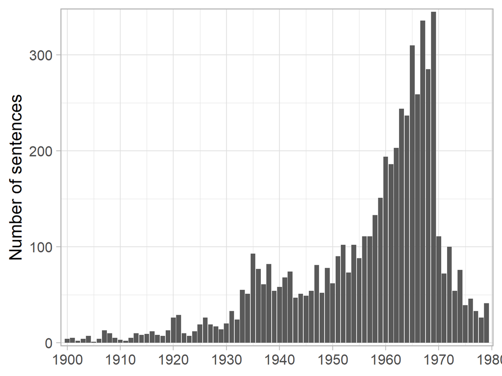

### Closest sentence from ‘rational’ and ‘rationality’ of the backbone community

Sentence

Title

Year

Journal

Authors

Words Similarity

Profit maximization is not the same thing as rationality because other ends also may be pursued in a rational way.

[Recent Developments in Economics](https://http://www.jstor.org/stable/1884444)

1954

The Quarterly Journal of Economics

F. Zeuthen

0.765

Even if an individual or firm is irrational, he is in the end forced to behave rationally because of income and market constraints.

[Environmental Control at the Crossroads](https://http://www.jstor.org/stable/4224063)

1971

Journal of Economic Issues

Harold Wolozin

0.751

This is not to deny that a goodly portion of all business behavior may be non-rational, thoughtless, blindly repetitive, deliberately traditional, or mot’vated by extra-economic objectives.

[Marginal Analysis and Empirical Research](https://http://www.jstor.org/stable/1801722)

1946

The American Economic Review

Fritz Machlup

0.735

They defend the assumption in these terms (pages 87-88): “Rationality” in the theory of the firm implies that the individual producer aims at earning the greatest possible money profits.

[Managerial Motivation and the Theory of the Firm](https://http://www.jstor.org/stable/1823583)

1955

The American Economic Review

C. Addison Hickman

0.724

Because X’s owner is not able to predict accurately what these firms will actually 3The use of the word “rational” by Greenhut seems to refer to the idea of “reasonable belief’ arising from the”frequency” approach to probability.

[Plant Location under Uncertainty](https://http://www.jstor.org/stable/3145987)

1977

Land Economics

Robert D. Dean, Thomas M. Carroll

0.722

Characterized in this way, there seems to be little commonality among all of these theories and models, except that they depart in one way or another from the classical assumption of perfect rationality in firm decision making.

[Rational Decision Making in Business Organizations](https://http://www.jstor.org/stable/1808698)

1979

The American Economic Review

Herbert A. Simon

0.722

There is nothing inherently less rational in such an aim than in profit maximization.

[Marginalism and the Demand for Cash in Light of Operations Research Experience](https://http://www.jstor.org/stable/1927409)

1958

The Review of Economics and Statistics

William J. Baumol

0.720

But the ideal of “reasonable” or “just” profit is often at the root of the decision.

[THE SOCIAL SETTING OF GROWTH](https://www.jstor.org/stable/10.2307/23006581)

1959

The Punjab University Economist

SIDNEY C. SUFRIN

0.701

Whatever rationality or irrationality firm behavior possesses must therefore be embodied, at least in the short run, in these rules, procedures, and policies.

[Satisficing, Selection, and The Innovating Remnant](https://http://www.jstor.org/stable/1880703)

1971

The Quarterly Journal of Economics

Sidney G. Winter

0.701

In their opinion the rationalistic assumptions which permeated the philosophy of the businessman, and which sprang from the social thought of the seventeenth and eighteenth centuries with its emphasis upon a natural order, are no longer applicable to the contemporary scene.

[History and the Businessman](https://www.jstor.org/stable/10.2307/3111368)

1956

The Business History Review

W. Woodruff

0.699

To argue the rationality of profit maximization as an objective is strictly meaningless; rationality is an efficiency measure, concerned with the relationship of means to ends.

[Management Economics and the Theory of the Firm](https://http://www.jstor.org/stable/2097339)

1967

The Journal of Industrial Economics

Brian J. Loasby

0.697

This is another facet of the basic variable: the rational spirit, which permeating so many spheres of life from the economic to the religiou.s and artistic produced the atmosphere favourable to the ” formal rationality ” of the entrepreneur. ”

[Some Remarks on “The Theory of Social and Economic Organization”](https://http://www.jstor.org/stable/2549708)

1948

Economica

Edward A. Shils

0.695

But the fundamental doubt is whether these business men, and other business men in similar predicaments, did not feel called upon to devise, and present to the Oxford intellectuals, a theory of business behaviour which is primarily a rationalisation and, in considerable measure, a false rationalisation of behaviour based on instinct rather than reasoning.2 It is with business men’s behaviour, not with their thoughts, that we have to reckon.

[Oxford Studies in the Price Mechanism](https://http://www.jstor.org/stable/2227177)

1952

The Economic Journal

R. F. Kahn

0.688

When uncertainty prevails the treatment of rational behaviour is complicated by the fact that the investor’s planning of his future dispositions in connection with the investment activity will not involve fixed plans - but conditional plans for all possible courses of events.

[Some Reflexions on the Theories of Choice between Alternative Investment Opportunities](https://http://www.jstor.org/stable/40436564)

1967

Weltwirtschaftliches Archiv

Tönu Puu

0.688

For such an analysis reveals that irrational firms would often be “forced” into rational market responses.

[Irrational Behavior and Economic Theory](https://http://www.jstor.org/stable/1827018)

1962

Journal of Political Economy

Gary S. Becker

0.687

8. If investors acted rationally, there might not be uneconomical construction under reproduction cost.

[Railroad Valuation Again: A Rejoinder](https://http://www.jstor.org/stable/1820652)

1926

Journal of Political Economy

John Bauer

0.684

These explanations assume that the business man will not behave rationally, that his behavior does not follow the same rules which it is supposed to follow in the theoretical system of economics.

[Equilibrium Economics and Business-Cycle Theory](https://http://www.jstor.org/stable/1885790)

1930

The Quarterly Journal of Economics

Simon Kuznets

0.683

interest, the entrepreneur’s most rational behaviour would not be to maximise profits but to equate his marginal net revenue to the marginal cost of the use of his own productive factors.

[A Reconsideration of the Theory of Tariffs](https://http://www.jstor.org/stable/2967663)

1942

The Review of Economic Studies

T. De Scitovszky

0.683

Conversely, the operation of a business enterprise becomes less clearly subject to rational criteria when the question which its management seeks to answer becomes: will it (ultimately) be a good thing, instead of, will it pay (soon)?

[The Social Significance of the Modern Corporation](https://http://www.jstor.org/stable/1831602)

1957

The American Economic Review

Carl Kaysen

0.682

If businessmen choose to prefer other aims to the maximization of profit, the preference may be inconvenient for the theorist, but it cannot be called irrational.

[Management Economics and the Theory of the Firm](https://http://www.jstor.org/stable/2097339)

1967

The Journal of Industrial Economics

Brian J. Loasby

0.680

Then rational behavior would dictate that the firm’s profits should be maximized and when the returns are in the owners and managers should sit down together and bargain for the spoils.

[A Neo-Classical Foundation for a Theory of Manager-Controlled Firms](https://http://www.jstor.org/stable/40722874)

1969

Recherches Économiques de Louvain / Louvain Economic Review

John R. Mc Kean, Robert Haney Scott

0.680

### Closest sentences of the backbone community’s centroid

| Sentence | Title | Year | Journal | Authors | Similarity to Backbone Centroid |
| --- | --- | --- | --- | --- | --- |
| While the allegedly orthodox view that savings pass automatically into investment cannot be maintained, neither can the doctrinaire oversaving view be supported that saving (either any saving or that … | [Monetary Policy and Investment](https://http://www.jstor.org/stable/1814478) | 1940 | The American Economic Review | Howard S. Ellis | 0.854 |
| that there is no reason why the Saving of a period should equal the Investment of the period, unless all Saving issues as Investment and no Investment is made from other sources than income. | [Saving and Investment: Saving and Savings](https://http://www.jstor.org/stable/1883282) | 1939 | The Quarterly Journal of Economics | Myra Curti | 0.847 |
| As we have seen, the only sense of money saving in which it is equal in the aggregate for any period to investment expenditure is that in which it is investment expenditure, and the decisions concerne… | [Is Money Saving Equal to Investment?](https://http://www.jstor.org/stable/1881681) | 1937 | The Quarterly Journal of Economics | Myra Curtis | 0.845 |
| And I shall say more: among those who have had a clear conception of capital it seems that certain ones had a vague feeling that their conception of capital was not the one which permits us to assign … | [On the Returns of Productive Agents and on the Productivity of Capital in Particular](https://http://www.jstor.org/stable/1883520) | 1909 | The Quarterly Journal of Economics | Adolphe Landry | 0.837 |
| It is also true that investmentin a community such as ours-cannot be increased by increased desire to save, except as a consequence of the reduction in the rate of interest.3 But all that follows from… | [Money Wage Cuts in Relation to Unemployment: A Reply to Mr. Somers](https://http://www.jstor.org/stable/2967650) | 1939 | The Review of Economic Studies | Nicholas Kaldor | 0.835 |
| (I may say in passing that this dictum has no relation to Mr. Keynes’ famous theorem regarding the equilibrium between savings and investment, which I believe to be fruitful, for he uses savings in a … | [[Mr. Harrod and the Expansion of Credit]: Rejoinder to Mr. Robertson](https://http://www.jstor.org/stable/2549128) | 1934 | Economica | R. F. Harrod | 0.832 |
| He considers that this treatment approximates better to the true meaning of savings decisions., It is difficult to agree with this, for a decision to save is independent of, and by no means always acc… | [The Valuation of the Social Income](https://http://www.jstor.org/stable/2549415) | 1949 | Economica | I. M. D. Little | 0.832 |
| In view of the prevailing tenor of current discussion, it seems important to insist that there is little relation between the hoarding that is causally important and any change in intention to save; t… | [Heimann’s History of Doctrine and Current Issues](https://http://www.jstor.org/stable/1827066) | 1946 | Journal of Political Economy | Frank H. Knight | 0.829 |
| This conception of saving seems to be quite logical regarded from the individual point of view, and, indeed, for a given individual in the stated circumstances it does have a very real meaning: the gr… | [Dynamic Theory of Saving and Investment](https://http://www.jstor.org/stable/3693801) | 1938 | Southern Economic Journal | Montgomery D. Anderson | 0.826 |
| Tightly wedged in between the conception of saving as merely refraining from expenditure and its conception as the accumulating of income-yielding things which results from income exceeding consumptio… | [Saving and Usury: A Symposium](https://http://www.jstor.org/stable/2223770) | 1932 | The Economic Journal | Edwin Cannan, B. P. Adarkar, B. K. Sandwell, J. M. Keynes, K. E. Boulding | 0.822 |
| Not one of them was fully developed as the thesis required, to the point of unqualifiedly condemning all saving, but stopped short with the contention that saving cannot with advantage be carried on b… | [Lauderdale’s Oversaving Theory](https://http://www.jstor.org/stable/1811441) | 1945 | The American Economic Review | Frank Albert Fetter | 0.819 |
| In addition to linking saving explicitly to income there is an equally important denial of the implicit ‘classical’ axiom that motivated investment is indefinitely expansible or contractable, so that … | [Keynes and the Economic System](https://http://www.jstor.org/stable/1827182) | 1948 | Journal of Political Economy | Calvin B. Hoover | 0.819 |
| I have in mind an act of saving without an act of investment; and I see no reason for supposing that such an event must be followed later on by an act of investment without an act of saving.-Note by J… | [Saving and Usury: A Symposium](https://http://www.jstor.org/stable/2223770) | 1932 | The Economic Journal | Edwin Cannan, B. P. Adarkar, B. K. Sandwell, J. M. Keynes, K. E. Boulding | 0.819 |
| The classical argument that interest is necessary to evoke saving wears a different aspect when we appreciate that saving does not necessarily mean investment. | [Interest and Usury in a New Light](https://http://www.jstor.org/stable/2224010) | 1931 | The Economic Journal | H. Somerville | 0.819 |
| This leads one to question whether or not profit maximization really is the motivating or overriding influence. | [Farmers’ Decisions in the Use of Fertilizer](https://http://www.jstor.org/stable/1235024) | 1958 | Journal of Farm Economics | Moyle S. Williams | 0.816 |
| After all, investment is presumably dependent upon current profit expectations whereas those who argue that finance is a limiting factor tend to confuse two propositions: (1) that imperfections in the… | [Investment Control in Post-War Britain, 1945-1955](https://http://www.jstor.org/stable/139463) | 1963 | The Canadian Journal of Economics and Political Science / Revue canadienne d’Economique et de Science politique | Marvin E. Rozen | 0.816 |

### Closest sentences of each HDBSCAN cluster’s centroid composing the backbone community

| Sentence | Title | Year | Journal | Authors | Similarity to HDSBSCAN Centroid |
| --- | --- | --- | --- | --- | --- |
| And I shall say more: among those who have had a clear conception of capital it seems that certain ones had a vague feeling that their conception of capital was not the one which permits us to assign … | [On the Returns of Productive Agents and on the Productivity of Capital in Particular](https://http://www.jstor.org/stable/1883520) | 1909 | The Quarterly Journal of Economics | Adolphe Landry | 0.837 |
| The propriety, likewise, of confining the term capital to that portion of a man’s stock which is actually employed in increasing the productiveness of labour, has likewise been questioned, with good r… | [The Fundamental Notion of Capital, Once More](https://http://www.jstor.org/stable/1884864) | 1904 | The Quarterly Journal of Economics | Charles A. Tuttle | 0.808 |
| important characteristic in the capital concept, has proposed not only to drop from the concept the truly fundamental element,-the idea of a surplus,-but to perpetuate the erroneous assumption of Adam… | [The Real Capital Concept](https://http://www.jstor.org/stable/1882775) | 1903 | The Quarterly Journal of Economics | Charles A. Tuttle | 0.796 |
| It compels us to say that a thing becomes capital or ceases to be capital not because of any change in its physical or economic nature, not because it is more or less serviceable to the community, not… | [Recent Discussion of the Capital Concept](https://http://www.jstor.org/stable/1885860) | 1900 | The Quarterly Journal of Economics | Frank A. Fetter | 0.784 |
| But in attempting to extend the proposition to that capital which a business man invests in undertakings other than his own, one is met by the difficulty that their imperfect availability evidently do… | [Uncertainty in its Relation to the Net Rate of Interest](https://http://www.jstor.org/stable/2221946) | 1912 | The Economic Journal | F. Lavington | 0.781 |
| This view that capital should be based, inot on the property actually held, but on that required, may seem somewhat novel, but it is doubtless well justified. | [The Prevention of Stock-Watering by Public-Service Corporations](https://http://www.jstor.org/stable/1817646) | 1906 | Journal of Political Economy | Arthur W. Spencer | 0.780 |
| To quote: “An individual thinks that to be capital whiclh yields him an income. | [Organization, Distribution, and Wages](https://http://www.jstor.org/stable/1804671) | 1919 | The American Economic Review | Herbert Feis | 0.776 |
| “33 But he treats capitalization as subsequent to a rate of interest, saying:3 When any other goods than enjoyment incomes are considered their values already imply a rate of interest. | [Interest Theories, Old and New](https://http://www.jstor.org/stable/1804984) | 1914 | The American Economic Review | Frank A. Fetter | 0.776 |
| It can scarcely be that he questions the fact that capital itself does thus yield a net product; and it can hardly be that he questions the conclusiveness of such evidence of this fact as common exper… | [Concerning the Nature of Capital: A Reply](https://http://www.jstor.org/stable/1884903) | 1907 | The Quarterly Journal of Economics | John Bates Clark | 0.770 |
| Yet they describe capital as a value, a fund, a quantum of wealth, because this merely quantitative description sufficiently conveys to their minds the idea of a very literal and material thing, which… | [Concerning the Nature of Capital: A Reply](https://http://www.jstor.org/stable/1884903) | 1907 | The Quarterly Journal of Economics | John Bates Clark | 0.765 |

| Sentence | Title | Year | Journal | Authors | Similarity to HDSBSCAN Centroid |
| --- | --- | --- | --- | --- | --- |
| larly applicable to those departments of business activity which have not been cleared, by scientific scrutiny, of popular fallacies, and of the harsh philistinism which hides behind the phrase “Busin… | [The Relation of Education to Industrial Efficiency: The Study of the General Principles of Administration](https://http://www.jstor.org/stable/1810785) | 1915 | The American Economic Review | Edward D. Jones | 0.808 |
| The business world, in spite, or in consequence, of its- practical concerns alnd character, canlnot place itself beyond the reach of such an inisidious and pervasive force. | [Economics and Commercial Education](https://http://www.jstor.org/stable/2957411) | 1901 | The Economic Journal | L. L. Price | 0.797 |
| one reaso’n why the ” theory of business,” leads a, ” life of obstruction ” is becausse the ” men of business” will ” not reason out thle theories ” Economics.furnishes a moeals for curing this defect… | [Economics and Commercial Education](https://http://www.jstor.org/stable/2957411) | 1901 | The Economic Journal | L. L. Price | 0.791 |
| I have been brought to this conclusion of the need and possibility of a consecutive treatment of business problems by observing the light in which successful business men do, as a matter of fact, rega… | [The Enlargement of Economics](https://http://www.jstor.org/stable/2220699) | 1908 | The Economic Journal | W. J. Ashley | 0.780 |
| One is the fact that “business” is a large and complicated concept, and, although at first blush it would seemn as though this were an argument in favor of specialization, it is nevertheless true that… | [The Present Position and Probable Development of Accountancy As a Profession](https://www.jstor.org/stable/10.2307/2635414) | 1909 | American Economic Association Quarterly | J. E. Sterrett | 0.780 |
| But if business is concerned with men’s aims themselves, guiding general instincts into particular channels and focusing general wants into the desire for particular objects, then the study of busines… | [Economics and Modern Psycholoy: I](https://http://www.jstor.org/stable/1820785) | 1918 | Journal of Political Economy | J. M. Clark | 0.765 |
| “Business is a pecuniarily organized scheme of gratifying human wants and, properly understood, falls little, if any, short of being as broad, as inclusive, as life itself in its motives, aspirations,… | [A Balanced Curriculum in Business Education](https://http://www.jstor.org/stable/1823143) | 1917 | Journal of Political Economy | Leon Carroll Marshall | 0.756 |
| The highest sort of business acumen is very often of a kind which is not itself distinctly conscious of the motives by which it is actuated. | [The Enlargement of Economics](https://http://www.jstor.org/stable/2220699) | 1908 | The Economic Journal | W. J. Ashley | 0.747 |
| If we apply to business the scientific and cultural methods employed in the best university instruction, I am of the opinion that we shall not only promote efficiency through the development of defini… | [The Northwestern University School of Commerce](https://http://www.jstor.org/stable/1819803) | 1913 | Journal of Political Economy | Willard E. Hotchkiss | 0.742 |
| There are changes in technique, some of which may result from an intensive study of his own business and some of which may be forced upon him, in this pecuniary, gain-organized, competitive business w… | [A Balanced Curriculum in Business Education](https://http://www.jstor.org/stable/1823143) | 1917 | Journal of Political Economy | Leon Carroll Marshall | 0.740 |

| Sentence | Title | Year | Journal | Authors | Similarity to HDSBSCAN Centroid |
| --- | --- | --- | --- | --- | --- |
| It is not inconsistent with this to admit the existence past and present of very large, very complex and yet very efficient businesses.- The admission merely shows that the general rule cannot bind me… | [Technical Influences on Vertical Integration](https://http://www.jstor.org/stable/2548354) | 1927 | Economica | F. Lavington | 0.754 |
| But it has come to be generally recognized as a principle of sound business manage? | [Seasonal Problems in Financial Administration](https://http://www.jstor.org/stable/1820756) | 1920 | Journal of Political Economy | Morris A. Copeland | 0.748 |
| In a word, to secure profits and patronage, the entrepreneur would then be comnpelled to rely almost wholly upon true economic effort-a much desired result. | [Computation of Good-Will Profits](https://http://www.jstor.org/stable/1802167) | 1925 | The American Economic Review | C. J. Foreman | 0.723 |
| Indeed, if there were less opportunity to make a profit through the working-out of certain valuations or through financial manipulation of accounts, there would need to be more attention given to poss… | [Problems of Public-Utility Rate Regulation and Fair Return](https://http://www.jstor.org/stable/1822365) | 1924 | Journal of Political Economy | C. O. Ruggles | 0.722 |
| Because doing what has not yet stood the test of experience is no mere act of ordinary business practice, such as we primarily think of when applying our theoretic apparatus, and such as the average m… | [The Explanation of the Business Cycle](https://http://www.jstor.org/stable/2548401) | 1927 | Economica | Joseph Schumpeter | 0.720 |
| But I do assert with emphasis that loose thinking as to the primary object of business education (which sometimes appears to be combined with a naive desire to conceal one’s utilitarian associations f… | [Reorganization of Instruction in Finance in University Schools of Business](https://http://www.jstor.org/stable/1821921) | 1921 | Journal of Political Economy | W. H. Lough | 0.717 |
| Then, and not till then, shall we have a dependable estimate of the relative extent and importance of superior business ability and of the “rent of ability.” | [“Competitive” Costs and the Rent of Business Ability](https://http://www.jstor.org/stable/1883953) | 1924 | The Quarterly Journal of Economics | A. B. Wolfe | 0.716 |
| modities may fall in part upon entrepreneurs’ profits needs to be especially emphasized since it is not quite the reason currently given. | [Some Frequently Neglected Factors in the Incidence of Taxation](https://http://www.jstor.org/stable/1821065) | 1920 | Journal of Political Economy | Harry Gunnison Brown | 0.715 |
| Business is complex and the interpretations which are given to business facts must be thought of as relative. | [Research in Collegiate Schools of Business](https://http://www.jstor.org/stable/1822180) | 1920 | Journal of Political Economy | Horace Secrist | 0.711 |
| The business man’s problem may perhaps assume the form of an emergency demanding action, but no action suggesting itself; or a suggestion of doubtful merit may come to mind; or two or more possible co… | [Business Judgment and the Business Curriculum](https://http://www.jstor.org/stable/1822711) | 1922 | Journal of Political Economy | Forrest A. Kingsbury | 0.710 |

Sentence

Title

Year

Journal

Authors

Similarity to HDSBSCAN Centroid

The grounds of defense for stock speculation must be found, if at all, in another direction: that it is a useful part of the machinery of capitalism, promotes investment, advances the production of wealth.

[Is Market Price Determinate?](https://http://www.jstor.org/stable/1884093)

1921

The Quarterly Journal of Economics

F. W. Taussig

0.771

There can be no doubt as to the existence of such a tendency resulting from the motives of accumulation and capitalization which we have described.

[The Theory of Economic Cycles Based on the Tendency Toward Excessive Capitalization](https://http://www.jstor.org/stable/1927217)

1928

The Review of Economics and Statistics

Mentor Bouniatian

0.744

[Rubber: A Case Study](https://http://www.jstor.org/stable/1805910)

1927

The American Economic Review

William Orton

0.734

In so doing he may find it desirable to distinguish between his pure or excess profits and the ordinary returns to capital and labor; but he can accomplish this without tbe necessity of carrying interest on his investment as a cost on his accounts day in and day out, from year to year.

[Interest on Enterprisers’ Capital as a Cost in the Light of Economic Theory](https://http://www.jstor.org/stable/1805357)

1926

The American Economic Review

Raymond T. Bye

0.733

8. If investors acted rationally, there might not be uneconomical construction under reproduction cost.

[Railroad Valuation Again: A Rejoinder](https://http://www.jstor.org/stable/1820652)

1926

Journal of Political Economy

John Bauer

0.729

But the whole or most of the convenience which is obtained from the use of the conception would be lost if the capital was continually varying with every fluctuation in the money value of the stock in trade and goodwill owned by the company minus its liabilities.

[Early History of the Term Capital](https://http://www.jstor.org/stable/1884097)

1921

The Quarterly Journal of Economics

Edwin Cannan

0.721

of events but inconsistent with the basic idea of the prudent investment.

[Carrier Property Consumed in Operation and the Regulation of Profits](https://http://www.jstor.org/stable/1882471)

1929

The Quarterly Journal of Economics

George O. May

0.718

But granting this early sacrifice of return, have not stockholders, in their calculation of future possibilities or probabilities of a return, already discounted this factor in the price paid for stock?

[Going Value: Its Validity and Logical Application](https://http://www.jstor.org/stable/3138667)

1928

The Journal of Land & Public Utility Economics

John D. Sumner

0.717

A little further on,’ referring specifically to “the problem of vested rights,” he says: To the present owners, the capitalized value represents an investment or an inheritance, precisely as does the present value of anything which is capital in the strict sense.

[The Single-Tax Complex of Some Contemporary Economists](https://http://www.jstor.org/stable/1826183)

1924

Journal of Political Economy

Harry Gunnison Brown

0.716

The point might be raised, however, that this more standard financial structure cannot be associated with customer ownership; that those companies which are interested in securing the largest returns on the common stock naturally have as much capital supplied by bonds and preferred stock as is economically sound; and that those companies which do not have a structure so closely approaching standard could effect the change as readily through the investment banker as through customer ownership campaigns.

[Influence of Customer Ownership on the Financial Structure of Public Utilities](https://http://www.jstor.org/stable/3138653)

1925

The Journal of Land & Public Utility Economics

Henry P. Bruner

0.716

| Sentence | Title | Year | Journal | Authors | Similarity to HDSBSCAN Centroid |
| --- | --- | --- | --- | --- | --- |
| recognised the much more fundamental fact that such constancy of the value dimension has no necessary connection with the reasons why we wish to ” maintain capital intact,” and that in consequence the… | [The Maintenance of Capital](https://http://www.jstor.org/stable/2548607) | 1935 | Economica | F. A. von Hayek | 0.806 |
| I think Mr. Kaldor recognizes this “ceteris paribus,” and the fact that there are infinitely many other ways of investing more capital, apart from replacing individual instruments with others which co… | [On the Theory of Capital: In Reply to Mr. Kaldor](https://http://www.jstor.org/stable/1910085) | 1938 | Econometrica | Frank H. Knight | 0.793 |
| But what exactly this ” given quantity of capital ” means, and what will be the effects of methods of production that are not in accord with it, this, it seems to me, can only be explained by means of… | [On the Relationship Between Investment and Output](https://http://www.jstor.org/stable/2224763) | 1934 | The Economic Journal | F. A. von Hayek | 0.793 |
| In the third place, even if we grant that the amount of capital represented by a single agency ears some, relation (under given stationary conditions) to some kind of average time interval or “structu… | [The Theory of Investment Once More: Mr. Boulding and the Austrians](https://http://www.jstor.org/stable/1882342) | 1935 | The Quarterly Journal of Economics | Frank H. Knight | 0.787 |
| But such a production period explanation of capital is reasonably sound only with reference to assumptions which are alnost entirely false basis, either a dated interval of time, or a particular item … | [Professor Hayek and the Theory of Investment](https://http://www.jstor.org/stable/2224581) | 1935 | The Economic Journal | Frank H. Knight | 0.784 |
| But it must be remembered that the amount of capital is by no means determined by such circumstances only as are 1) ibid. | [ON BÖHM-BAWERK’S THEORY OF INTEREST-RATE](https://www.jstor.org/stable/10.2307/43216793) | 1935 | Kyoto University Economic Review | Kei Shibata | 0.783 |
| But a particular item or capital good need not really be equal now to the quantity of the investment historically made in the past in creating it. | [The Quantity of Capital and the Rate of Interest: I](https://http://www.jstor.org/stable/1823196) | 1936 | Journal of Political Economy | Frank H. Knight | 0.779 |
| In my view, even if the investment-period theory were found to be a tenable explanation of the nature of capital in the stationary state, it could not be regarded as such for a society which is in a p… | [On the Theory of Capital: A Rejoinder to Professor Knight](https://http://www.jstor.org/stable/1907149) | 1938 | Econometrica | Nicholas Kaldor | 0.774 |
| On the face of it, there must be plausible reasons for holding that the use of more capital is equivalent to the use of more time in production; otherwise the doctrine would not have been so generally… | [Professor Hayek and the Theory of Investment](https://http://www.jstor.org/stable/2224581) | 1935 | The Economic Journal | Frank H. Knight | 0.772 |
| But I am not able to agree with Professor Knight when he seems to infer from this truism that capital is never disinvested or that it must be considered as conceptually perpetual. | [The “Period of Production”: A Further Word](https://http://www.jstor.org/stable/1824550) | 1935 | Journal of Political Economy | Fritz Machlup | 0.765 |

| Sentence | Title | Year | Journal | Authors | Similarity to HDSBSCAN Centroid |
| --- | --- | --- | --- | --- | --- |
| But too often the economic theory held by the business man bears little relation to his own practices-it is only if the practices of himself and of others like him were different from what they are th… | [The Relation of Home Investment to Unemployment](https://http://www.jstor.org/stable/2223697) | 1931 | The Economic Journal | R. F. Kahn | 0.785 |
| Whatever be the points of debate among economic theorists about the origin of profits, certain it is that, for individual enterprise, the maintenance of net earnings depends at least partly upon the a… | [The Commercial Application of Forecasting Methods](https://http://www.jstor.org/stable/1230356) | 1930 | Journal of Farm Economics | Donald R. G. Cowan | 0.752 |
| The decisions of business men are not wholly rational, nor are they based upon exact knowledge or upon foreknowledge. | [The Aims of Unemployment Insurance with Especial Reference to the Wisconsin Act](https://http://www.jstor.org/stable/1806430) | 1933 | The American Economic Review | Walter A. Morton | 0.752 |
| While the actions of the business man may be based in general on purely economic considerations, there is often an indeterminate zone in which his sense of public obligation and his respect for public… | [Report of the Royal Commission on the Textile Industry](https://http://www.jstor.org/stable/137184) | 1939 | The Canadian Journal of Economics and Political Science / Revue canadienne d’Economique et de Science politique | H. R. Kemp | 0.750 |
| These explanations assume that the business man will not behave rationally, that his behavior does not follow the same rules which it is supposed to follow in the theoretical system of economics. | [Equilibrium Economics and Business-Cycle Theory](https://http://www.jstor.org/stable/1885790) | 1930 | The Quarterly Journal of Economics | Simon Kuznets | 0.749 |
| For without too great inaccuracy entrepreneurs might be said to aim at maximising their money profits which seemed a definite enough criterion to decide their policies. | [Expectation and Rational Conduct](https://http://www.jstor.org/stable/41793308) | 1937 | Zeitschrift für Nationalökonomie / Journal of Economics | T. W. Hutchison | 0.746 |
| For example, where economic decisions depend on individual men whose “profits” are distinct from the net income of the enterprise, maximization of individual gain may frequently take precedence over m… | [Stockholdings of Officers and Directors in American Industrial Corporations](https://http://www.jstor.org/stable/1891096) | 1936 | The Quarterly Journal of Economics | R. A. Gordon | 0.743 |
| It is, of course, undeniable that most of the commercial activity in present-day society is carried on as profit-making activity, but the profit-making motive is by no means confined to commercial act… | [THE ESSENTIAL FUNCTION OF COMMERCE AND COMMERCIAL ECONOMICS; AN ESSAY ON THE OBJECTS OF STUDY IN COMMERCIAL BUSINESS SCIENCE AND COMMERCIAL ECONOMICS](https://www.jstor.org/stable/10.2307/43216720) | 1930 | Kyoto University Economic Review | K. Taniguchi | 0.742 |
| For only a person familiar with the method of calculation and reasoning which is likely to guide unconsciously the actions of business men in their search for maximum profit can hope to obtain any val… | [Theoretical Remarks on Price Policy Hotelling’s Case with Variations](https://http://www.jstor.org/stable/1883687) | 1933 | The Quarterly Journal of Economics | F. Zeuthen | 0.739 |
| This notion, which is perhaps more commonly held among German business leaders than any other, is in keeping with classical theory in that it holds profits to be a fair index of efficiency (“rationali… | [The Meaning of Rationalization: An Analysis of the Literature](https://http://www.jstor.org/stable/1883398) | 1932 | The Quarterly Journal of Economics | Robert A. Brady | 0.723 |

| Sentence | Title | Year | Journal | Authors | Similarity to HDSBSCAN Centroid |
| --- | --- | --- | --- | --- | --- |
| that there is no reason why the Saving of a period should equal the Investment of the period, unless all Saving issues as Investment and no Investment is made from other sources than income. | [Saving and Investment: Saving and Savings](https://http://www.jstor.org/stable/1883282) | 1939 | The Quarterly Journal of Economics | Myra Curti | 0.847 |
| As we have seen, the only sense of money saving in which it is equal in the aggregate for any period to investment expenditure is that in which it is investment expenditure, and the decisions concerne… | [Is Money Saving Equal to Investment?](https://http://www.jstor.org/stable/1881681) | 1937 | The Quarterly Journal of Economics | Myra Curtis | 0.845 |
| It is also true that investmentin a community such as ours-cannot be increased by increased desire to save, except as a consequence of the reduction in the rate of interest.3 But all that follows from… | [Money Wage Cuts in Relation to Unemployment: A Reply to Mr. Somers](https://http://www.jstor.org/stable/2967650) | 1939 | The Review of Economic Studies | Nicholas Kaldor | 0.835 |
| (I may say in passing that this dictum has no relation to Mr. Keynes’ famous theorem regarding the equilibrium between savings and investment, which I believe to be fruitful, for he uses savings in a … | [[Mr. Harrod and the Expansion of Credit]: Rejoinder to Mr. Robertson](https://http://www.jstor.org/stable/2549128) | 1934 | Economica | R. F. Harrod | 0.832 |
| This conception of saving seems to be quite logical regarded from the individual point of view, and, indeed, for a given individual in the stated circumstances it does have a very real meaning: the gr… | [Dynamic Theory of Saving and Investment](https://http://www.jstor.org/stable/3693801) | 1938 | Southern Economic Journal | Montgomery D. Anderson | 0.826 |
| Tightly wedged in between the conception of saving as merely refraining from expenditure and its conception as the accumulating of income-yielding things which results from income exceeding consumptio… | [Saving and Usury: A Symposium](https://http://www.jstor.org/stable/2223770) | 1932 | The Economic Journal | Edwin Cannan, B. P. Adarkar, B. K. Sandwell, J. M. Keynes, K. E. Boulding | 0.822 |
| I have in mind an act of saving without an act of investment; and I see no reason for supposing that such an event must be followed later on by an act of investment without an act of saving.-Note by J… | [Saving and Usury: A Symposium](https://http://www.jstor.org/stable/2223770) | 1932 | The Economic Journal | Edwin Cannan, B. P. Adarkar, B. K. Sandwell, J. M. Keynes, K. E. Boulding | 0.819 |
| The classical argument that interest is necessary to evoke saving wears a different aspect when we appreciate that saving does not necessarily mean investment. | [Interest and Usury in a New Light](https://http://www.jstor.org/stable/2224010) | 1931 | The Economic Journal | H. Somerville | 0.819 |
| “5 The weight of his emphasis, however, lies on the fact that saving habits are rather marks of rationality than of hedonistic conduct.6 But even this does not explain why the amount of saving should … | [Wants and Activities in Marshall](https://http://www.jstor.org/stable/1883923) | 1931 | The Quarterly Journal of Economics | Talcott Parsons | 0.815 |
| If saving continues willy-nilly by reason of a fixed psychological propensity without regard to price factors, and if the marginal efficiency of capital in a wealthy community falls below the minimum … | [Mr. Keynes on Underemployment Equilibrium](https://http://www.jstor.org/stable/1824136) | 1936 | Journal of Political Economy | Alvin H. Hansen | 0.813 |

| Sentence | Title | Year | Journal | Authors | Similarity to HDSBSCAN Centroid |
| --- | --- | --- | --- | --- | --- |
| As has already been said, where investment decisions are based on subjective judgments of the relative values of different things and not objective comparison of their values expressed in some common … | [Investment Policy in a Nationalised Industry](https://http://www.jstor.org/stable/2296277) | 1949 | The Review of Economic Studies | M. F. Scott | 0.802 |
| It should be noted, and this is a factor insufficiently stressed by most writers, that all kinds of investment are not equally useful from this point of view.10 For after all, private investment is mo… | [The Theory of Pump-Priming Reëxamined](https://http://www.jstor.org/stable/1807577) | 1940 | The American Economic Review | Paul A. Samuelson | 0.779 |
| Not only is a change in output or in the level of business earnings likely to have an effect upon deliberate investment decisions one way or another, but it is common knowledge that no change in outpu… | [Price and Wage Policies and the Theory of Employment](https://http://www.jstor.org/stable/1909099) | 1940 | Econometrica | Richard M. Bissell, Jr. | 0.779 |
| The concept of invested capital is complex and, in some aspects, illogical. | [The Federal Excess Profits Tax. Part One: Development and Present Status](https://http://www.jstor.org/stable/1052210) | 1945 | Southern Economic Journal | B. U. Ratchford | 0.775 |
| I do not mean to say that each investment has a separate object ; it often happens that one investment exhibits a combination of the above-mentioned considerations. | [A STUDY OF THE CHARACTER OF CURRENT CHINESE ECONOMY](https://www.jstor.org/stable/10.2307/43216979) | 1940 | Kyoto University Economic Review | Fumio Hozumi | 0.771 |
| The nature of the investment decision is largely an imponderable. | [The Corporate Income Tax and the Price Level](https://http://www.jstor.org/stable/1810108) | 1945 | The American Economic Review | Richard Goode | 0.765 |
| Consequently, the problem of deciding between alternative types of investment rather than of making the best selection within any given type is of primary interest here, even though the need for the l… | [Farmers’ Investments. A Neglected Field](https://http://www.jstor.org/stable/1232242) | 1944 | Journal of Farm Economics | L. F. Miller | 0.763 |
| What one does have to believe is that current investment opportunities vary, or rather that they are not “boundless” and in a “given” situation and over longer or shorter periods can be exhausted. | [The Future of Keynesian Economics](https://http://www.jstor.org/stable/1811442) | 1945 | The American Economic Review | David McCord Wright | 0.763 |
| But on the other hand it seems obviously unreasonable to demand that the project of a particular enterprise, which shows good prospects of success in view of exceptional care having been taken over it… | [Patent Reform](https://http://www.jstor.org/stable/2295967) | 1944 | The Review of Economic Studies | Michael Polanvyi, Michael Polanyi | 0.761 |
| When he is deciding whether or not to invest, he will place himself in imagination in the situation of having actually done so: if the gain A-C is big enough, the enjoyment of it in anticipation wiLl … | [A Means of Promoting Investment](https://http://www.jstor.org/stable/2226256) | 1941 | The Economic Journal | G. L. S. Shackle | 0.753 |

| Sentence | Title | Year | Journal | Authors | Similarity to HDSBSCAN Centroid |
| --- | --- | --- | --- | --- | --- |
| While the allegedly orthodox view that savings pass automatically into investment cannot be maintained, neither can the doctrinaire oversaving view be supported that saving (either any saving or that … | [Monetary Policy and Investment](https://http://www.jstor.org/stable/1814478) | 1940 | The American Economic Review | Howard S. Ellis | 0.854 |
| He considers that this treatment approximates better to the true meaning of savings decisions., It is difficult to agree with this, for a decision to save is independent of, and by no means always acc… | [The Valuation of the Social Income](https://http://www.jstor.org/stable/2549415) | 1949 | Economica | I. M. D. Little | 0.832 |
| In view of the prevailing tenor of current discussion, it seems important to insist that there is little relation between the hoarding that is causally important and any change in intention to save; t… | [Heimann’s History of Doctrine and Current Issues](https://http://www.jstor.org/stable/1827066) | 1946 | Journal of Political Economy | Frank H. Knight | 0.829 |
| Not one of them was fully developed as the thesis required, to the point of unqualifiedly condemning all saving, but stopped short with the contention that saving cannot with advantage be carried on b… | [Lauderdale’s Oversaving Theory](https://http://www.jstor.org/stable/1811441) | 1945 | The American Economic Review | Frank Albert Fetter | 0.819 |
| In addition to linking saving explicitly to income there is an equally important denial of the implicit ‘classical’ axiom that motivated investment is indefinitely expansible or contractable, so that … | [Keynes and the Economic System](https://http://www.jstor.org/stable/1827182) | 1948 | Journal of Political Economy | Calvin B. Hoover | 0.819 |
| In defining saving, at least in the case of individuals, adoption of the point of view of the savers seems desirable, since only conscious saving can be expected to follow Keynes’ psychological law of… | [Annual Saving and Underspending of Individuals, 1926-1937](https://http://www.jstor.org/stable/1928397) | 1941 | The Review of Economics and Statistics | Gordon S. Fulcher | 0.804 |
| It seems to me that we approach more closely to the meaning of individual decisions to save if we adopt the alternative view that a decision to save is a decision to accumulate purchasing power over f… | [The Valuation of the Social Income](https://http://www.jstor.org/stable/2549415) | 1949 | Economica | I. M. D. Little | 0.798 |
| It must not be thought that investment of one period must be equal to what people wish to save out of the previous period’s income. | [The Theory of Pump-Priming Reëxamined](https://http://www.jstor.org/stable/1807577) | 1940 | The American Economic Review | Paul A. Samuelson | 0.797 |
| But the fundamental difference between the two cases should be clearly understood: in the present case, the excessive propensity to save, of which we have heard so much lately, is not excessive any mo… | [The Problem of Capital Accumulation](https://http://www.jstor.org/stable/1811691) | 1948 | The American Economic Review | Evsey D. Domar | 0.797 |
| That Saving a Part of One Year’s Income Sacrifices a Perpetual Series of Like Annual Amounts Near the close of the arraignment of saving comes a remarkable argument, in these words: “The abstraction f… | [Lauderdale’s Oversaving Theory](https://http://www.jstor.org/stable/1811441) | 1945 | The American Economic Review | Frank Albert Fetter | 0.795 |

| Sentence | Title | Year | Journal | Authors | Similarity to HDSBSCAN Centroid |
| --- | --- | --- | --- | --- | --- |
| In business, on the other hand, conditions are neither fixed nor certain; and even where the desire for profit is decisive, our usual degree of precision is out of place. | [Welfare Economics and Economic Policy](https://http://www.jstor.org/stable/2549766) | 1946 | Economica | A. Radomysler | 0.799 |
| Finally, business men may not be influenced solely by the profit motive-habit, altruism, pride, or other noneconomic factors may be important-and here the marginal theory gives us no guide whatever.20… | [Capacity Production and the Least Cost Point](https://http://www.jstor.org/stable/596) | 1948 | The American Economic Review | Walter W. Haines | 0.799 |
| If whatever a business man does is explained by the principle of profit-maximization … the analysis acquires the character of a system of definitions and tautologies, and loses much of its value as an… | [Marginal Theory and Business Behavior](https://http://www.jstor.org/stable/1802671) | 1947 | The American Economic Review | Henry M. Oliver, Jr. | 0.797 |
| It is increasingly being admitted that business men may be guided by non-pecuniary motives as well as by the criterion of maximum profits. | [Short-Period Price Determination in Theory and Practice](https://http://www.jstor.org/stable/1810625) | 1948 | The American Economic Review | R. A. Gordon | 0.792 |
| This is not to deny that a goodly portion of all business behavior may be non-rational, thoughtless, blindly repetitive, deliberately traditional, or mot’vated by extra-economic objectives. | [Marginal Analysis and Empirical Research](https://http://www.jstor.org/stable/1801722) | 1946 | The American Economic Review | Fritz Machlup | 0.788 |
| Whether business men usually do, in some imperfectly quantitative way, reason marginally (in the broad sense of that term) if they wish to maximize profits, is, of course, another question. | [Marginal Theory and Business Behavior](https://http://www.jstor.org/stable/1802671) | 1947 | The American Economic Review | Henry M. Oliver, Jr. | 0.778 |
| The behavior of many firms can be more adequately explained if interpreted on the assumption that their objective is something other than mere profit maximization. | [A Reconsideration of the Marginal Productivity Theory](https://http://www.jstor.org/stable/1825537) | 1947 | Journal of Political Economy | M. W. Reder | 0.777 |
| interest, the entrepreneur’s most rational behaviour would not be to maximise profits but to equate his marginal net revenue to the marginal cost of the use of his own productive factors. | [A Reconsideration of the Theory of Tariffs](https://http://www.jstor.org/stable/2967663) | 1942 | The Review of Economic Studies | T. De Scitovszky | 0.769 |
| If, in practice, business men do not equate marginal revenue and marginal cost as such, this may be worthy of note and may make it necessary to explain practical business behaviour otherwise than in m… | [Economic Theory and Business Behaviour](https://http://www.jstor.org/stable/2295916) | 1949 | The Review of Economic Studies | D. C. Hague | 0.763 |
| Business men do not always “calculate” before they make decisions, and they do not always “decide” before they act. | [Marginal Analysis and Empirical Research](https://http://www.jstor.org/stable/1801722) | 1946 | The American Economic Review | Fritz Machlup | 0.758 |

| Sentence | Title | Year | Journal | Authors | Similarity to HDSBSCAN Centroid |
| --- | --- | --- | --- | --- | --- |
| Thus the conditions under which funds are available, the prices of investment goods, and the level of profits prevailing around the time of the decision would seem more significant than those at the t… | [Interest Rates and Manufacturers’ Fixed Investment](https://http://www.jstor.org/stable/1812287) | 1957 | The American Economic Review | Franz Gehrels, Suzanne Wiggins | 0.805 |
| To illustrate this point, consider the problem of investment decisions. | [On the Use of the Theory of Probability in Economics](https://http://www.jstor.org/stable/2295889) | 1952 | The Review of Economic Studies | R. S. Weckstein | 0.792 |
| Somehow or other investment decisions have to be taken. | [Some Problems of Definition and Measurement of Capital](https://http://www.jstor.org/stable/2662121) | 1959 | Oxford Economic Papers | Joan Robinson | 0.785 |
| Even though such investment may meet the basic requirement of not being made merely to permit larger outputs, we would be guilty of overstating the case were we to deny all influence on expectations, … | [Income Growth in Secular Stagnation and Inflation](https://http://www.jstor.org/stable/2226449) | 1953 | The Economic Journal | D. Hamberg | 0.780 |
| As was stated earlier, it is impossible to generalize about the appropriate choice of investment priorities; the arguments made here are such that each case has to be examined on its own merits. | [Maintenance Costs and Economic Development](https://http://www.jstor.org/stable/1827310) | 1959 | Journal of Political Economy | Rudolph C. Blitz | 0.772 |
| Otherwise the phenomenon of investment would be incomprehensible. | [An Investigation Into the Dynamics of Investment](https://http://www.jstor.org/stable/1803060) | 1954 | The American Economic Review | R. W. Clower | 0.771 |
| II Cannot we assume that investors, or a sufficient number of them, will anticipate the repercussions of new investment? | [External Economies, Investment, and Foresight](https://http://www.jstor.org/stable/1826574) | 1955 | Journal of Political Economy | J. A. Stockfisch | 0.765 |
| Investment is determined not only by the forces described by the acceleration principle but also by the supply of funds. | [Duesenberry on Growth and Fluctuations](https://http://www.jstor.org/stable/2227671) | 1959 | The Economic Journal | R. C. O. Matthews | 0.765 |
| As has already been indicated, however, the general solution of the investment decision problem cannot rely solely on either present-value or rate-of-return reasoning. | [Formal Criteria for Investment Decisions](https://http://www.jstor.org/stable/1826746) | 1959 | Journal of Political Economy | Martin J. Bailey | 0.764 |
| Undoubtedly there are other factors, but I should prefer to assign them a residual role; in other words, I would first search for economic motivations of investment behavior before I concede that the … | [Industrial Investment Decisions: A Comparative Analysis](https://http://www.jstor.org/stable/2114427) | 1955 | The Journal of Economic History | Henry G. Aubrey | 0.760 |

| Sentence | Title | Year | Journal | Authors | Similarity to HDSBSCAN Centroid |
| --- | --- | --- | --- | --- | --- |
| This leads one to question whether or not profit maximization really is the motivating or overriding influence. | [Farmers’ Decisions in the Use of Fertilizer](https://http://www.jstor.org/stable/1235024) | 1958 | Journal of Farm Economics | Moyle S. Williams | 0.816 |
| Profit maximization is not the same thing as rationality because other ends also may be pursued in a rational way. | [Recent Developments in Economics](https://http://www.jstor.org/stable/1884444) | 1954 | The Quarterly Journal of Economics | F. Zeuthen | 0.802 |
| But the ideal of “reasonable” or “just” profit is often at the root of the decision. | [THE SOCIAL SETTING OF GROWTH](https://www.jstor.org/stable/10.2307/23006581) | 1959 | The Punjab University Economist | SIDNEY C. SUFRIN | 0.782 |
| Now it seems to methat the traditional attitude, which consists of distinguishing in the profits of businessmen a managerial salary, a monopoly rent, etc., while entirely legitimate, is insufficient. | [The Construction of a New Theory of Profit](https://http://www.jstor.org/stable/1813587) | 1951 | The American Economic Review | Jean Marchal | 0.774 |
| To this end he must pursue profit, but he must avoid action which, though profitable in the present, will damage his future position….2 This seems to me a fair statement of the businessman’s approach … | [Price Formation in Manufacturing Industry and Excess Capacity](https://http://www.jstor.org/stable/2662005) | 1955 | Oxford Economic Papers | H. R. Edwards | 0.774 |
| On the assumption that the businessman’s primary forte should be decision-making rather than theory-construction, and that skill in making decisions comes from practice, emphasis is placed on the case… | [The Case Method of Instruction in Insurance](https://www.jstor.org/stable/10.2307/250782) | 1958 | The Journal of Insurance | Davis T. Ratcliffe | 0.773 |
| It is not helpful to dismiss this lack of vision, of confidence, or of experimenting ambition as an example of a failure to attempt to maximize profits, for they are intimately connected with the natu… | [Limits to the Growth and Size of Firms](https://http://www.jstor.org/stable/1823582) | 1955 | The American Economic Review | Edith Penrose | 0.772 |
| And what, indeed, are we to say of traditional theory when we find -as I am very sure we would find-that management in the giant corporation in fact does recognize and adopt profit for the enterprise … | [Development of Large-Scale Organization: The Soviet Steel Industry: Economic Implications](https://http://www.jstor.org/stable/2114069) | 1952 | The Journal of Economic History | Ben W. Lewis | 0.770 |
| It may be argued that all this amounts to no more than long-run profit maximization, and thus that management in the modern corporation does no more than business management has always tried to do, al… | [The Social Significance of the Modern Corporation](https://http://www.jstor.org/stable/1831602) | 1957 | The American Economic Review | Carl Kaysen | 0.764 |
| For one thing, a business man will not always be concerned simply with his money profits, but will take into account a host of non-monetary (or ‘intangible’) considerations. | [Deductive Systems and Empirical Generalizations in the Theory of the Firm](https://http://www.jstor.org/stable/2661856) | 1952 | Oxford Economic Papers | M. J. Farrell | 0.763 |

| Sentence | Title | Year | Journal | Authors | Similarity to HDSBSCAN Centroid |
| --- | --- | --- | --- | --- | --- |
| After all, investment is presumably dependent upon current profit expectations whereas those who argue that finance is a limiting factor tend to confuse two propositions: (1) that imperfections in the… | [Investment Control in Post-War Britain, 1945-1955](https://http://www.jstor.org/stable/139463) | 1963 | The Canadian Journal of Economics and Political Science / Revue canadienne d’Economique et de Science politique | Marvin E. Rozen | 0.816 |
| This explanation may be perfectly correct in some instances; in others, however, such “investment” may result from preferences xvell founded in the expectation of profit or, conversely, of security ag… | [Capital Formation in Underdeveloped Countries](https://http://www.jstor.org/stable/1812467) | 1960 | The American Economic Review | Nathan Rosenberg | 0.802 |
| As we shall see, it is likely to be valid when there is no direct relation between the amount to be allowed for risk on, and the yield expected from, each project; or when the supply price of investme… | [The Elasticity of the Marginal Efficiency Function](https://http://www.jstor.org/stable/1813844) | 1961 | The American Economic Review | Lorie Tarshis | 0.802 |
| R. K. HARVEy The Ohio State University IT HAS LONG BEEN RECOGNIZED that the capital investment decision has two aspects: (1) it requires a commitment of wealth at one point in time in exchange for the… | [A Portfolio Model of Capital Budgeting Under Risk](https://http://www.jstor.org/stable/2325922) | 1968 | The Journal of Finance | R. K. Harvey | 0.801 |
| In spite of the fact that the desired stock of capital can never be isolated, it is nonetheless fruitful to view investment decisions as part of the broader framework in which assets are allocated as … | [The Demand for Physical Capital: Application of a Wealth Model](https://http://www.jstor.org/stable/2977199) | 1963 | The Journal of Finance | Frederick S. Hammer | 0.801 |
| of capital construction, the requirement for a certain minimum limit of lucrativeness will play a role, as will the principle of returns from invested means. | [Improvement of the Organization and Planned Management of the National Economy](https://http://www.jstor.org/stable/4379314) | 1965 | Eastern European Economics | Josef Lenart | 0.791 |
| This does not deny that risk may enter into the selection among investment alternatives or that profitability may have some influence on the scale of investment. | [Security and a Financial Theory of Investment](https://http://www.jstor.org/stable/1883062) | 1960 | The Quarterly Journal of Economics | Myron J. Gordon | 0.790 |
| An alternative theory of investment is that desired capital is proportional to profit. | [A Comparison of Alternative Theories of Corporate Investment Behavior](https://http://www.jstor.org/stable/1815529) | 1968 | The American Economic Review | Dale W. Jorgenson, Calvin D. Siebert | 0.786 |
| A prediction of investment based on profits, liquidity, capacity utilization, and other variables that enter into a firm’s ability and incentives to invest is genuinely different from one that rests i… | [The Predictive Value of Surveys of Business Intentions](https://http://www.jstor.org/stable/1910885) | 1962 | The American Economic Review | Arthur M. Okun | 0.781 |
| On the one hand investment is determined by profits and some acceleration variable. | [The Allocation of Corporate Profits between Dividends and Retained Earnings](https://http://www.jstor.org/stable/1928344) | 1967 | The Review of Economics and Statistics | Stephen J. Turnovsky | 0.781 |

| Sentence | Title | Year | Journal | Authors | Similarity to HDSBSCAN Centroid |
| --- | --- | --- | --- | --- | --- |
| The managerial motives under discussion are not fully consistent with profits maximization. | [The Motives of Managers, Environmental Restraints, and the Theory of Managerial Enterprise](https://http://www.jstor.org/stable/1879325) | 1964 | The Quarterly Journal of Economics | William L. Baldwin | 0.809 |
| Pursuit of profit does not mean that management spends much of its time contemplating profit as such but that its time is spent on decisions regarding the planning, providing, pricing, and selling of … | [Corporate Control and Capitalism](https://http://www.jstor.org/stable/1880509) | 1965 | The Quarterly Journal of Economics | Shorey Peterson | 0.791 |
| Therefore, even if we agreed with traditional theory that the owners of a firm wish to maximize profits (and we do agree in the case of owner-managed firms), we would contend that the difference betwe… | [A Theory of Large Managerial Firms](https://http://www.jstor.org/stable/1829037) | 1965 | Journal of Political Economy | R. Joseph Monsen, Jr., Anthony Downs | 0.788 |
| Even if profits maximization is the most accurate single motivational assumption we can make in dealing with the modern corporation, it may be virtually useless as a basis for determination of a singl… | [The Motives of Managers, Environmental Restraints, and the Theory of Managerial Enterprise](https://http://www.jstor.org/stable/1879325) | 1964 | The Quarterly Journal of Economics | William L. Baldwin | 0.788 |
| If managers do not attempt to maximise profits, however, then some other guiding principle of entrepreneurial behaviour must be posited before a unique supply schedule can be derived. | [More on the Aggregate Supply Function](https://http://www.jstor.org/stable/2228715) | 1962 | The Economic Journal | Paul Davidson | 0.770 |
| Then rational behavior would dictate that the firm’s profits should be maximized and when the returns are in the owners and managers should sit down together and bargain for the spoils. | [A Neo-Classical Foundation for a Theory of Manager-Controlled Firms](https://http://www.jstor.org/stable/40722874) | 1969 | Recherches Économiques de Louvain / Louvain Economic Review | John R. Mc Kean, Robert Haney Scott | 0.769 |
| The decisions of the firm thus are a compound of interest in profits and the impact of constraints on enterprise. | [A Behavioral Approach to the Business Enterprise](https://http://www.jstor.org/stable/1055783) | 1960 | Southern Economic Journal | Harold L. Johnson | 0.767 |
| They can choose between profit maximization and other goals. | [The Changing Moral Temper of Economic Thought](https://http://www.jstor.org/stable/41796158) | 1961 | Zeitschrift für Nationalökonomie / Journal of Economics | Walter A. Weißkopf | 0.766 |
| Although it is not strong enough to provide a discrimination between the utilityand profits-maximizing theories, it does suggest that either firms are operated as indicated by the managerial model or,… | [Managerial Discretion and Business Behavior](https://http://www.jstor.org/stable/1812047) | 1963 | The American Economic Review | Oliver E. Williamson | 0.762 |
| The findings reviewed in this paper strongly suggest, although the contention is in no way definitively proven, that profit maximization is a fairly close approximation to actual motives of the typica… | [The Motives of Managers, Environmental Restraints, and the Theory of Managerial Enterprise](https://http://www.jstor.org/stable/1879325) | 1964 | The Quarterly Journal of Economics | William L. Baldwin | 0.761 |

| Sentence | Title | Year | Journal | Authors | Similarity to HDSBSCAN Centroid |
| --- | --- | --- | --- | --- | --- |
| Since the costs of a project are the benefits that could have been derived from alternative uses of the resources, there is a theoretical comparability between items on the two sides of a benefit-cost… | [Problems of Bias in Input Pricing for Benefit Cost Analysis: A Reply](https://http://www.jstor.org/stable/1056935) | 1968 | Southern Economic Journal | Robert M. Dunn, Jr. | 0.782 |
| It will sometimes be necessary to give other economic or extra-economic considerations priority over the demands of lowered costs. | [Earned and Unearned Profits](https://http://www.jstor.org/stable/4379242) | 1963 | Eastern European Economics | Miroslav Koudelka | 0.776 |
| That is to say, an effort is made to judge the ratio of costs to benefits generated from any given project and then a final decision concerning the desirability of the project is made at least partly … | [The Simple Economics of Public Outdoor Recreation](https://http://www.jstor.org/stable/3145566) | 1967 | Land Economics | Warren C. Robinson | 0.774 |
| In this case, if it is accepted that expenditure is not rationed, the net benefit is still sufficient for the purpose; but if the total investment outlay is limited, as always happens, the selection c… | [Methods of Evaluating Alternative Road Projects (Comments)](https://http://www.jstor.org/stable/20052054) | 1967 | Journal of Transport Economics and Policy | Martin Wohl, Brian V. Martin, Ilio Adorisio | 0.769 |
| Either alternatives are being sacrificed or they are not and the attempt to use resources efficiently must be based upon costs that are relevant for the decision at hand. | [Policy Horizons for Future Urban Water Supply](https://http://www.jstor.org/stable/3144748) | 1963 | Land Economics | J. W. Milliman | 0.768 |
| Or economies of scale may dictate the selection of one system and rejection of a rival, even though in cost effectiveness terms they are equivalent. | [Using Costs to Select Weapons](https://http://www.jstor.org/stable/1816283) | 1965 | The American Economic Review | Stephen Enke | 0.762 |
| Either alternatives are being sacrificed or they are not, and the attempt to use resources efficiently must be based upon costs that are relevant for the decision at hand. | [Price Policy and Land Value Taxation for Urban Water Supplies](https://http://www.jstor.org/stable/3485776) | 1966 | The American Journal of Economics and Sociology | Jerome W. Milliman | 0.760 |
| Since funds are limited and a number of public projects compete for the funds, a comparison of the benefit-cost ratios for alternative investments allows decision makers to allocate available funds in… | [Economic Analysis of Air Pollution](https://http://www.jstor.org/stable/3145614) | 1966 | Land Economics | Delbert C. Ogden | 0.755 |
| The Treatment of Incommensurables in Cost-Benefit Analysis t COST-BENEFIT ANALYSIS, and economic analysis generally, is a way of looking at problems of choice. | [The Treatment of Incommensurables in Cost-Benefit Analysis](https://http://www.jstor.org/stable/3145356) | 1966 | Land Economics | E. J. Devine | 0.754 |
| Besides cost trade-offs, there are output trade-offs in choosing among items of expenditure. | [The Economics of Defense against Crime in the Streets](https://http://www.jstor.org/stable/3159648) | 1968 | Land Economics | Martin T. Katzman | 0.754 |

| Sentence | Title | Year | Journal | Authors | Similarity to HDSBSCAN Centroid |
| --- | --- | --- | --- | --- | --- |
| If we combine with our empirical observations on saving as an increasing function of income the assumption that most consumers most of the time in most situations maximize a typical preference functio… | [The Relationship of Saving to the Rate of Interest, Real Income, and Expected Future Prices](https://http://www.jstor.org/stable/1926830) | 1961 | The Review of Economics and Statistics | D. V. T. Bear | 0.810 |
| The common sense of our claim rests largely on two propositions: (a) that the major purpose of saving is to provide a cushion against the major variations in income that typically occur during the lif… | [The Implications of Retirement Security Systems for Consumer Behavior](https://www.jstor.org/stable/10.2307/251249) | 1965 | The Journal of Risk and Insurance | Walter Williams | 0.801 |
| Savings are not thought of as a residual but as the result of a choice made by the individual; the individual weighs the desirability of saving against the desirability of further consumption. | [A Welfare Criterion](https://http://www.jstor.org/stable/1055365) | 1964 | Southern Economic Journal | Ralph W. Pfouts | 0.798 |
| To deny the possibility of such an outcome would be foolish; on the other hand, to hypothesize, without any explanation, exactly offsetting changes in consumption and liquidity preference proper and t… | [The Importance of the Demand for Finance](https://http://www.jstor.org/stable/2662215) | 1967 | Oxford Economic Papers | Paul Davidson | 0.796 |
| Surely one of the most fundamental modifications of traditional saving theory which becomes necessary once we take account of uncertainty, is that the consumer will not generally hold his wealth in th… | [Portfolio Choice in a Theory of Saving](https://http://www.jstor.org/stable/3439052) | 1968 | The Swedish Journal of Economics | Agnar Sandmo | 0.796 |
| ’At the individual or household level, it can be argued that desired saving for certain purposes (notably for retirement and perhaps to some extent for an estate) cannot be satisfactorily expressed as… | [The Aggregate Propensity to Save: Some Concepts and Their Application to International Data](https://http://www.jstor.org/stable/1924628) | 1966 | The Review of Economics and Statistics | Irwin Friend, Paul Taubman | 0.794 |
| 15 It can be argued that saving intentions may be frustrated by the lack of capital goods, so that an increase in the availability of capital goods will automatically generate an increase in savings. | [Monetary Problems of Pakistan](https://http://www.jstor.org/stable/1832172) | 1967 | Journal of Political Economy | Ronald Soligo | 0.790 |
| The question, which kind of savings hypothesis is appropriate, is not one of belief and dogma but of fact. | [The Theory of Economic Growth: A Survey](https://http://www.jstor.org/stable/2228848) | 1964 | The Economic Journal | F. H. Hahn, R. C. O. Matthews | 0.787 |
| The most important question that arises is the theory of saving. | [The Present State of Consumption Theory](https://http://www.jstor.org/stable/1911816) | 1961 | Econometrica | H. S. Houthakker | 0.782 |
| Keynes in the General Theory emphasized personal saving behaviour, and in a brief discussion of saving by corporations, governments, and other institutions he suggested rather obscurely that their mot… | [Corporate Saving Behaviour](https://http://www.jstor.org/stable/139216) | 1963 | The Canadian Journal of Economics and Political Science / Revue canadienne d’Economique et de Science politique | David C. Smith | 0.780 |

| Sentence | Title | Year | Journal | Authors | Similarity to HDSBSCAN Centroid |
| --- | --- | --- | --- | --- | --- |
| Thus, in the case when profit maximization is assumed to be the goal of the firm, it is possible to bridge the gap between the behavioral and conventional theories and to put behavioral content into t… | [The Measurement of Efficiency in Production: An Application to Swedish Manufacturing Industries 1968](https://http://www.jstor.org/stable/3439287) | 1972 | The Swedish Journal of Economics | Bo Carlsson | 0.797 |
| One may then ask whether there is any reason to believe that managers (and in particular managers of lzrge firms) wish to maximize something else than the profits of the firm. | Profit rates and structural variables in French manufacturing industries | 1976 | European Economic Review | Jenny F. | 0.790 |
| Thus, it has been claimed that “although the firm’s interest centres on its profitability, this cannot be the only criterion in judging the work of the directors and the activities of the firm”.’ | [The Economic Reform in Hungary](https://http://www.jstor.org/stable/2551998) | 1970 | Economica | Bela Balassa | 0.787 |
| First, it has been hypothesized that managers treat as distinct decisions the maximization of “true” profits and the maximization of managerial utility (hereafter referred to as the “severable” decisi… | [Managerial Objectives in Regulated Industries: Expense-Preference Behavior in Banking](https://http://www.jstor.org/stable/1828333) | 1977 | Journal of Political Economy | Franklin R. Edwards | 0.783 |
| The general consequence is that the managers are able to pursue their own goals within certain limits and, thus, tend to direct the firm away from the profit maximizing position that represents the ow… | [Property Rights and Economic Theory: A Survey of Recent Literature](https://http://www.jstor.org/stable/2721541) | 1972 | Journal of Economic Literature | Eirik G. Furubotn, Svetozar Pejovich | 0.780 |
| Although profits are an important factor, in many cases it is not the only one or necessarily the overriding one. | [The Effects of Tax Holiday on Investment Decisions: An Empirical Analysis](https://www.jstor.org/stable/10.2307/41258257) | 1974 | The Pakistan Development Review | Sharouh M. Sharif, B. A. Azhar | 0.780 |
| The proposition “firms behave as if they were seeking rationally to maximize profits” 9 is part of the professional credo; doctrinal and methodological disputes relate primarily to the problem of defi… | [Satisficing, Selection, and The Innovating Remnant](https://http://www.jstor.org/stable/1880703) | 1971 | The Quarterly Journal of Economics | Sidney G. Winter | 0.777 |
| “A realistic analysis”, it has been said of modern business, “must avoid the presumption of a profit motive, let alone a maximization of profit motive. | [Gentlemen and Players](https://http://www.jstor.org/stable/2594761) | 1973 | The Economic History Review | D. C. Coleman | 0.775 |
| than maximising the profits of his firm, the decisions taken are likely to be different in many instances from those to be expected from more conventional theory. | [Surveys of Applied Economics: Price Behaviour of Firms](https://http://www.jstor.org/stable/2229953) | 1970 | The Economic Journal | Aubrey Silberston | 0.774 |
| On the other hand, and even more: profit-maximizing behaviour can never be more than a general tendency even in an economic mechanism most perfectly stimulating it; therefore, it can never be expected… | [SOME GENERAL PROBLEMS OF THE HUNGARIAN INVESTMENT SYSTEM](https://http://www.jstor.org/stable/40728641) | 1978 | Acta Oeconomica | K. A. SOÓS | 0.772 |

### Top articles (most sentences) of the backbone cluster

| Title | Year | Journal | Authors | Number sentences | Words Similarity |
| --- | --- | --- | --- | --- | --- |
| [Theories of the Firm: Marginalist, Behavioral, Managerial](https://http://www.jstor.org/stable/1815603) | 1967 | The American Economic Review | Fritz Machlup | 26 | 0.531 |
| [The Motives of Managers, Environmental Restraints, and the Theory of Managerial Enterprise](https://http://www.jstor.org/stable/1879325) | 1964 | The Quarterly Journal of Economics | William L. Baldwin | 26 | 0.548 |
| [Corporate Control and Capitalism](https://http://www.jstor.org/stable/1880509) | 1965 | The Quarterly Journal of Economics | Shorey Peterson | 19 | 0.542 |
| [The Maintenance of Capital](https://http://www.jstor.org/stable/2548607) | 1935 | Economica | F. A. von Hayek | 17 | 0.552 |
| [Some Reflexions on the Theories of Choice between Alternative Investment Opportunities](https://http://www.jstor.org/stable/40436564) | 1967 | Weltwirtschaftliches Archiv | Tönu Puu | 16 | 0.553 |
| [Satisficing, Selection, and The Innovating Remnant](https://http://www.jstor.org/stable/1880703) | 1971 | The Quarterly Journal of Economics | Sidney G. Winter | 16 | 0.577 |
| [NEO-FORDISM: Drucker’s Thought on Business Enterprise](https://www.jstor.org/stable/10.2307/43751409) | 1959 | The Annals of the Hitotsubashi Academy | Shigetaka Mohri | 15 | 0.553 |
| [Managerial Discretion and Business Behavior](https://http://www.jstor.org/stable/1812047) | 1963 | The American Economic Review | Oliver E. Williamson | 14 | 0.544 |
| [Uncertainty, Likelihoods and Investment Decisions](https://http://www.jstor.org/stable/1884131) | 1960 | The Quarterly Journal of Economics | James W. Angell | 14 | 0.541 |
| [Operations Research and the Theory of the Firm](https://http://www.jstor.org/stable/1055227) | 1962 | Southern Economic Journal | Almarin Phillips | 12 | 0.567 |
| [Saving, Investment, and Crisis](https://http://www.jstor.org/stable/1824545) | 1935 | Journal of Political Economy | Walter Egle | 11 | 0.535 |
| [History and the Businessman](https://www.jstor.org/stable/10.2307/3111368) | 1956 | The Business History Review | W. Woodruff | 11 | 0.541 |
| [Corporate Control and Capitalism: Reply](https://http://www.jstor.org/stable/1882713) | 1965 | The Quarterly Journal of Economics | Shorey Peterson | 11 | 0.528 |
| [Industrial Pricing: The Theoretical Basis](https://http://www.jstor.org/stable/3439050) | 1968 | The Swedish Journal of Economics | Odd Langholm | 11 | 0.548 |
| [The Quantity of Capital and the Rate of Interest: I](https://http://www.jstor.org/stable/1823196) | 1936 | Journal of Political Economy | Frank H. Knight | 10 | 0.556 |

### Top articles (most sentences) of the cluster for each time window

| Title | Year | Journal | Authors | Number sentences | Words Similarity |
| --- | --- | --- | --- | --- | --- |
| [Organization, Distribution, and Wages](https://http://www.jstor.org/stable/1804671) | 1919 | The American Economic Review | Herbert Feis | 4 | 0.528 |
| [Interest Theories, Old and New](https://http://www.jstor.org/stable/1804984) | 1914 | The American Economic Review | Frank A. Fetter | 3 | 0.544 |
| [Capital and Interest Once More: II. A Relapse to the Productivity Theory](https://http://www.jstor.org/stable/1883433) | 1907 | The Quarterly Journal of Economics | E. Böhm-Bawerk | 3 | 0.529 |
| [The Fundamental Notion of Capital, Once More](https://http://www.jstor.org/stable/1884864) | 1904 | The Quarterly Journal of Economics | Charles A. Tuttle | 3 | 0.554 |
| [Concerning the Nature of Capital: A Reply](https://http://www.jstor.org/stable/1884903) | 1907 | The Quarterly Journal of Economics | John Bates Clark | 3 | 0.549 |
| [Recent Discussion of the Capital Concept](https://http://www.jstor.org/stable/1885860) | 1900 | The Quarterly Journal of Economics | Frank A. Fetter | 3 | 0.544 |
| [Commercial Banking and Capital Formation: IV](https://http://www.jstor.org/stable/1822000) | 1918 | Journal of Political Economy | H. G. Moulton | 2 | 0.584 |
| [Commercial Banking and Capital Formation: A Criticism](https://http://www.jstor.org/stable/1822123) | 1919 | Journal of Political Economy | Myron W. Watkins, H. G. Moulton | 2 | 0.548 |
| [The Real Capital Concept](https://http://www.jstor.org/stable/1882775) | 1903 | The Quarterly Journal of Economics | Charles A. Tuttle | 2 | 0.540 |
| [The Legal View of Profits](https://http://www.jstor.org/stable/2220883) | 1903 | The Economic Journal | C. P. Sanger | 2 | 0.574 |

| Title | Year | Journal | Authors | Number sentences | Words Similarity |
| --- | --- | --- | --- | --- | --- |
| [Scientific Management and Labor Welfare](https://http://www.jstor.org/stable/1817657) | 1916 | Journal of Political Economy | Robert F. Hoxie | 4 | 0.542 |
| [The Enlargement of Economics](https://http://www.jstor.org/stable/2220699) | 1908 | The Economic Journal | W. J. Ashley | 4 | 0.548 |
| [Economics and Commercial Education](https://http://www.jstor.org/stable/2957411) | 1901 | The Economic Journal | L. L. Price | 4 | 0.581 |
| [A Balanced Curriculum in Business Education](https://http://www.jstor.org/stable/1823143) | 1917 | Journal of Political Economy | Leon Carroll Marshall | 3 | 0.535 |
| [The Role of Money in Economic Theory](https://http://www.jstor.org/stable/1803798) | 1916 | The American Economic Review | Wesley C. Mitchell | 2 | 0.574 |
| [The Relation of Education to Industrial Efficiency: The Study of the General Principles of Administration](https://http://www.jstor.org/stable/1810785) | 1915 | The American Economic Review | Edward D. Jones | 2 | 0.554 |
| [The Northwestern University School of Commerce](https://http://www.jstor.org/stable/1819803) | 1913 | Journal of Political Economy | Willard E. Hotchkiss | 2 | 0.524 |
| [The Limitations of Marginal Utility](https://http://www.jstor.org/stable/1822146) | 1909 | Journal of Political Economy | Thorstein Veblen | 2 | 0.549 |
| [Labor Turnover](https://http://www.jstor.org/stable/1803596) | 1919 | The American Economic Review | George J. Eberle | 1 | 0.523 |
| [A Third Factor in the Variation of Productivity: The Load Factor](https://http://www.jstor.org/stable/1809629) | 1915 | The American Economic Review | G. P. Watkins | 1 | 0.576 |

| Title | Year | Journal | Authors | Number sentences | Words Similarity |
| --- | --- | --- | --- | --- | --- |
| [Research in Collegiate Schools of Business](https://http://www.jstor.org/stable/1822180) | 1920 | Journal of Political Economy | Horace Secrist | 3 | 0.530 |
| [Cost of Production and Price over Long and Short Periods](https://http://www.jstor.org/stable/1822518) | 1921 | Journal of Political Economy | F. H. Knight | 3 | 0.551 |
| [Rationalisation of Industry](https://http://www.jstor.org/stable/2223585) | 1927 | The Economic Journal | D. H. MacGregor | 3 | 0.556 |
| [Graphical Presentation of Thuenen’s Theory of Intensity](https://http://www.jstor.org/stable/1229926) | 1928 | Journal of Farm Economics | Richard Krzymowski, P. G. Minneman | 2 | 0.607 |
| [Soundings in Non-Euclidean Economics](https://http://www.jstor.org/stable/1807501) | 1921 | The American Economic Review | John Maurice Clark | 2 | 0.537 |
| [The Place of Economics in the Curriculum of a School of Business](https://http://www.jstor.org/stable/1819930) | 1926 | Journal of Political Economy | Roswell C. McCrea | 2 | 0.526 |
| [Seasonal Problems in Financial Administration](https://http://www.jstor.org/stable/1820756) | 1920 | Journal of Political Economy | Morris A. Copeland | 2 | 0.563 |
| [Mobility of the Factors of Production as Affecting Variation in Their Proportional Relation to Each Other in Farm Organization](https://http://www.jstor.org/stable/1822700) | 1921 | Journal of Political Economy | John G. Thompson | 2 | 0.526 |
| [The Ethics of Competition](https://http://www.jstor.org/stable/1884053) | 1923 | The Quarterly Journal of Economics | Frank H. Knight | 2 | 0.551 |
| [Technical Influences on Vertical Integration](https://http://www.jstor.org/stable/2548354) | 1927 | Economica | F. Lavington | 2 | 0.539 |

| Title | Year | Journal | Authors | Number sentences | Words Similarity |
| --- | --- | --- | --- | --- | --- |
| [Is Market Price Determinate?](https://http://www.jstor.org/stable/1884093) | 1921 | The Quarterly Journal of Economics | F. W. Taussig | 3 | 0.551 |
| [Public Utility Valuation for Rate Purposes](https://http://www.jstor.org/stable/1811403) | 1926 | The American Economic Review | John H. Bickley | 2 | 0.513 |
| [Are Stock Dividends Income?](https://http://www.jstor.org/stable/1821033) | 1920 | Journal of Political Economy | T. David Zukerman | 2 | 0.552 |
| [Interest During Construction](https://http://www.jstor.org/stable/1822214) | 1920 | Journal of Political Economy | W. A. Paton | 2 | 0.580 |
| [Carrier Property Consumed in Operation and the Regulation of Profits](https://http://www.jstor.org/stable/1882471) | 1929 | The Quarterly Journal of Economics | George O. May | 2 | 0.543 |
| [Stockholders’ Voting Rights and the Centralization of Voting Control](https://http://www.jstor.org/stable/1885170) | 1926 | The Quarterly Journal of Economics | W. H. S. Stevens | 2 | 0.519 |
| [The Theory of Economic Cycles Based on the Tendency Toward Excessive Capitalization](https://http://www.jstor.org/stable/1927217) | 1928 | The Review of Economics and Statistics | Mentor Bouniatian | 2 | 0.570 |
| [Land Speculation](https://http://www.jstor.org/stable/20171665) | 1920 | Journal of Farm Economics | Richard T. Ely | 2 | 0.520 |
| [Going Value: Its Validity and Logical Application](https://http://www.jstor.org/stable/3138667) | 1928 | The Journal of Land & Public Utility Economics | John D. Sumner | 2 | 0.517 |
| [Undepreciated Investment as a Utility Rate Base](https://http://www.jstor.org/stable/3138894) | 1925 | The Journal of Land & Public Utility Economics | George C. Mathews | 2 | 0.541 |

| Title | Year | Journal | Authors | Number sentences | Words Similarity |
| --- | --- | --- | --- | --- | --- |
| [The Maintenance of Capital](https://http://www.jstor.org/stable/2548607) | 1935 | Economica | F. A. von Hayek | 14 | 0.554 |
| [The Quantity of Capital and the Rate of Interest: I](https://http://www.jstor.org/stable/1823196) | 1936 | Journal of Political Economy | Frank H. Knight | 10 | 0.556 |
| [The Mythology of Capital](https://http://www.jstor.org/stable/1885022) | 1936 | The Quarterly Journal of Economics | F. A. v. Hayek | 10 | 0.544 |
| [On the Theory of Capital: In Reply to Mr. Kaldor](https://http://www.jstor.org/stable/1910085) | 1938 | Econometrica | Frank H. Knight | 8 | 0.533 |
| [On the Relationship Between Investment and Output](https://http://www.jstor.org/stable/2224763) | 1934 | The Economic Journal | F. A. von Hayek | 6 | 0.534 |
| [Professor Knight and the “Period of Production”](https://http://www.jstor.org/stable/1823312) | 1935 | Journal of Political Economy | Fritz Machlup | 5 | 0.530 |
| [Professor Hayek and the Theory of Investment](https://http://www.jstor.org/stable/2224581) | 1935 | The Economic Journal | Frank H. Knight | 5 | 0.569 |
| [Capital, Time, and the Interest Rate](https://http://www.jstor.org/stable/2548804) | 1934 | Economica | Frank H. Knight | 5 | 0.545 |
| [Saving, Investment, and Crisis](https://http://www.jstor.org/stable/1824545) | 1935 | Journal of Political Economy | Walter Egle | 4 | 0.533 |
| [The Theory of Investment Once More: Mr. Boulding and the Austrians](https://http://www.jstor.org/stable/1882342) | 1935 | The Quarterly Journal of Economics | Frank H. Knight | 4 | 0.545 |

| Title | Year | Journal | Authors | Number sentences | Words Similarity |
| --- | --- | --- | --- | --- | --- |
| [Profit in American Economic Theory](https://http://www.jstor.org/stable/2967438) | 1933 | The Review of Economic Studies | William S. Hopkins | 5 | 0.534 |
| [Some Notes on Monopoly Price](https://http://www.jstor.org/stable/2967577) | 1937 | The Review of Economic Studies | R. H. Coase | 5 | 0.529 |
| [Thoughts on Perusal of Wesley Mitchell’s Collected Essays](https://http://www.jstor.org/stable/1829688) | 1939 | Journal of Political Economy | A. B. Wolfe | 3 | 0.550 |
| [The Commercial Application of Forecasting Methods](https://http://www.jstor.org/stable/1230356) | 1930 | Journal of Farm Economics | Donald R. G. Cowan | 2 | 0.575 |
| [Why Study Business History?](https://http://www.jstor.org/stable/136675) | 1938 | The Canadian Journal of Economics and Political Science / Revue canadienne d’Economique et de Science politique | N. S. B. Gras | 2 | 0.529 |
| [Real Wages in the United States and Great Britain](https://http://www.jstor.org/stable/136678) | 1938 | The Canadian Journal of Economics and Political Science / Revue canadienne d’Economique et de Science politique | Lorie Tarshis | 2 | 0.540 |
| [Report of the Royal Commission on the Textile Industry](https://http://www.jstor.org/stable/137184) | 1939 | The Canadian Journal of Economics and Political Science / Revue canadienne d’Economique et de Science politique | H. R. Kemp | 2 | 0.590 |
| [Evaluation of the Practical Significance of the Theory of Monopolistic Competition](https://http://www.jstor.org/stable/1803621) | 1939 | The American Economic Review | Fritz Machlup | 2 | 0.519 |
| [Competition in the Rubber-Tire Industry](https://http://www.jstor.org/stable/1803726) | 1938 | The American Economic Review | Lloyd G. Reynolds | 2 | 0.523 |
| [Monopolistic Competition and Public Policy](https://http://www.jstor.org/stable/1807766) | 1936 | The American Economic Review | Donald H. Wallace | 2 | 0.528 |

| Title | Year | Journal | Authors | Number sentences | Words Similarity |
| --- | --- | --- | --- | --- | --- |
| [Economics of Saving](https://http://www.jstor.org/stable/1808795) | 1933 | The American Economic Review | G. P. Watkins | 7 | 0.526 |
| [Saving, Investment, and Crisis](https://http://www.jstor.org/stable/1824545) | 1935 | Journal of Political Economy | Walter Egle | 7 | 0.536 |
| [Dynamic Theory of Saving and Investment](https://http://www.jstor.org/stable/3693801) | 1938 | Southern Economic Journal | Montgomery D. Anderson | 7 | 0.545 |
| [Saving Equals Investment](https://http://www.jstor.org/stable/1881736) | 1938 | The Quarterly Journal of Economics | A. P. Lerner | 4 | 0.555 |
| [Saving and Usury: A Symposium](https://http://www.jstor.org/stable/2223770) | 1932 | The Economic Journal | Edwin Cannan, B. P. Adarkar, B. K. Sandwell, J. M. Keynes, K. E. Boulding | 4 | 0.534 |
| [Underconsumption. An Exposition and a Reply](https://http://www.jstor.org/stable/2548906) | 1933 | Economica | J. A. Hobson, E. F. M. Durbin | 4 | 0.528 |
| [Monetary Equilibrium and the Price Level in a Progressive Economy: A Comment](https://http://www.jstor.org/stable/2549108) | 1935 | Economica | Karl Bode, Gottfried Haberler | 4 | 0.535 |
| [Unemployment: And Mr. Keynes’s Revolution in Economic Theory](https://http://www.jstor.org/stable/136831) | 1937 | The Canadian Journal of Economics and Political Science / Revue canadienne d’Economique et de Science politique | F. H. Knight | 3 | 0.570 |
| [The Process of Capital Formation and Its Relation to Inequality](https://http://www.jstor.org/stable/1807989) | 1936 | The American Economic Review | Raymond T. Bye | 3 | 0.535 |
| [Socialism, Planning, and the Business Cycle](https://http://www.jstor.org/stable/1823455) | 1936 | Journal of Political Economy | Wilhelm Röpke | 3 | 0.529 |

| Title | Year | Journal | Authors | Number sentences | Words Similarity |
| --- | --- | --- | --- | --- | --- |
| [A Theory of Investment-Decisions](https://http://www.jstor.org/stable/2663465) | 1942 | Oxford Economic Papers | G. L. S. Shackle | 9 | 0.538 |
| [Prices, Costs, and Investment](https://http://www.jstor.org/stable/1816430) | 1941 | The American Economic Review | Richard M. Bissell, Jr. | 5 | 0.547 |
| [Professor Hayek on the Pure Theory of Capital](https://http://www.jstor.org/stable/1803239) | 1941 | The American Economic Review | Arthur Smithies | 4 | 0.522 |
| [Diminishing Returns from Investment](https://http://www.jstor.org/stable/1830979) | 1944 | Journal of Political Economy | Frank H. Knight | 4 | 0.569 |
| [Professor Knight on Limits to the Use of Capital](https://http://www.jstor.org/stable/1882845) | 1944 | The Quarterly Journal of Economics | David McCord Wright | 4 | 0.562 |
| [A Means of Promoting Investment](https://http://www.jstor.org/stable/2226256) | 1941 | The Economic Journal | G. L. S. Shackle | 4 | 0.537 |
| [Patent Reform](https://http://www.jstor.org/stable/2295967) | 1944 | The Review of Economic Studies | Michael Polanvyi, Michael Polanyi | 4 | 0.565 |
| [Investment Policy in a Nationalised Industry](https://http://www.jstor.org/stable/2296277) | 1949 | The Review of Economic Studies | M. F. Scott | 4 | 0.556 |
| [The Expectational Dynamics of the Individual](https://http://www.jstor.org/stable/2549459) | 1943 | Economica | G. L. Shackle | 4 | 0.528 |
| [Lauderdale’s Oversaving Theory](https://http://www.jstor.org/stable/1811441) | 1945 | The American Economic Review | Frank Albert Fetter | 3 | 0.546 |

| Title | Year | Journal | Authors | Number sentences | Words Similarity |
| --- | --- | --- | --- | --- | --- |
| [Monetary Policy and Investment](https://http://www.jstor.org/stable/1814478) | 1940 | The American Economic Review | Howard S. Ellis | 5 | 0.544 |
| [Lauderdale’s Oversaving Theory](https://http://www.jstor.org/stable/1811441) | 1945 | The American Economic Review | Frank Albert Fetter | 4 | 0.540 |
| [Some Thoughts on the Nature of Interest](https://http://www.jstor.org/stable/2661704) | 1949 | Oxford Economic Papers | E. Victor Morgan | 3 | 0.553 |
| [The Multiplier](https://http://www.jstor.org/stable/2663443) | 1940 | Oxford Economic Papers | E. G. Dowdell | 3 | 0.551 |
| [Professors Pritchard and Benoit-Smullyan on Bank-Financed Functional Deficits: A Reply](https://http://www.jstor.org/stable/1810635) | 1948 | The American Economic Review | J. Carl Poindexter | 2 | 0.528 |
| [The Problem of Capital Accumulation](https://http://www.jstor.org/stable/1811691) | 1948 | The American Economic Review | Evsey D. Domar | 2 | 0.538 |
| [The State of the “New Economics”](https://http://www.jstor.org/stable/1812743) | 1949 | The American Economic Review | Howard S. Ellis | 2 | 0.553 |
| [The Prospect for Economic Growth: Comment](https://http://www.jstor.org/stable/1812865) | 1947 | The American Economic Review | John P. Carter | 2 | 0.532 |
| [Saving and Investment: Dynamic Aspects](https://http://www.jstor.org/stable/1816763) | 1942 | The American Economic Review | Robert L. Heilbroner | 2 | 0.530 |
| [The Impact of the Great Depression on Economic Thinking](https://http://www.jstor.org/stable/1818200) | 1946 | The American Economic Review | Clarence E. Ayres | 2 | 0.522 |

| Title | Year | Journal | Authors | Number sentences | Words Similarity |
| --- | --- | --- | --- | --- | --- |
| [Marginal Analysis and Empirical Research](https://http://www.jstor.org/stable/1801722) | 1946 | The American Economic Review | Fritz Machlup | 8 | 0.594 |
| [Marginal Theory and Business Behavior](https://http://www.jstor.org/stable/1802671) | 1947 | The American Economic Review | Henry M. Oliver, Jr. | 8 | 0.564 |
| [A Reconsideration of the Marginal Productivity Theory](https://http://www.jstor.org/stable/1825537) | 1947 | Journal of Political Economy | M. W. Reder | 7 | 0.556 |
| [Short-Period Price Determination in Theory and Practice](https://http://www.jstor.org/stable/1810625) | 1948 | The American Economic Review | R. A. Gordon | 6 | 0.549 |
| [Economic Theory and Business Behaviour](https://http://www.jstor.org/stable/2295916) | 1949 | The Review of Economic Studies | D. C. Hague | 6 | 0.555 |
| [The Theory of Pricing](https://http://www.jstor.org/stable/23818871) | 1949 | Jahrbücher für Nationalökonomie und Statistik / Journal of Economics and Statistics | Paul. Streeten | 5 | 0.568 |
| [The Business Leader in Theory and Reality](https://http://www.jstor.org/stable/3484172) | 1949 | The American Journal of Economics and Sociology | Fritz Redlich | 5 | 0.533 |
| [Can Prices Allocate Resources in American Agriculture?](https://http://www.jstor.org/stable/1232358) | 1946 | Journal of Farm Economics | John M. Brewster, Howard L. Parsons | 4 | 0.525 |
| [Marginalism, Minimum Wages, and Labor Markets](https://http://www.jstor.org/stable/1802863) | 1947 | The American Economic Review | Richard A. Lester | 4 | 0.519 |
| [Theory of the Firm and of Investment](https://http://www.jstor.org/stable/1905363) | 1946 | Econometrica | Leonid Hurwicz | 4 | 0.560 |

| Title | Year | Journal | Authors | Number sentences | Words Similarity |
| --- | --- | --- | --- | --- | --- |
| [On the Theory of Optimal Investment Decision](https://http://www.jstor.org/stable/1827424) | 1958 | Journal of Political Economy | J. Hirshleifer | 7 | 0.530 |
| [The Acceleration Principle and the Theory of Investment: A Survey](https://http://www.jstor.org/stable/2550657) | 1952 | Economica | A. D. Knox | 7 | 0.533 |
| [The Cost of Capital, Corporation Finance and the Theory of Investment](https://http://www.jstor.org/stable/1809766) | 1958 | The American Economic Review | Franco Modigliani, Merton H. Miller | 6 | 0.546 |
| [Culbertson on Interest Structure: Reply](https://http://www.jstor.org/stable/1884340) | 1958 | The Quarterly Journal of Economics | J. M. Culbertson | 6 | 0.558 |
| [Utility Theory, Decision Theory, and Profit Maximization](https://http://www.jstor.org/stable/1812912) | 1959 | The American Economic Review | Joseph E. Haring, Gorman C. Smith | 5 | 0.548 |
| [The Acceleration Principle Reconsidered](https://http://www.jstor.org/stable/1885334) | 1953 | The Quarterly Journal of Economics | R. S. Eckaus | 5 | 0.534 |
| [The Term Structure of Interest Rates](https://http://www.jstor.org/stable/1885708) | 1957 | The Quarterly Journal of Economics | J. M. Culbertson | 5 | 0.570 |
| [Industrial Investment Decisions: A Comparative Analysis](https://http://www.jstor.org/stable/2114427) | 1955 | The Journal of Economic History | Henry G. Aubrey | 5 | 0.563 |
| [The Disaggregation of Investment in the Study of Economic Growth](https://http://www.jstor.org/stable/2227967) | 1956 | The Economic Journal | A. J. Youngson | 5 | 0.522 |
| [Investment, Uncertainty and Expectations](https://http://www.jstor.org/stable/2296288) | 1954 | The Review of Economic Studies | R. A. D. Egerton | 5 | 0.567 |

| Title | Year | Journal | Authors | Number sentences | Words Similarity |
| --- | --- | --- | --- | --- | --- |
| [NEO-FORDISM: Drucker’s Thought on Business Enterprise](https://www.jstor.org/stable/10.2307/43751409) | 1959 | The Annals of the Hitotsubashi Academy | Shigetaka Mohri | 15 | 0.553 |
| [History and the Businessman](https://www.jstor.org/stable/10.2307/3111368) | 1956 | The Business History Review | W. Woodruff | 11 | 0.541 |
| [On Maximizing Profits: A Distinction Between Chamberlin and Robinson](https://http://www.jstor.org/stable/1813588) | 1951 | The American Economic Review | Stephen Enke | 9 | 0.558 |
| [A Generalized Uncertainty Theory of Profit](https://http://www.jstor.org/stable/1802809) | 1950 | The American Economic Review | J. Fred Weston | 7 | 0.542 |
| [A Critique of Concepts of Workable Competition](https://http://www.jstor.org/stable/1882232) | 1958 | The Quarterly Journal of Economics | Stephen H. Sosnick | 7 | 0.554 |
| [A Note on Entrepreneurial Behaviour](https://http://www.jstor.org/stable/2295762) | 1957 | The Review of Economic Studies | J. P. Nettl | 7 | 0.523 |
| [Deductive Systems and Empirical Generalizations in the Theory of the Firm](https://http://www.jstor.org/stable/2661856) | 1952 | Oxford Economic Papers | M. J. Farrell | 7 | 0.550 |
| [The Social Significance of the Modern Corporation](https://http://www.jstor.org/stable/1831602) | 1957 | The American Economic Review | Carl Kaysen | 6 | 0.577 |
| [Marginalism and the Demand for Cash in Light of Operations Research Experience](https://http://www.jstor.org/stable/1927409) | 1958 | The Review of Economics and Statistics | William J. Baumol | 6 | 0.580 |
| [THE CONCEPT AND SYSTEM OF BUSINESS MANAGEMENT—AN ESSAY DISCUSSED FROM AN ORGANIZATIONAL VEEW-POINT](https://www.jstor.org/stable/10.2307/43217055) | 1959 | Kyoto University Economic Review | Takehiko FURIHATA | 6 | 0.547 |

| Title | Year | Journal | Authors | Number sentences | Words Similarity |
| --- | --- | --- | --- | --- | --- |
| [Some Reflexions on the Theories of Choice between Alternative Investment Opportunities](https://http://www.jstor.org/stable/40436564) | 1967 | Weltwirtschaftliches Archiv | Tönu Puu | 14 | 0.555 |
| [Uncertainty, Likelihoods and Investment Decisions](https://http://www.jstor.org/stable/1884131) | 1960 | The Quarterly Journal of Economics | James W. Angell | 13 | 0.543 |
| [A Neglected Issue in Capital Rationing–The Asset Demand for Money](https://http://www.jstor.org/stable/2977530) | 1966 | The Journal of Finance | Robert E. Krainer | 9 | 0.530 |
| [The Investment Decision in Our System of Capital Formation](https://http://www.jstor.org/stable/4379272) | 1964 | Eastern European Economics | Drago Gorupić | 9 | 0.539 |
| [Risk and Return: Instability of Earnings as a Measure of Risk](https://http://www.jstor.org/stable/3145128) | 1969 | Land Economics | Walter A. Morton | 8 | 0.528 |
| [Security and a Financial Theory of Investment](https://http://www.jstor.org/stable/1883062) | 1960 | The Quarterly Journal of Economics | Myron J. Gordon | 7 | 0.543 |
| [The Locational Decision from the Point of View of the Individual Company](https://www.jstor.org/stable/10.2307/3438580) | 1964 | Ekonomisk Tidskrift | Albert Danielsson | 7 | 0.547 |
| [Corporate Control and Capitalism](https://http://www.jstor.org/stable/1880509) | 1965 | The Quarterly Journal of Economics | Shorey Peterson | 6 | 0.537 |
| [The Firm’s Optimal Debt-Equity Combination and the Cost of Capital](https://http://www.jstor.org/stable/1885578) | 1967 | The Quarterly Journal of Economics | William J. Baumol, Burton G. Malkiel | 6 | 0.542 |
| [Some Further Comments on the Ambiguity and Usefulness of Marginal Efficiency as an Investment Criterion](https://http://www.jstor.org/stable/2662471) | 1965 | Oxford Economic Papers | J. F. Wright | 6 | 0.548 |

| Title | Year | Journal | Authors | Number sentences | Words Similarity |
| --- | --- | --- | --- | --- | --- |
| [Theories of the Firm: Marginalist, Behavioral, Managerial](https://http://www.jstor.org/stable/1815603) | 1967 | The American Economic Review | Fritz Machlup | 26 | 0.531 |
| [The Motives of Managers, Environmental Restraints, and the Theory of Managerial Enterprise](https://http://www.jstor.org/stable/1879325) | 1964 | The Quarterly Journal of Economics | William L. Baldwin | 25 | 0.550 |
| [Corporate Control and Capitalism](https://http://www.jstor.org/stable/1880509) | 1965 | The Quarterly Journal of Economics | Shorey Peterson | 13 | 0.545 |
| [Operations Research and the Theory of the Firm](https://http://www.jstor.org/stable/1055227) | 1962 | Southern Economic Journal | Almarin Phillips | 12 | 0.567 |
| [Industrial Pricing: The Theoretical Basis](https://http://www.jstor.org/stable/3439050) | 1968 | The Swedish Journal of Economics | Odd Langholm | 11 | 0.548 |
| [Managerial Discretion and Business Behavior](https://http://www.jstor.org/stable/1812047) | 1963 | The American Economic Review | Oliver E. Williamson | 10 | 0.541 |
| [Corporate Control and Capitalism: Reply](https://http://www.jstor.org/stable/1882713) | 1965 | The Quarterly Journal of Economics | Shorey Peterson | 10 | 0.529 |
| [The Profit Maximization Assumption](https://http://www.jstor.org/stable/2661778) | 1963 | Oxford Economic Papers | H. T. Koplin | 10 | 0.534 |
| [THE ROLE OF PROFIT IN THE MANAGEMENT OF ENTERPRISES](https://http://www.jstor.org/stable/40727752) | 1967 | Acta Oeconomica | J. Wilcsek | 10 | 0.527 |
| [Management Economics and the Theory of the Firm](https://http://www.jstor.org/stable/2097339) | 1967 | The Journal of Industrial Economics | Brian J. Loasby | 9 | 0.575 |

| Title | Year | Journal | Authors | Number sentences | Words Similarity |
| --- | --- | --- | --- | --- | --- |
| [Cost-Benefit Analysis: A Survey](https://http://www.jstor.org/stable/2229670) | 1965 | The Economic Journal | A. R. Prest, R. Turvey | 6 | 0.521 |
| [A Problem of Bias in Benefit-Cost Analysis: Consumer Surplus Reconsidered](https://http://www.jstor.org/stable/1055115) | 1967 | Southern Economic Journal | Robert M. Dunn, Jr. | 3 | 0.538 |
| [Public Investment Criteria](https://http://www.jstor.org/stable/3144347) | 1964 | Land Economics | William I. Davisson | 3 | 0.529 |
| [The Grand Canyon Controversy: Lessons for Federal Cost-Benefit Practices](https://http://www.jstor.org/stable/3159316) | 1968 | Land Economics | Alan Carlin | 3 | 0.538 |
| [The Radio Spectrum Resource](https://http://www.jstor.org/stable/724946) | 1968 | The Journal of Law & Economics | Harvey J. Levin | 3 | 0.544 |
| [A STUDY ON LOSS IN THE SCIENCE OF ACCOUNTING—AN INTRODUCTION TO THEORIES OF LOSS](https://www.jstor.org/stable/10.2307/43217159) | 1968 | Kyoto University Economic Review | Toshiyoshi OKABE | 3 | 0.517 |
| [Cost Allocation and the Detection of Unprofitable Ventures](https://http://www.jstor.org/stable/1235415) | 1960 | Journal of Farm Economics | Victor E. Smith, C. S. Barnard | 2 | 0.516 |
| [Water Resources Development: A Review of the New Federal Evaluation Procedures](https://http://www.jstor.org/stable/1235739) | 1963 | Journal of Farm Economics | Emery Castle, Maurice Kelso, Delworth Gardner | 2 | 0.518 |
| [Economics in Regional Water Research and Policy](https://http://www.jstor.org/stable/1237369) | 1968 | American Journal of Agricultural Economics | Emery N. Castle, Russell C. Youmans | 2 | 0.530 |
| [The Unseen Hand in Government](https://http://www.jstor.org/stable/1814561) | 1965 | The American Economic Review | Roland N. McKean | 2 | 0.522 |

| Title | Year | Journal | Authors | Number sentences | Words Similarity |
| --- | --- | --- | --- | --- | --- |
| [The Life Insurance. Consumer Saving Relationship](https://www.jstor.org/stable/10.2307/250399) | 1962 | The Journal of Insurance | Walter Williams | 8 | 0.535 |
| [On Optimising the Rate of Saving](https://http://www.jstor.org/stable/2228914) | 1961 | The Economic Journal | Amartya Kumar Sen | 7 | 0.526 |
| [The Implications of Retirement Security Systems for Consumer Behavior](https://www.jstor.org/stable/10.2307/251249) | 1965 | The Journal of Risk and Insurance | Walter Williams | 7 | 0.530 |
| [Restraints and the Allocation of Resources](https://http://www.jstor.org/stable/2662399) | 1968 | Oxford Economic Papers | Charles Kennedy | 6 | 0.527 |
| [On the Optimum Rate of Savings](https://http://www.jstor.org/stable/40436772) | 1963 | Weltwirtschaftliches Archiv | Arnold Heertje | 5 | 0.524 |
| [Corporate Saving Behaviour](https://http://www.jstor.org/stable/139216) | 1963 | The Canadian Journal of Economics and Political Science / Revue canadienne d’Economique et de Science politique | David C. Smith | 4 | 0.552 |
| [Contributions to Indian Economic Analysis: A Survey](https://http://www.jstor.org/stable/1812104) | 1969 | The American Economic Review | Jagdish N. Bhagwati, Sukhamoy Chakravarty | 4 | 0.541 |
| [Second Essay in Dynamic Theory](https://http://www.jstor.org/stable/2228728) | 1960 | The Economic Journal | R. F. Harrod | 4 | 0.521 |
| [The Theory of Economic Growth: A Survey](https://http://www.jstor.org/stable/2228848) | 1964 | The Economic Journal | F. H. Hahn, R. C. O. Matthews | 4 | 0.538 |
| [Keynes and the Nature of Human Affairs](https://http://www.jstor.org/stable/40434865) | 1961 | Weltwirtschaftliches Archiv | G. L. S. Shackle | 4 | 0.517 |

| Title | Year | Journal | Authors | Number sentences | Words Similarity |
| --- | --- | --- | --- | --- | --- |
| [Satisficing, Selection, and The Innovating Remnant](https://http://www.jstor.org/stable/1880703) | 1971 | The Quarterly Journal of Economics | Sidney G. Winter | 16 | 0.577 |
| [Surveys of Applied Economics: Price Behaviour of Firms](https://http://www.jstor.org/stable/2229953) | 1970 | The Economic Journal | Aubrey Silberston | 9 | 0.544 |
| [Some Problems concerning the Role and Motivation of Enterprise Executives](https://http://www.jstor.org/stable/4379488) | 1974 | Eastern European Economics | Zsuzsa Hegedüs, Márton Tardos, George Hajdu | 6 | 0.511 |
| [X-Theory versus Management Discretion Theory](https://http://www.jstor.org/stable/1056828) | 1971 | Southern Economic Journal | M. A. Crew, M. W. Jones-Lee, C. K. Rowley | 5 | 0.529 |
| [Diffusion of Major Technological Innovations in U.S. Iron and Steel Manufacturing](https://http://www.jstor.org/stable/2097611) | 1970 | The Journal of Industrial Economics | Bela Gold, William S. Peirce, Gerhard Rosegger | 5 | 0.529 |
| [Property Rights and Economic Theory: A Survey of Recent Literature](https://http://www.jstor.org/stable/2721541) | 1972 | Journal of Economic Literature | Eirik G. Furubotn, Svetozar Pejovich | 5 | 0.570 |
| [Bonus Formulae and Soviet Managerial Performance](https://http://www.jstor.org/stable/1056854) | 1970 | Southern Economic Journal | Wayne A. Leeman | 4 | 0.526 |
| [Managerial Pay and Corporate Performance](https://http://www.jstor.org/stable/1818414) | 1970 | The American Economic Review | Wilbur G. Lewellen, Blaine Huntsman | 4 | 0.547 |
| [Public Responsibility in the Private Corporation](https://http://www.jstor.org/stable/2098241) | 1972 | The Journal of Industrial Economics | Kenneth R. Andrews | 4 | 0.523 |
| [Toward a General Theory of Managerial Discretion [with Comment and Reply]](https://http://www.jstor.org/stable/30023151) | 1974 | Public Choice | Jean-Luc Migué, Gérard Bélanger, William A. Niskanen, Jean-Luc Migué, Gérard Bélanger | 4 | 0.553 |

### Most cited references in the backbone community

| First Author | Year | Journal | Citation by article | Citation by sentence |
| --- | --- | --- | --- | --- |
| SIMON-H | 1959 | AM EC REV | 11 | 297 |
| MODIGLIANI-F | 1958 | AM EC REV | 18 | 180 |
| LESTER-R | 1946 | AM EC REV | 3 | 150 |
| HALL-R | 1939 | OXFORD EC PAP | 2 | 84 |
| SIMON-H | 1955 | Q J EC | 2 | 84 |
| GORDON-R | 1948 | AM EC REV | 2 | 84 |
| PAPANDREOU-A | 1952 | SURVEY CONT EC | 2 | 84 |
| REDER-M | 1947 | J POLITICAL EC | 2 | 64 |
| SOLOW-R | 1956 | Q J EC | 8 | 48 |
| HARROD-R | 1939 | EC J | 2 | 14 |
| SHARPE-W | 1964 | J FINANCE | 9 | 9 |
| LEIBENSTEIN-H | 1966 | AM EC REV | 9 | 9 |
| HART-A | 1942 | STUDIES MATH EC ECON | 2 | 8 |
| LINTNER-J | 1962 | REV EC STATIST | 4 | 8 |
| PREST-A | 1965 | ECONOMIC J | 3 | 3 |

| First Author | Year | Journal | Citation by article | Citation by sentence |
| --- | --- | --- | --- | --- |
| BAUMOL-W | 1959 | BUSINESS BEHAVIOR VA | 27 | 594 |
| BAUMOL-W | 1959 | BUSINESS BEHAV VALUE | 21 | 546 |
| BERLE-A | 1932 | MODERN CORPORATION P | 16 | 544 |
| CYERT-R | 1963 | BEHAVIORAL THEORY FI | 25 | 400 |
| MARRIS-R | 1964 | ECONOMIC THEORY MANA | 21 | 336 |
| PENROSE-E | 1959 | THEORY GROWTH FIRM | 9 | 225 |
| CYERT-R | 1963 | BEHAV THEORY FIRM | 8 | 208 |
| WILLIAMSON-O | 1964 | EC DISCRETIONARY BEH | 6 | 156 |
| BERLE-A | 1954 | 20TH CENTURY CAPITAL | 6 | 150 |
| HICKS-J | 1950 | CONTRIBUTION THEORY | 15 | 135 |
| ROBINSON-J | 1956 | ACCUMULATION CAPITAL | 15 | 135 |
| ROBINSON-J | 1933 | EC IMPERFECT COMPETI | 5 | 130 |
| SIMON-H | 1957 | ADM BEHAV | 5 | 130 |
| GORDON-R | 1945 | BUSINESS LEADERSHIP | 5 | 125 |
| MEYER-J | 1957 | INVESTMENT DECISION | 17 | 119 |

### Most cited references per kmean clusters

| First Author | Year | Journal | Citation by article | Citation by sentence |
| --- | --- | --- | --- | --- |
| SHOVE-G | 1944 | EC J | 1 | 3 |
| KEYNESJM | 1936 | GENERAL THEORY EMPLO | 1 | 3 |
| MORGANEV | 1944 | ECON J | 1 | 3 |
| GRAHAMF | 1944 | ECON J | 1 | 3 |
| BROWN | 1493 | HIST ACCOUNTING ACCO | 1 | 3 |
| BURN | 1940 | EC HIST STEEL MAKING | 1 | 3 |
| HAYEK | 1944 | ECONOMICA | 1 | 3 |
| MACHLUPF | 1942 | ECONOMICA 1 | 1 | 3 |
| MACHLUP | 1942 | ECONOMICA 2 | 1 | 3 |
| ROBBINSL | 1933 | COMMON SENSE POLITIC | 1 | 3 |

| First Author | Year | Journal | Citation by article | Citation by sentence |
| --- | --- | --- | --- | --- |
| SWEEZYPM | 1942 | THEORY CAPITALIST DE | 2 | 4 |
| FISKHE | 1920 | ENGLISH PUBLIC FINAN | 1 | 3 |
| SMART | 1801 | EC ANN 19 CENTURY | 1 | 3 |
| CRIDERJH | 1944 | SATURDAY EVENIN 0226 | 1 | 3 |
| HAHNLA | 1943 | B CHAMBER COMMERCE P | 1 | 3 |
| HARRISSE | 1941 | EC SOCIAL SECURITY | 1 | 3 |
| KNIGHTFH | 1941 | REV EC STAT | 1 | 3 |
| MOULTONHG | 1943 | NEW PHILOS PUBLIC DE | 1 | 3 |
| MOULTONHG | 1940 | CAPITAL EXPANSION EM | 1 | 3 |
| ROBERTSONDH | 1940 | ESSAYS MONETARY THEO | 1 | 3 |

| First Author | Year | Journal | Citation by article | Citation by sentence |
| --- | --- | --- | --- | --- |
| SRAFFA-P | 1926 | EC J | 1 | 2 |
| KNIGHT-F | 1944 | J POLITICAL EC | 1 | 2 |
| SAMUELSON-P | 1939 | REV EC STATIST | 1 | 2 |
| HARROD-R | 1939 | EC J | 1 | 2 |
| DUESENBERRY-J | 1948 | INCOME EMPLOYMENT PU | 1 | 2 |
| DOMAR-E | 1946 | ECONOMETRICA | 1 | 2 |
| LANGE-O | 1942 | STUDIES MATH EC ECON | 1 | 2 |
| SIMONS-H | 1942 | J POLIT EC | 1 | 2 |
| SCHELLING-T | 1947 | AM ECON REV | 1 | 2 |
| BLOOMFIELD-A | 1938 | AM ECON REV | 1 | 2 |

| First Author | Year | Journal | Citation by article | Citation by sentence |
| --- | --- | --- | --- | --- |
| FISKHE | 1920 | ENGLISH PUBLIC FINAN | 1 | 4 |
| SMART | 1801 | EC ANN 19 CENTURY | 1 | 4 |
| HARRODRF | 1936 | TRADE CYCLE | 2 | 4 |
| SPENCEW | 1807 | RADICAL CAUSE PRESEN | 2 | 4 |
| KUZNETSS | 1948 | ECONOMICA MAY | 2 | 4 |
| *DIVPROGRSURV | 1946 | FED RES B JUL | 3 | 3 |
| DEANJ | 1941 | STAT COST FUNCTIONS | 2 | 2 |
| WITHERSW | 1945 | PUBLIC DEBT | 2 | 2 |
| HANSENAH | 1947 | FISCAL POLICY BUSINE | 1 | 2 |
| HARRODRF | 1948 | DYNAMIC EC | 1 | 2 |

| First Author | Year | Journal | Citation by article | Citation by sentence |
| --- | --- | --- | --- | --- |
| LESTER-R | 1946 | AM EC REV | 1 | 8 |
| HART-A | 1942 | STUDIES MATH EC ECON | 2 | 8 |
| HALLRL | 1939 | OXFORD ECON PAP | 1 | 8 |
| HARRODRF | 1939 | OXFORD ECON PAP | 1 | 8 |
| KATONAG | 1946 | AM ECON REV | 1 | 8 |
| KATONAG | 1945 | PRICE CONTROL BUSINE | 1 | 8 |
| LESTERRA | 1941 | EC LABOR | 1 | 8 |
| DESCITOVZSKYT | 1943 | REV ECON STUD | 1 | 7 |
| LESTER | 1946 | AM ECON REV | 1 | 7 |
| BARNARD | 1938 | FUNCT EXECUTIVE | 1 | 7 |

| First Author | Year | Journal | Citation by article | Citation by sentence |
| --- | --- | --- | --- | --- |
| HARTAG | 1940 | ANTICIPATIONS UNCERT | 3 | 21 |
| GORDONRA | 1945 | BUSINESS LEADERSHIP | 3 | 18 |
| BOULDINGKE | 1941 | EC ANAL | 1 | 7 |
| BOWMAN | 1944 | EC ANAL PUBLIC POLIC | 1 | 7 |
| MATHEWSONSB | 1931 | RESTRICTION OUTPUT U | 1 | 7 |
| MEADE | 1938 | EC ANAL POLICY | 1 | 7 |
| MEYERSAL | 1942 | ELEMENTS MODERN EC | 1 | 7 |
| NOURSE | 1944 | PRICE MAKING DEMOCRA | 1 | 7 |
| NYMANRC | 1934 | UNION MANAGEMENT COO | 1 | 7 |
| ROBINSONJ | 1933 | EC IMPERFECT COMPETI | 1 | 7 |

#### Most cited references for 5_2_1900-1919: capital, depreciation, diminishing_returns, circulating, fisher’s (1950-1959)

| First Author | Year | Journal | Citation by article | Citation by sentence |
| --- | --- | --- | --- | --- |
| LORIE-J | 1955 | J BUS | 1 | 7 |
| ALCHIAN-A | 1955 | AM EC REV | 1 | 7 |
| SAMUELSON-P | 1936 | Q J EC | 1 | 7 |
| ROBERTS-H | 1957 | J BUS | 1 | 7 |
| AFTALIONA | 1909 | REV ECON POLIT | 1 | 7 |
| HART-A | 1937 | Q J EC | 1 | 7 |
| LUTZ-F | 1951 | THEORY INVESTMENT FI | 1 | 7 |
| SOLOMON-E | 1956 | J BUSINESS | 1 | 7 |
| SCITOVSKY-T | 1951 | WELFARE COMPETITION | 1 | 7 |
| DEAN-J | 1951 | MANAGERIAL EC | 1 | 7 |

| First Author | Year | Journal | Citation by article | Citation by sentence |
| --- | --- | --- | --- | --- |
| HICKSJR | 1950 | CONTRIBUTION THEORY | 9 | 63 |
| EINARSENJ | 1938 | REINVESTMENT CYCLES | 4 | 28 |
| HARRODRF | 1936 | TRADE CYCLE ESSAY | 4 | 28 |
| HICKSJR | 1949 | ECONOMICA | 4 | 28 |
| SAMUELSONPA | 1939 | J POLITICAL EC | 4 | 28 |
| FISHER-I | 1930 | THEORY INTEREST | 3 | 21 |
| HARRODRF | 1948 | DYNAMIC EC | 3 | 21 |
| TINBERGENJ | 1938 | ECONOMICA | 3 | 21 |
| KEYNES-J | 1936 | GENERAL THEORY EMPLO | 3 | 18 |
| LANGE-O | 1944 | PRICE FLEXIBILITY EM | 3 | 18 |

| First Author | Year | Journal | Citation by article | Citation by sentence |
| --- | --- | --- | --- | --- |
| HOFSTADTER-R | 1955 | SOCIAL DARWINISM AM | 1 | 11 |
| SAVETH-E | 1952 | FORTUNE APR | 1 | 11 |
| WILSON-C | 1954 | HIST UNILEVER STUDY | 1 | 11 |
| VEBLEN-T | 1912 | THEORY BUSINESS ENTE | 1 | 11 |
| TREVELYAN-G | 1949 | AUTOBIOGRAPHY OTHER | 1 | 11 |
| TAWNEY-R | 1948 | EC HIST REV | 1 | 11 |
| STAMP-J | 1926 | CHRISTIAN ETHIC EC F | 1 | 11 |
| SMITH-A | 1892 | THEORY MORAL SENTIME | 1 | 11 |
| SALVEMINI-G | 1939 | HIST SCI | 1 | 11 |
| NIEBUHR-R | 1934 | REFLECTIONS END ERA | 1 | 11 |

| First Author | Year | Journal | Citation by article | Citation by sentence |
| --- | --- | --- | --- | --- |
| MACHLUPF | 1946 | MARGINAL ANAL EMPIRI | 6 | 54 |
| LARSON-H | 1948 | GUIDE BUSINESS HIST | 3 | 33 |
| TARBELL-I | 1904 | HIST STANDARD OIL CO | 2 | 22 |
| LESTERRA | 1946 | SHORTCOMINGS MARGINA | 2 | 18 |
| BOULDINGKE | 1950 | RECONSTRUCTION EC | 3 | 15 |
| SHACKLEGLS | 1949 | EXPECTATION EC | 3 | 15 |
| KATONAG | 1951 | PSYCHOL ANAL EC BEHA | 3 | 15 |
| BAUMOL-W | 1952 | Q J EC | 2 | 12 |
| HALL-R | 1939 | 2 OXF EC PAP | 2 | 12 |
| NAVIN-T | 1950 | WHITIN MACHINE WORKS | 4 | 12 |

| First Author | Year | Journal | Citation by article | Citation by sentence |
| --- | --- | --- | --- | --- |
| MODIGLIANI-F | 1958 | AM EC REV | 9 | 18 |
| HIRSHLEIFER-J | 1958 | J POLITICAL EC | 1 | 14 |
| LUTZ-F | 1951 | THEORY INVESTMENT FI | 1 | 14 |
| PUU-T | 1964 | STUDIER DET OPTIMALA | 1 | 14 |
| ODHNOFF-J | 1965 | SWEDISH J ECONOMICS | 1 | 14 |
| LUTZ-F | 1945 | Q J ECON | 1 | 14 |
| FISHER-I | 1930 | THEORY INTEREST DETE | 1 | 14 |
| BOULDING-K | 1934 | QUART J ECONOMICS | 1 | 14 |
| SCOTT-I | 1957 | REV EC STUDIES | 1 | 13 |
| KEYNES-J | 1935 | GENERAL THEORY EMPLO | 1 | 9 |

| First Author | Year | Journal | Citation by article | Citation by sentence |
| --- | --- | --- | --- | --- |
| MEYER-J | 1957 | INVESTMENT DECISION | 17 | 119 |
| DUESENBERRY-J | 1958 | BUSINESS CYCLES EC G | 17 | 85 |
| MARKOWITZ-H | 1959 | PORTFOLIO SELECTION | 21 | 84 |
| LUTZ-F | 1951 | THEORY INVESTMENT FI | 9 | 81 |
| KOYCK-L | 1954 | DISTRIBUTED LAGS INV | 14 | 70 |
| BAUMOL-W | 1959 | BUSINESS BEHAVIOR VA | 10 | 60 |
| GORDON-M | 1962 | INVESTMENT FINANCING | 14 | 56 |
| DENISON-E | 1962 | SOURCES EC GROWTH US | 11 | 55 |
| HICKS-J | 1950 | CONTRIBUTION THEORY | 11 | 55 |
| ROBINSON-J | 1956 | ACCUMULATION CAPITAL | 11 | 55 |

| First Author | Year | Journal | Citation by article | Citation by sentence |
| --- | --- | --- | --- | --- |
| HALL-R | 1939 | OXFORD EC PAP | 1 | 26 |
| SIMON-H | 1955 | Q J EC | 1 | 26 |
| STIGLER-G | 1946 | AM ECON REV | 1 | 26 |
| SIMON-H | 1959 | AM EC REV | 1 | 26 |
| MONSEN-R | 1965 | J POLITICAL EC | 1 | 26 |
| SCHUMPETER-J | 1928 | ECON J | 1 | 26 |
| LESTER-R | 1947 | AM EC REV | 1 | 26 |
| LESTER-R | 1946 | AM EC REV | 1 | 26 |
| MACHLUP-F | 1946 | AM EC REV | 1 | 26 |
| MACHLUP-F | 1947 | AM EC REV | 1 | 26 |

| First Author | Year | Journal | Citation by article | Citation by sentence |
| --- | --- | --- | --- | --- |
| BAUMOL-W | 1959 | BUSINESS BEHAV VALUE | 21 | 546 |
| BERLE-A | 1932 | MODERN CORPORATION P | 9 | 225 |
| PENROSE-E | 1959 | THEORY GROWTH FIRM | 9 | 225 |
| CYERT-R | 1963 | BEHAV THEORY FIRM | 8 | 208 |
| WILLIAMSON-O | 1964 | EC DISCRETIONARY BEH | 6 | 156 |
| BERLE-A | 1954 | 20TH CENTURY CAPITAL | 6 | 150 |
| ROBINSON-J | 1933 | EC IMPERFECT COMPETI | 5 | 130 |
| SIMON-H | 1957 | ADM BEHAV | 5 | 130 |
| GORDON-R | 1945 | BUSINESS LEADERSHIP | 5 | 125 |
| MARRIS-R | 1964 | EC THEORY MANAGERIAL | 9 | 81 |

| First Author | Year | Journal | Citation by article | Citation by sentence |
| --- | --- | --- | --- | --- |
| HOTELLING-H | 1938 | ECONOMETRICA JUL | 1 | 3 |
| PREST-A | 1965 | ECONOMIC J | 3 | 3 |
| CHRISTY-F | 1965 | COMMON WEALTH OCEAN | 1 | 3 |
| SCOTT-A | 1955 | NATURAL RESOURCES EC | 1 | 3 |
| LEVIN-H | 1966 | AM ECON ASSOC P | 1 | 3 |
| MCKEAN-R | 1958 | EFFICIENCY GOVT SYST | 1 | 3 |
| *USCOMMTECHNADV | 1966 | EL SPECTR UT SIL CRI | 1 | 3 |
| *USBURRECL | 1964 | PAC SW WAT PLAN SUPP | 1 | 3 |
| SCHURR-S | 1960 | ENERGY AM ECONOMY | 1 | 3 |
| PREST-A | 1965 | EC J DEC | 1 | 3 |

| First Author | Year | Journal | Citation by article | Citation by sentence |
| --- | --- | --- | --- | --- |
| ECKSTEIN-O | 1958 | WATER RESOURCE DEV | 7 | 42 |
| ECKSTEIN-O | 1961 | PUBLIC FINANCES NEED | 6 | 36 |
| FELDSTEIN-M | 1964 | EC J | 6 | 36 |
| KRUTILLA-J | 1958 | MULTIPLE PURPOSE RIV | 6 | 36 |
| MCKEAN-R | 1958 | EFFICIENCY GOVT SYST | 6 | 36 |
| CLAWSON-M | 1959 | RESOURCES FUTURE | 5 | 30 |
| HIRSHLEIFER-J | 1960 | WATER SUPPLY EC TECH | 4 | 24 |
| HITCH-C | 1960 | EC DEFENSE NUCLEAR A | 4 | 24 |
| MUSGRAVE-R | 1959 | THEORY PUBLIC FINANC | 4 | 24 |
| TURVEY-R | 1963 | ECON J | 4 | 24 |

| First Author | Year | Journal | Citation by article | Citation by sentence |
| --- | --- | --- | --- | --- |
| LITTLE-I | 1957 | CRITIQUE WELFARE EC | 1 | 7 |
| DOBB-M | 1960 | ESSAY EC GROWTH | 1 | 7 |
| GRAAFF-J | 1957 | THEORETICAL WELFARE | 1 | 7 |
| WILES-P | 1953 | OXFORD EC PAPERS OCT | 1 | 7 |
| ROBERTSON-D | 1958 | LECTURES EC PRINCIPL | 1 | 7 |
| MEADE-J | 1937 | EC ANAL POLICY 4 | 1 | 7 |
| SOLOW-R | 1956 | Q J EC | 1 | 5 |
| SOLOW-R | 1962 | AM EC REV | 1 | 5 |
| RAMSEY-F | 1928 | EC J | 1 | 5 |
| MALINVAUD-E | 1953 | ECONOMETRICA | 1 | 5 |

| First Author | Year | Journal | Citation by article | Citation by sentence |
| --- | --- | --- | --- | --- |
| ARROW-K | 1951 | SOCIAL CHOICE INDIVI | 6 | 42 |
| SOLOW-R | 1956 | Q J EC | 7 | 28 |
| RAMSEY-F | 1928 | EC J DEC | 6 | 24 |
| MEADE-J | 1961 | NEOCLASSICAL THEORY | 6 | 24 |
| BAUMOL-W | 1952 | WELFARE EC THEORY ST | 3 | 21 |
| FRIEDMAN-M | 1957 | THEORY CONSUMPTION F | 7 | 21 |
| KEYNES-J | 1936 | GENERAL THEORY EMPLO | 5 | 20 |
| CHENERY-H | 1966 | REV ECONOMICS ST FEB | 3 | 18 |
| KOOPMANS-T | 1957 | 3 ESSAYS STATE ECONO | 3 | 18 |
| MARGLIN-S | 1963 | APPROACHES DYNAMIC I | 4 | 16 |

| First Author | Year | Journal | Citation by article | Citation by sentence |
| --- | --- | --- | --- | --- |
| HALL-R | 1939 | OXFORD EC PAP | 1 | 16 |
| SIMON-H | 1955 | Q J EC | 1 | 16 |
| PENROSE-E | 1952 | AM ECON REV | 1 | 16 |
| WILLIAMSON-O | 1963 | AM EC REV | 1 | 16 |
| ALCHIAN-A | 1950 | J POLIT EC | 1 | 16 |
| LESTER-R | 1946 | AM EC REV | 1 | 16 |
| BAUMOL-W | 1964 | AM EC REV | 1 | 16 |
| WINTER-S | 1964 | YALE EC ESSAYS | 1 | 16 |
| WILLIAMSON-O | 1964 | ECONOMICS DISCRETION | 1 | 16 |
| EARLEY-J | 1956 | AM EC REV | 1 | 16 |

| First Author | Year | Journal | Citation by article | Citation by sentence |
| --- | --- | --- | --- | --- |
| CYERT-R | 1963 | BEHAVIORAL THEORY FI | 25 | 400 |
| MARRIS-R | 1964 | ECONOMIC THEORY MANA | 21 | 336 |
| BAUMOL-W | 1959 | BUSINESS BEHAVIOR VA | 17 | 272 |
| WILLIAMSON-O | 1964 | ECONOMICS DISCRETION | 21 | 105 |
| BAIN-J | 1956 | BARRIERS NEW COMPETI | 7 | 63 |
| BERLE-A | 1932 | MODERN CORPORATION P | 7 | 63 |
| DEBREU-G | 1959 | THEORY VALUE | 12 | 60 |
| BAUMOL-W | 1967 | BUSINESS BEHAVIOR VA | 14 | 56 |

## Intertemporal cluster *6: model, political_power, social_life, constitutional*

The cluster gathers 13119 sentences from our corpus. It represents 4.84% of all the sentences selected over the whole period.

The community exists from 1900 to 2009.

The most recurring authors are Frank H. Knight (148 sentences; 41 articles), Jr. (89 sentences; 79 articles), F. A. v. Hayek (68 sentences; 9 articles), O. H. Taylor (61 sentences; 9 articles), Karl Popper (41 sentences; 3 articles), Paul T. Homan (34 sentences; 10 articles), Talcott Parsons (33 sentences; 10 articles), Fritz Machlup (29 sentences; 13 articles), E. S. Mason (25 sentences; 2 articles), Allyn A. Young (24 sentences; 7 articles), Lionel Robbins (23 sentences; 9 articles), Paul A. Samuelson (23 sentences; 17 articles), Wesley C. Mitchell (22 sentences; 5 articles), Kenneth H. Parsons (22 sentences; 5 articles), F. W. Taussig (21 sentences; 16 articles), A. B. Wolfe (21 sentences; 12 articles), Jacob Viner (21 sentences; 12 articles), Morris Ginsberg (21 sentences; 4 articles), Joseph A. Schumpeter (21 sentences; 12 articles).

The most recurring journals are The American Economic Review (826 sentences; 630 articles), The Quarterly Journal of Economics (656 sentences; 382 articles), Journal of Political Economy (639 sentences; 445 articles), Economica (498 sentences; 248 articles), The Economic Journal (467 sentences; 378 articles), Journal of Public Economics (303 sentences; 253 articles).

### Top TF-IDF terms describing the community

| Token | TF-IDF |
| --- | --- |
| model | 0.0051070 |
| political_power | 0.0031297 |
| social_life | 0.0030152 |
| constitutional | 0.0028934 |
| empirical_implications | 0.0028491 |
| models | 0.0025479 |
| governor | 0.0020645 |
| robustness | 0.0020038 |
| import | 0.0019506 |
| sciences | 0.0019250 |
| private_enterprise | 0.0017858 |
| paper | 0.0017849 |
| scientist | 0.0016892 |
| natural_sciences | 0.0016746 |
| judicial | 0.0016719 |
| krugman | 0.0016414 |
| sentiment | 0.0016355 |
| social_sciences | 0.0016272 |
| tlle | 0.0015785 |
| social_science | 0.0015564 |

### Top TF-IDF terms describing the different k-means clusters

#### Top terms 6_18_1900-1919: student, adams, trustworthy, reasonings, summed (1900-1919)

| Token | TF-IDF |
| --- | --- |
| student | 0.0021431 |
| adams | 0.0020241 |
| trustworthy | 0.0019783 |
| reasonings | 0.0017802 |
| summed | 0.0017124 |
| tlle | 0.0015785 |
| fault | 0.0015363 |
| inquiry | 0.0015176 |
| professor | 0.0014992 |
| thinkers | 0.0014850 |
| defects | 0.0014133 |
| principles | 0.0014025 |
| treatise | 0.0013907 |
| ingenuity | 0.0013817 |
| doctrine | 0.0013604 |

#### Top terms 6_19_1900-1919: men’s, exigencies, human_nature, sentiment, ideals (1900-1919)

| Token | TF-IDF |
| --- | --- |
| men’s | 0.0053601 |
| exigencies | 0.0050244 |
| human_nature | 0.0042617 |
| sentiment | 0.0039676 |
| ideals | 0.0039013 |
| instinct | 0.0037047 |
| human_conduct | 0.0034094 |
| dispositions | 0.0033351 |
| social_conditions | 0.0033322 |
| consciousness | 0.0028880 |
| scientist | 0.0024599 |
| passions | 0.0024465 |
| race | 0.0024197 |
| darwinian | 0.0023274 |
| historian | 0.0022730 |

#### Top terms 6_15_1920-1929: soundness, conceives, practical_importance, doctrines, professor (1920-1929)

| Token | TF-IDF |
| --- | --- |
| soundness | 0.0024231 |
| conceives | 0.0019215 |
| practical_importance | 0.0019026 |
| doctrines | 0.0018690 |
| professor | 0.0017871 |
| distinctions | 0.0017122 |
| tendencies | 0.0016957 |
| dissent | 0.0016955 |
| philosopher | 0.0016322 |
| controversial | 0.0016264 |
| orthodox_theory | 0.0016022 |
| truths | 0.0015184 |
| plane | 0.0014669 |
| argumentation | 0.0014424 |
| leviathan | 0.0014353 |

#### Top terms 6_14_1920-1929: sciences, scientific, eighteenth_century, social_sciences, eighteenth (1920-1929)

| Token | TF-IDF |
| --- | --- |
| sciences | 0.0049618 |
| scientific | 0.0037552 |
| eighteenth_century | 0.0033039 |
| social_sciences | 0.0031082 |
| eighteenth | 0.0029829 |
| humanity | 0.0027872 |
| human_nature | 0.0027582 |
| natural_laws | 0.0025822 |
| science | 0.0025425 |
| century | 0.0024222 |
| social_science | 0.0022963 |
| natural_sciences | 0.0022629 |
| scientific_method | 0.0022180 |
| mechanistic | 0.0021228 |
| social_institutions | 0.0021015 |

#### Top terms 6_13_1920-1929: sovereignty, peace, legal, judicial, disputes (1920-1929)

| Token | TF-IDF |
| --- | --- |
| sovereignty | 0.0059720 |
| peace | 0.0043953 |
| legal | 0.0041361 |
| judicial | 0.0040890 |
| disputes | 0.0035238 |
| sovereign | 0.0033738 |
| nation | 0.0033554 |
| legislation | 0.0031662 |
| constitutional | 0.0028177 |
| rights | 0.0027550 |
| law | 0.0027219 |
| international | 0.0027155 |
| morality | 0.0026791 |
| court | 0.0026620 |
| abstractions | 0.0026336 |

#### Top terms 6_18_1930-1939: practical_significance, revolutionary, robbins, pitfalls, reasonings (1930-1939)

| Token | TF-IDF |
| --- | --- |
| practical_significance | 0.0016987 |
| revolutionary | 0.0014450 |
| robbins | 0.0013256 |
| pitfalls | 0.0012993 |
| reasonings | 0.0012993 |
| assumptions | 0.0012661 |
| guard | 0.0012264 |
| refutation | 0.0011213 |
| attractions | 0.0011191 |
| viewpoints | 0.0010838 |
| fallacy | 0.0010788 |
| deductive | 0.0010765 |
| flaws | 0.0010334 |
| illustrations | 0.0010150 |
| attacking | 0.0010084 |

#### Top terms 6_17_1930-1939: social_life, sciences, social_scientist, social_phenomena, scientist (1930-1939)

| Token | TF-IDF |
| --- | --- |
| social_life | 0.0063910 |
| sciences | 0.0051159 |
| social_scientist | 0.0048884 |
| social_phenomena | 0.0037498 |
| scientist | 0.0036180 |
| social_sciences | 0.0036052 |
| science | 0.0035878 |
| social_science | 0.0035514 |
| natural_sciences | 0.0029998 |
| scientific | 0.0029283 |
| social_philosophy | 0.0027711 |
| human_nature | 0.0027423 |
| laws | 0.0025323 |
| sentiment | 0.0023342 |
| scientific_method | 0.0022052 |

#### Top terms 6_19_1940-1949: constitutive, premises, assumptions, objections, reality (1940-1949)

| Token | TF-IDF |
| --- | --- |
| constitutive | 0.0019197 |
| premises | 0.0014018 |
| assumptions | 0.0011798 |
| objections | 0.0011734 |
| reality | 0.0011600 |
| purely_logical | 0.0011044 |
| fundamental_question | 0.0010583 |
| book | 0.0010410 |
| logical_necessity | 0.0010368 |
| douglas | 0.0010253 |
| actuality | 0.0010162 |
| bold | 0.0009964 |
| portions | 0.0009964 |
| soundness | 0.0009493 |
| swing | 0.0009010 |

#### Top terms 6_17_1940-1949: political_power, democratic, politics, democracy, government (1940-1949)

| Token | TF-IDF |
| --- | --- |
| political_power | 0.0060073 |
| democratic | 0.0044685 |
| politics | 0.0043907 |
| democracy | 0.0040929 |
| government | 0.0040284 |
| peace | 0.0037052 |
| compulsion | 0.0034274 |
| political | 0.0030269 |
| constitutional | 0.0029691 |
| practical_reason | 0.0027809 |
| relief | 0.0026787 |
| electoral | 0.0022850 |
| short_sighted | 0.0022315 |
| facility | 0.0021810 |
| emergency | 0.0021810 |

#### Top terms 6_18_1940-1949: sciences, social_science, social_sciences, social_phenomena, social_life (1940-1949)

| Token | TF-IDF |
| --- | --- |
| sciences | 0.0068798 |
| social_science | 0.0052876 |
| social_sciences | 0.0048483 |
| social_phenomena | 0.0045384 |
| social_life | 0.0042973 |
| scientist | 0.0040545 |
| science | 0.0038380 |
| comte | 0.0037266 |
| social_scientist | 0.0026295 |
| physical_sciences | 0.0025893 |
| natural_science | 0.0024844 |
| natural_sciences | 0.0022692 |
| scientific | 0.0021658 |
| laws | 0.0021000 |
| historian | 0.0019668 |

#### Top terms 6_16_1950-1959: sciences, scientific, assumptions, historian, human_motives (1950-1959)

| Token | TF-IDF |
| --- | --- |
| sciences | 0.0011472 |
| scientific | 0.0011031 |
| assumptions | 0.0010525 |
| historian | 0.0010495 |
| human_motives | 0.0010231 |
| social_sciences | 0.0009701 |
| social_science | 0.0009556 |
| synthesis | 0.0008748 |
| morals | 0.0008746 |
| sufficient_reason | 0.0008360 |
| moral | 0.0008108 |
| civilization | 0.0008011 |
| ideals | 0.0008006 |
| mankind | 0.0007966 |
| materially | 0.0007778 |

#### Top terms 6_18_1960-1969: assumptions, model, practical_considerations, sciences, basic_assumptions (1960-1969)

| Token | TF-IDF |
| --- | --- |
| assumptions | 0.0019475 |
| model | 0.0019002 |
| practical_considerations | 0.0009958 |
| sciences | 0.0009797 |
| basic_assumptions | 0.0009545 |
| social_sciences | 0.0009205 |
| models | 0.0009145 |
| generalizations | 0.0008930 |
| priori_reasoning | 0.0008425 |
| empirical | 0.0008414 |
| realism | 0.0007951 |
| augmenting | 0.0007837 |
| theoretical_terms | 0.0007837 |
| criteria | 0.0007682 |
| machlup | 0.0007647 |

#### Top terms 6_8_1970-1979: model, assumptions, models, paper, alternative_assumptions (1970-1979)

| Token | TF-IDF |
| --- | --- |
| model | 0.0059201 |
| assumptions | 0.0033581 |
| models | 0.0019919 |
| paper | 0.0016238 |
| alternative_assumptions | 0.0014938 |
| realism | 0.0014869 |
| rationale | 0.0013024 |
| theoretical_rationale | 0.0009262 |
| underlying_assumptions | 0.0008921 |
| restrictive | 0.0008319 |
| intuitive | 0.0007791 |
| empirical | 0.0007696 |
| tobin | 0.0007685 |
| implications | 0.0007510 |
| section | 0.0007227 |

#### Top terms 6_2_1980-1989: model, models, assumptions, paper, section (1980-1989)

| Token | TF-IDF |
| --- | --- |
| model | 0.0118019 |
| models | 0.0058698 |
| assumptions | 0.0041914 |
| paper | 0.0025193 |
| section | 0.0017412 |
| robust | 0.0015657 |
| insufficient_reason | 0.0013615 |
| assumption | 0.0012539 |
| restrictive | 0.0011160 |
| realism | 0.0010711 |
| restrictive_assumptions | 0.0010584 |
| empirical | 0.0010576 |
| behavioral | 0.0010315 |
| intuitive | 0.0009962 |
| robustness | 0.0009933 |

#### Top terms 6_4_1990-1999: model, models, paper, assumptions, section (1990-1999)

| Token | TF-IDF |
| --- | --- |
| model | 0.0098454 |
| models | 0.0045745 |
| paper | 0.0040875 |
| assumptions | 0.0028051 |
| section | 0.0023712 |
| robustness | 0.0022217 |
| empirical | 0.0021412 |
| parsimonious | 0.0014847 |
| implications | 0.0013706 |
| insufficient_reason | 0.0013436 |
| intuitive | 0.0012583 |
| parsimonious_model | 0.0012155 |
| literature | 0.0011193 |
| intuition | 0.0010421 |
| instrumental | 0.0010098 |

#### Top terms 6_5_2000-2009: model, paper, empirical, section, empirical_implications (2000-2009)

| Token | TF-IDF |
| --- | --- |
| model | 0.0159236 |
| paper | 0.0087272 |
| empirical | 0.0071018 |
| section | 0.0063192 |
| empirical_implications | 0.0047081 |
| models | 0.0042648 |
| krugman | 0.0031643 |
| implications | 0.0028913 |
| robustness | 0.0027965 |
| discuss | 0.0027706 |
| al | 0.0027318 |
| empirical_evidence | 0.0025632 |
| empirical_analysis | 0.0024294 |
| assumptions | 0.0021040 |
| findings | 0.0020716 |

### Distribution of sentences over time

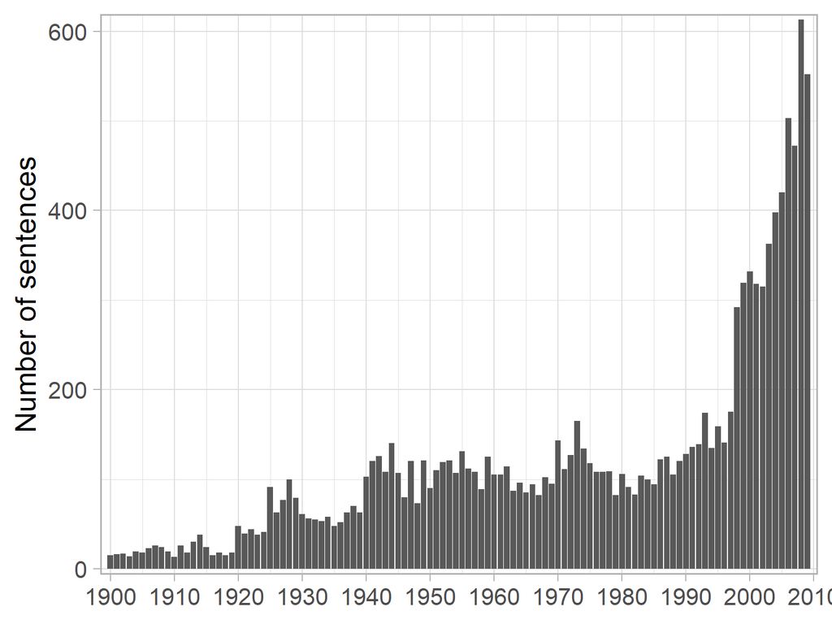

### Closest sentence from ‘rational’ and ‘rationality’ of the backbone community

| Sentence | Title | Year | Journal | Authors | Words Similarity |
| --- | --- | --- | --- | --- | --- |
| The writer would merely suggest that his insights could be more fruitful if a more determined effort were made to fit them into a rational scheme, on the general lines which have here been indicated i… | [Professor Parsons on Economic Motivation](https://http://www.jstor.org/stable/136912) | 1940 | The Canadian Journal of Economics and Political Science / Revue canadienne d’Economique et de Science politique | Frank H. Knight | 0.714 |
| In both cases, however, the argument presupposed the possibility of the achievement, by rulers and by ruled, of a level of intelligence or rationality at which conduct would be determined, not by the … | [Economics and the Idea of Natural Laws](https://http://www.jstor.org/stable/1885439) | 1929 | The Quarterly Journal of Economics | O. H. Taylor | 0.694 |
| We model this idea in a similar way as in Baye and Morgan (2001). | [Platform intermediation in a market for differentiated products](https://doi.org/10.1016/j.euroecorev.2008.08.003) | 2009 | European Economic Review | Galeotti A. | 0.682 |
| Any social science which does not imply the impossibility of rational social construction is entirely blind to the most important facts of social life, and must overlook the only social laws of real v… | [The Poverty of Historicism, I.](https://http://www.jstor.org/stable/2549642) | 1944 | Economica | Karl Popper | 0.674 |
| The ideas of a mental and of a social mechanism are plainly present in the essay, but he insists that “reason” is free to play, or not to play, its part well in the process of the equilibration of “mo… | [Economics and the Idea of Natural Laws](https://http://www.jstor.org/stable/1885439) | 1929 | The Quarterly Journal of Economics | O. H. Taylor | 0.672 |
| We first examine the basic implication of our model. | [Tenure, business cycle and the wage-setting process](https://doi.org/10.1016/j.euroecorev.2004.07.003) | 2006 | European Economic Review | Arozamena L. | 0.669 |
| Our model rationalizes these opposing viewpoints, by incorporating both and offering conditions under which each holds. | [CEO turnover and properties of accounting information](https://doi.org/10.1016/j.jacceco.2003.08.001) | 2003 | Journal of Accounting and Economics | Engel E. | 0.668 |
| We propose—and model—an explanation for this decision. | Migration dynamics | 2002 | Economics Letters | Stark O. | 0.667 |
| This paper shows that simple intuitions may take us astray. | [Deterrence and tax treatment of monetary sanctions and litigation costs](https://doi.org/10.1016/j.irle.2008.01.001) | 2009 | International Review of Law and Economics | Nussim J. | 0.665 |
| The general principles, if rationally determined, are | [The Problem-Solution Basis of Forward Pricing](https://http://www.jstor.org/stable/3144337) | 1949 | Land Economics | Kenneth Parsons | 0.664 |
| Some writers, facing this fact reluctantly or willingly, declare that the “ability” principle should concede to practical necessities, or that it should be adjusted by other “principles” such as “expe… | [CONDITIONS FOR DIRECT TAXATION](https://www.jstor.org/stable/10.2307/43751253) | 1952 | The Annals of the Hitotsubashi Academy | Motokazu Kimura | 0.663 |
| He deduces certain laws of necessity, of variety, of harmony, of cost, of grouping, and of negative utility.2 But they are based on his own conception of human nature again, which, of course, being mo… | [Human Nature in Economic Theory](https://http://www.jstor.org/stable/1822708) | 1922 | Journal of Political Economy | Rexford G. Tugwell | 0.662 |
| This he regards as the principal defect of the classical doctrine, but upon detailed examination he finds a variety of other difficulties in it.1 In the view of the present writer it is possible to de… | [The Ricardian Theory of Gold Movements and Professor Laughlin’s Views of Money](https://http://www.jstor.org/stable/1882786) | 1904 | The Quarterly Journal of Economics | A. C. Whitaker | 0.662 |
| In order to provide a rational explanation for it, the next section first examines the robustness of this result and then provides a possible theoretical explanation. | [Determinants of Secondary Market Prices for Developing Country Syndicated Loans](https://http://www.jstor.org/stable/2328748) | 1990 | The Journal of Finance | Ekkehart Boehmer, William L. Megginson | 0.661 |
| Undoubtedly for practical reasons it has been found inmpossible to adopt a perfectly logical and well-defined system, for it may often be desirable to rely upon vague understandings interpreted with m… | [The Development of British Exchange Control 1939-45](https://http://www.jstor.org/stable/138386) | 1953 | The Canadian Journal of Economics and Political Science / Revue canadienne d’Economique et de Science politique | G. Clayton | 0.661 |
| A man is intelligent not in virtue of having reason which grasps first and indemonstrable truths about fixed principles, in order to reason deductively from them to the particulars which they govern, … | [The Pragmatic Instrumentalist Perspective on the Theory of Institutional Change](https://http://www.jstor.org/stable/4226846) | 1994 | Journal of Economic Issues | Paul D. Bush | 0.660 |
| Other assumptions are needed to build in rational selection, and to control interaction effects. | [Factor Price Changes and Factor Substitution in an Evolutionary Model](https://www.jstor.org/stable/10.2307/3003240) | 1975 | The Bell Journal of Economics | Sidney G. Winter, Richard R. Nelson | 0.660 |
| We do not hereby assume that the decision maker confronted with be believes that all the outcomes of E are equally likely, that is, that he obeys the principle of insufficient reason. | [Expected utility with lower probabilities](https://doi.org/10.1007/BF01065372) | 1994 | Journal of Risk and Uncertainty | Hendon E. | 0.658 |
| If this outline of conditions leading to political decision-making seems to de-emphasize this type of “legislation” unrealistically in favor of its opposite, the writer will plead as a defense the fac… | [The Problem of Evaluating Regulatory Policy](https://http://www.jstor.org/stable/1052211) | 1945 | Southern Economic Journal | Howard R. Smith | 0.657 |
| After fleshing out our idea with the aid of a simple model in Section 2, we examine some of its empirical implications in Section 3. | [Corporate financing decisions when investors take the path of least resistance](https://doi.org/10.1016/j.jfineco.2006.03.005) | 2007 | Journal of Financial Economics | Baker M. | 0.655 |
| We briefly revisit this possibility in Section 4, where we discuss optimal presumption | [A Theory of Legal Presumptions](https://http://www.jstor.org/stable/3555007) | 2000 | Journal of Law, Economics, & Organization | Antonio E. Bernardo, Eric Talley, Ivo Welch | 0.655 |
| These angles of view are all necessary and pragmatically fruitful; but no one of them, nor all of them taken separately and uncoordinated, give light sufficient to guide us if we aspire to a rational … | [On the Content of Welfare](https://http://www.jstor.org/stable/1827869) | 1931 | The American Economic Review | A. B. Wolfe | 0.655 |
| A folly committed by about 25 persons in a million cannot be said to be an essential part of human nature, and if this number remains the same year after year, it is because there is no reason why it … | [On Collective Phenomena and the Scientific Value of Statistical Data](https://www.jstor.org/stable/10.2307/2999937) | 1906 | Publications of the American Economic Association | Ernest G. F. Gryzanovski | 0.655 |

### Closest sentences of the backbone community’s centroid

| Sentence | Title | Year | Journal | Authors | Similarity to Backbone Centroid |
| --- | --- | --- | --- | --- | --- |
| The authors make two main assertions about this model. | Modeling small change: A review article | 2003 | Journal of Monetary Economics | Wallace N. | 0.883 |
| After fleshing out our idea with the aid of a simple model in Section 2, we examine some of its empirical implications in Section 3. | [Corporate financing decisions when investors take the path of least resistance](https://doi.org/10.1016/j.jfineco.2006.03.005) | 2007 | Journal of Financial Economics | Baker M. | 0.879 |
| We focus particular attention on two implications of our model. | [What broad banks do, and markets don’t: Cross-subsidization](https://doi.org/10.1016/j.euroecorev.2008.03.001) | 2009 | European Economic Review | Koeppl T.V. | 0.874 |
| In Section 3 we discuss our model and Section 4 presents some empirical evidence. | Externalities of investment, education and economic growth | 2002 | Economic Modelling | Greiner A. | 0.873 |
| Finally, we discuss some of the model’s implications in the light of the empirical evidence. | [Heckscher-Ohlin and agglomeration](https://doi.org/10.1016/j.regsciurbeco.2004.09.004) | 2005 | Regional Science and Urban Economics | Epifani P. | 0.870 |
| We first examine the basic implication of our model. | [Tenure, business cycle and the wage-setting process](https://doi.org/10.1016/j.euroecorev.2004.07.003) | 2006 | European Economic Review | Arozamena L. | 0.868 |
| In the following subsections, I examine general implications of the model. | [Investment frictions and leverage dynamics](https://doi.org/10.1016/j.jfineco.2007.09.004) | 2008 | Journal of Financial Economics | Tsyplakov S. | 0.868 |
| In this section, we draw out the empirical implications of our model. | Strategic trading and learning about liquidity | 2002 | Journal of Financial Markets | Hong H. | 0.867 |
| In Section 3, we formulate the hypotheses that form the basis of our empirical analysis. | [The role of liquidity and implicit guarantees in the German twin crisis of 1931](https://doi.org/10.1016/j.jimonfin.2008.06.003) | 2009 | Journal of International Money and Finance | Schnabel I. | 0.867 |
| In this section, we investigate the empirical implications of the model. | [Inference in a synchronization game with social interactions](https://doi.org/10.1016/j.jeconom.2008.09.027) | 2009 | Journal of Econometrics | de Paula A. | 0.867 |
| We now consider key assumptions of the model and discuss possible extensions. | [The social cost of rent seeking in Europe](https://doi.org/10.1016/j.ejpoleco.2009.06.001) | 2009 | European Journal of Political Economy | Angelopoulos K. | 0.867 |
| In our model, we suggest some empirical implications to look further into this problem. | [Corporate risk management and asymmetric information](https://doi.org/10.1016/j.qref.2004.04.001) | 2004 | Quarterly Review of Economics and Finance | Zhao L. | 0.865 |
| In Section 4, we examine the main empirical implications of the model. | [Globalization, returns to accumulation and the world distribution of output](https://doi.org/10.1016/j.jmoneco.2006.05.008) | 2006 | Journal of Monetary Economics | Beaudry P. | 0.864 |
| In Section 4, we discuss some of the model’s implications in light of existing evidence, and in Section 5, we present our own empirical results. | [Market liquidity as a sentiment indicator](https://doi.org/10.1016/j.finmar.2003.11.005) | 2004 | Journal of Financial Markets | Baker M. | 0.863 |
| The paper proceeds as follows: Section 2 presents some empirical evidence in support of the crucial assumptions underlying the theoretical model, which is then described in Section 3. | [Political complements in the welfare state: Health care and social security](https://doi.org/10.1016/j.jpubeco.2007.06.005) | 2008 | Journal of Public Economics | Bethencourt C. | 0.861 |

### Closest sentences of each HDBSCAN cluster’s centroid composing the backbone community

| Sentence | Title | Year | Journal | Authors | Similarity to HDSBSCAN Centroid |
| --- | --- | --- | --- | --- | --- |
| This he regards as the principal defect of the classical doctrine, but upon detailed examination he finds a variety of other difficulties in it.1 In the view of the present writer it is possible to de… | [The Ricardian Theory of Gold Movements and Professor Laughlin’s Views of Money](https://http://www.jstor.org/stable/1882786) | 1904 | The Quarterly Journal of Economics | A. C. Whitaker | 0.774 |
| The result has been to indicate that not merely the doctrines, but the very inquiries (except perhaps the most fundamental), the forms in which they are cast, and the quantitative and systematic char? | [Economics and Modern Psycholoy: I](https://http://www.jstor.org/stable/1820785) | 1918 | Journal of Political Economy | J. M. Clark | 0.773 |
| We must distinguish here, as in evers other dolrlain of human inquiry, between the use and t}le abuse of a principle. | [The Economic Interpretation of History](https://www.jstor.org/stable/10.2307/2485774) | 1902 | Publications of the American Economic Association | Edwin R. A. Seligman | 0.765 |
| It is, no doubt, of the utmost utility to consider the results of the inquiries of recognised thinkers before beginning the task afresh, otherwise indeed we are likely to fall far short of the point t… | [The Use and Abuse of Authority in Economics](https://http://www.jstor.org/stable/2221321) | 1903 | The Economic Journal | J. S. Nicholson | 0.762 |
| While practical questions of great importance await profounder study, impatience of metaphysical quibbling is pardonable; but in recent years many students have felt that there was need of earnest eff… | [Recent Discussion of the Capital Concept](https://http://www.jstor.org/stable/1885860) | 1900 | The Quarterly Journal of Economics | Frank A. Fetter | 0.761 |
| It has not been recognized that the original thought has thus been departed from, that the practical difficulty has been slurred over, and that a metaphysical division has been substituted for a concr… | [The Relations between Rent and Interest](https://www.jstor.org/stable/10.2307/2999870) | 1904 | Publications of the American Economic Association | Frank A. Fetter | 0.760 |
| Again the line of demarkation is drawn; and traditional theory is preserved in a place of its own, partly from inertia, partly through vague respect for authority, and partly because we feel that the … | [The Place of Economic Theory in Graduate Work](https://http://www.jstor.org/stable/1823137) | 1917 | Journal of Political Economy | James A. Field | 0.758 |
| The course of history may confirm and verify our reasoning, and not infrequently suggest the need of revising it; but some foundation of theory must precede. | [Schmoller on Protection and Free Trade](https://http://www.jstor.org/stable/1882664) | 1905 | The Quarterly Journal of Economics | F. W. Taussig | 0.747 |
| In- steaci it will be urged that the confusion in the mind of at least one reader is due to a laek of eorrespondence between the eonelusions reaehed and tlle premises upon wllieh they are based. | [Distribution by a Law of Rent](https://www.jstor.org/stable/10.2307/2485846) | 1903 | Publications of the American Economic Association | Charles W. MacFarlane | 0.744 |
| This result may be reached from various points of view. | [Value in Its Relation to Interest](https://http://www.jstor.org/stable/1819589) | 1901 | Journal of Political Economy | R. S. Padan | 0.743 |

#### Top terms 6_18_1900-1919: student, adams, trustworthy, reasonings, summed (1900-1919)

What men have learned to accept as good and definitive for the guidance of conduct and of human relations remains true and definitive and unimpeachable until the exigencies of a later, altered situation enforce a variation from the norms anld canons of the past, and so give rise to a modification of the habits of thought that decide what is, for the time, right in human conduct.

[The Preconceptions of Economic Science](https://http://www.jstor.org/stable/1883770)

1900

The Quarterly Journal of Economics

Thorstein Veblen

0.798

When we consider, then, the import which the real and elemental laws of human nature have (could they but be discovered) for our judgments and policies toward almost all our social institutions, we can better sympathize with the avidity with which both the lay and the scientific world seize upon any alleged discovery in psychology.

[The Relations of Recent Psychological Developments to Economic Theory](https://http://www.jstor.org/stable/1885945)

1919

The Quarterly Journal of Economics

Z. Clark Dickinson

0.777

And so we may speak of public opinion, the preference, or habit, or custom, or convention, of society; and no harm need come of it, despite the fact that some men neither think nor choose in the manner implied, but have their own peculiar judgments or choices or wishes, and yet are members of society entitled to be included in an exact formulation: everyone knows that the thought really runs upon majorities of ” ’most-everybodies;” that is, no harm need come of it, if only1 there were not people to take the notion of a “social mind” seriously, and to import into cases calling for accurate analysis-and to accept as sober fact-a mere

[A New Text: Seligman: “Social Value”](https://http://www.jstor.org/stable/1817617)

1906

Journal of Political Economy

H. J. Davenport

0.774

Such, however, should learn that in its bearing upon the best interests and welfare of society it is a science and a philosophy, “Not harsh and crabbed as dull fools suppose, But musical as is Apollo’s lute.”

[Cost Units](https://http://www.jstor.org/stable/1814920)

1911

The American Economic Review

William Arthur Chase

0.772

The power of an object to influence a man, or any other form of life, depends upon the established tendencies of that form of life, and, accordingly, wherever we find a system of values there is always a mental or social organization of some kind corresponding to it.

[The Progress of Pecuniary Valuation](https://http://www.jstor.org/stable/1885801)

1915

The Quarterly Journal of Economics

Charles H. Cooley

0.766

inertia, which prevents us at times from seeing the meaning of social conditions, has, to be sure, a conservative power that is often beneficial; but it has also its evil side, and it affords a partial explanation of many acts which we are inclined to condemn as wrong.

[The Modern Standard of Business Honor](https://www.jstor.org/stable/10.2307/2999892)

1907

Publications of the American Economic Association

Jeremiah W. Jenks

0.764

1. Some may regard the members of society as merely conscious of the existence of like ideas in the minds of their fellows; (2) others may go further, and make society depend upon a consciousness of like interests and purposes, and a consciousness not merely that those like interests and purposes exist but that each one is conscious that every other is aware of his interests and purposes.

[The Social Point of View in Economics](https://http://www.jstor.org/stable/1884931)

1913

The Quarterly Journal of Economics

Lewis H. Haney

0.759

A folly committed by about 25 persons in a million cannot be said to be an essential part of human nature, and if this number remains the same year after year, it is because there is no reason why it should vary, as long as its causes, which (not lying in human nature) must lie in outward circumstances, remain unaltered.

[On Collective Phenomena and the Scientific Value of Statistical Data](https://www.jstor.org/stable/10.2307/2999937)

1906

Publications of the American Economic Association

Ernest G. F. Gryzanovski

0.758

In his attempt to comprehend and solve this problem he also develops some sort of social viewpoint-an interpretation of the social situation as viewed from the standpoint of his peculiar experiences and needs-and a set of beliefs

[Trade Unionism in the United States: The Essence of Unionism and the Interpretation of Union Types](https://http://www.jstor.org/stable/1819164)

1914

Journal of Political Economy

Robert F. Hoxie

0.749

That if the environment through any of the conventional instruments of repression-such as extreme religious orthodoxy, economic inferiority, imprisonment-or physical disfigurementsuch as short stature or a crippled body-repress the full psychological expression in the field of the instinct tendencies, then a psychic revolt, a slipping into abnormal mental functioning, takes place, with the usual result that society accuses this revolutionist of being either wilfully inefficient, alcoholic, a syndicalist, supersensitive, an agnostic, or insane.

[Motives in Economic Life](https://http://www.jstor.org/stable/1814642)

1918

The American Economic Review

Carleton H. Parker